# Short versus prolonged antibiotic therapy for complicated urinary tract infection in kidney transplant recipients: a target trial emulation

- Show All Code
- Hide All Code
- View Source

Statistical report

Set the report appearance.

**Authors and affiliations**

Adriana Chroma<sup>1</sup>, Vojtech Petr<sup>1,*</sup>, Filip Tichanek<sup>2</sup>, Michal Schmalz<sup>1</sup>, Katarina Jakubov<sup>1</sup>, Marta D’Angelo<sup>1,3</sup>, Ondrej Viklicky<sup>1</sup>, Ivan Zahradka<sup>1</sup>

<sup>1</sup> Department of Nephrology, Transplant Center, Institute for Clinical and Experimental Medicine, Prague, Czech Republic  
<sup>2</sup> Department of Data Science, Institute for Clinical and Experimental Medicine, Prague, Czech Republic  
<sup>3</sup> Nephrology Unit, University Hospital of Parma, Parma, Italy  
* Correspondence: Vojtech Petr, vojtech.petr@ikem.cz

This repository contains the R/Quarto code and statistical report accompanying the manuscript *Short versus prolonged antibiotic therapy for complicated urinary tract infection in kidney transplant recipients: a target trial emulation*.

When using this code or data, please cite the manuscript:

> Chroma A., Petr V., Tichanek F., Schmalz M., Jakubov K., D’Angelo M., Viklicky O., Zahradka I. Short versus prolonged antibiotic therapy for complicated urinary tract infection in kidney transplant recipients: a target trial emulation. Publication details and DOI: TO BE ADDED.

Statistical [**report**](https://filip-tichanek.github.io/uti_atb_dur/): https://filip-tichanek.github.io/uti_atb_dur/

Original [**GitHub repository**](https://github.com/filip-tichanek/uti_atb_dur): https://github.com/filip-tichanek/uti_atb_dur

The repository is organized as follows:

- `722_code01.qmd`: Quarto analysis script and report source
- `r/initiation.R`: Initialization script for loading packages, functions and preparing the analysis dataset
- `r/functions/`: Supporting R functions
- `data/data_analysis.rds`: Analysis dataset with R variable classes preserved

# 1 Introduction

This single-centre retrospective study includes 544 adult kidney transplant recipients hospitalized for a first qualifying complicated urinary tract infection at the Institute for Clinical and Experimental Medicine, Prague, between January 2008 and April 2026. It compares sensitivity ATB therapy stopped by day 13 (short strategy) with therapy continued to day 14 or beyond (prolonged strategy).

## 1.1 Main questions

1/ Is the short strategy non-inferior to the prolonged strategy for recurrence within 30 days after therapy completion?

2/ Are findings consistent for recurrence within 90 days, relapse with the same pathogen, and patients treated from 2017 onward?

3/ Which patient and infection characteristics are associated with recurrence?

## 1.2 Statistical methods

The primary comparison uses 1:1 propensity score matching within calendar periods. Recurrence-free survival is described using Kaplan–Meier curves, with pair-stratified log-rank tests and Cox models with variance clustered by matched pair. Hazard ratios are estimated separately over 30 and 90 days after therapy completion. Recurrence proportions at these time points are compared using exact McNemar tests with Holm adjustment.

Unadjusted and multivariable logistic regression assess associations with recurrence. Additional analyses include relapse among patients with an identified initial pathogen and a two-period approximation to clone–censor–weight (CCW) analysis. The CCW stopping model includes baseline covariates and six indicators of the clinical course during days 1–13. Weighted recurrence risks, risk differences and risk ratios are reported with percentile confidence intervals from 500 patient-level bootstrap replicates.

Analyses are presented for all eligible patients and for patients treated from 2017 onward. For matched comparisons, the contemporary cohort is selected from the original matched sample, preserving matched pairs. The non-inferiority margin is 1.5 for the primary recurrence HR; the additional CCW comparison uses an RR margin of 1.5.

## 1.3 Analysis data

`data_analysis` contains one row per patient and the variables used in the analyses. `ID` is an artificial identifier generated from row order, retained for matching, CCW and patient-level resampling. The RDS format preserves dates, factors and other R variable classes.

The primary endpoint is recurrence within 30 days after therapy completion; recurrence within 90 days is secondary. An empty recurrence date indicates that no recurrence was recorded within the specified follow-up window. Relapse requires a recorded recurrence with concordant pathogens in the initial and recurrent infections. Sensitivity ATB duration determines the treatment strategy, and its initiation defines time zero for the CCW framework.

### 1.3.1 `data_analysis.rds` data dictionary

One row represents one patient. Recurrence is assessed after therapy completion. ATB: antibiotic; UTI: urinary tract infection; CRP: C-reactive protein; BPH: benign prostatic hyperplasia.

| Variable | Type | Description | Values / Units |
| --- | --- | --- | --- |
| `ID` | Character | Artificial patient identifier | Patient ID |
| `T0` | Date | Initiation of sensitivity ATB therapy (CCW time zero) | YYYY-MM-DD |
| `TXDate` | Date | Kidney transplantation date | YYYY-MM-DD |
| `StartDate_overall` | Date | Start of overall ATB therapy | YYYY-MM-DD |
| `StartDate_sensitivity` | Date | Start of sensitivity ATB therapy | YYYY-MM-DD |
| `StartDate_ATB_peroral` | Date | Start of peroral ATB therapy | YYYY-MM-DD |
| `EndDate_therapy` | Date | Completion of ATB therapy | YYYY-MM-DD |
| `Infection_to90D_day` | Date | Date of recurrent UTI | YYYY-MM-DD; missing: no recorded recurrence within 90 days |
| `ATB_sensitivity_duration` | Numeric | Sensitivity ATB duration | Days |
| `ATB_duration_overall` | Numeric | Overall ATB duration | Days |
| `ATB_peroral_duration` | Numeric | Peroral ATB duration | Days; 0: no peroral therapy |
| `ATB_IV_duration` | Numeric | IV ATB duration | Days |
| `ATB_sensitivity_per7` | Numeric | Sensitivity ATB duration per additional seven days | One unit = 7 days |
| `ATB_overall_per7` | Numeric | Overall ATB duration per additional seven days | One unit = 7 days |
| `log2_ATB_sensitivity_duration` | Numeric | Sensitivity ATB duration per doubling | One unit = doubling of days |
| `log2_ATB_duration_overall` | Numeric | Overall ATB duration per doubling | One unit = doubling of days |
| `treatment_under14D` | Numeric (binary) | Short-treatment indicator | 1 = <=13 days |
| `treatment_group` | Factor | Treatment group for descriptive tables | Levels: `<=13 days`, `>13 days` |
| `days_after_therapy` | Numeric | Days from therapy completion to recorded recurrence | Days |
| `recurence_till_1M` | Numeric (binary) | Recurrence within 30 days after therapy completion | 0: No, 1: Yes |
| `recurence_till_90D` | Numeric (binary) | Recurrence within 90 days after therapy completion | 0: No, 1: Yes |
| `InfAgent_1` | Character | Pathogen recorded for the initial UTI | Organism name or abbreviation |
| `hemoculture_agreed` | Binary | Concordant pathogens in the initial and recurrent UTI | 0: No, 1: Yes |
| `hemoculture_positive` | Binary | Positive blood culture | 0: No, 1: Yes |
| `mra_positive` | Binary | Multidrug-resistant pathogen | 0: No, 1: Yes |
| `clostridium` | Binary | Recorded Clostridioides difficile infection | 0: No, 1: Yes |
| `sex_female` | Binary | Female sex | 0: Male, 1: Female |
| `age` | Numeric | Age at the index episode | Years |
| `age_by30y` | Numeric | Age per 30 years | One unit = 30 years |
| `TX_to_infection_months` | Numeric | Time from transplantation to index infection | Months |
| `log2_TX_to_infection` | Numeric | Log2-transformed time from transplantation to infection | One unit: doubling |
| `diabetes` | Binary | Diabetes mellitus | 0: No, 1: Yes |
| `diabetes_severe` | Binary | Complicated diabetes mellitus | 0: No, 1: Yes |
| `fever_signs` | Binary | Fever, chills or rigors | 0: No, 1: Yes |
| `dysuria_UroInfSigns` | Binary | Dysuria or other lower UTI symptoms | 0: No, 1: Yes |
| `severe_aki` | Binary | Stage 2–3 acute kidney injury | 0: No, 1: Yes |
| `bad_response_early_worsening` | Binary | Unfavourable early clinical response or early deterioration | 0: No, 1: Yes |
| `profylaxis` | Binary | Antibiotic prophylaxis | 0: No, 1: Yes |
| `urology_acute` | Binary | Acute urological complication or intervention | 0: No, 1: Yes |
| `stent_in_situ` | Binary | JJ ureteral stent in situ after discharge | 0: No, 1: Yes |
| `bph_pca_subvesical_obstruction` | Binary | BPH, prostate cancer or subvesical obstruction | 0: No, 1: Yes |
| `urethral_stricture` | Binary | Urethral stricture | 0: No, 1: Yes |
| `renofunctional_obstruction` | Binary | Obstruction | 0: No, 1: Yes |
| `past_urol_instrumentation` | Binary | History of urological surgery or instrumentation | 0: No, 1: Yes |
| `CRP_entry` | Numeric | Entry C-reactive protein | mg/L |
| `CRP_max` | Numeric | Maximum C-reactive protein during the index episode | mg/L |
| `CRP_entry_by100` | Numeric | Entry C-reactive protein, scaled | One unit: 100 mg/L |
| `CRP_max_by100` | Numeric | Maximum C-reactive protein, scaled | One unit: 100 mg/L |
| `calendar_year` | Numeric | Calendar year at sensitivity ATB initiation | Year |
| `calendar_period` | Factor | Calendar period at sensitivity ATB initiation | <=2016; 2017–2021; >=2022 |
| `years_from2019` | Numeric | Centred calendar time | Years |
| `maintenance_immunosuppression` | Character | Maintenance immunosuppressive regimen | Drug combination |
| `standard_triple_immunosuppression` | Binary | Standard tacrolimus, mycophenolate and corticosteroid triple therapy | 0: No, 1: Yes |
| `any_triple_immunosuppression` | Binary | Any triple immunosuppression | 0: No, 1: Yes |
| `dual_or_single_immunosuppression` | Binary | Dual or single maintenance immunosuppression | 0: No, 1: Yes |
| `immunosuppression_regimen` | Factor | Maintenance immunosuppression category | standard triple; other triple; dual or single |
| `depletion_induction_or_rejection_treatment_6M` | Binary | Depleting induction or rejection treatment in the preceding six months | 0: No, 1: Yes |
| `fever_before_planned_ATB_stop` | Binary | Fever during days 1–13 | 0: No, 1: Yes |
| `clinical_worsening_before_planned_ATB_stop` | Binary | Clinical worsening during days 1–13 | 0: No, 1: Yes |
| `urine_findings_worsening_before_planned_ATB_stop` | Binary | Worsening urinary findings during days 1–13 | 0: No, 1: Yes |
| `ATB_extension_CRP_dynamics` | Binary | CRP dynamics prompting treatment extension during days 1–13 | 0: No, 1: Yes |
| `ATB_extension_other_reason` | Binary | Other recorded reason for extending treatment during days 1–13 | 0: No, 1: Yes |
| `ATB_extension_urologic_procedure` | Binary | Urological procedure leading to treatment extension during days 1–13 | 0: No, 1: Yes |
| `any_problem_D1_13` | Binary | Any of the six recorded clinical-course problems during days 1–13 | 0: No, 1: Yes |

## 1.4 Reproducibility

The Quarto report contains the analysis code, results and package versions from `sessionInfo()`. Computationally intensive results are cached using `run2()`.

# 2 Initiation

**Open code**

```r
setwd(path)
source("r/initiation.R")

palette_study <- c("#A65F35", "#AF607C", "#477DA0")
outcomes <- c("recurence_till_1M", "recurence_till_90D")
outcome_labels <- c(
  recurence_till_1M = "Within 30 days",
  recurence_till_90D = "Within 90 days"
)
```

## 2.1 Functions

**Open code**

```r
save_plot <- function(plot_obj, plot_name, width, height) {
  assign(plot_name, plot_obj, envir = .GlobalEnv)
  figure_path <- file.path("gitignore/figures", paste0(plot_name, ".pdf"))
  if (!file.exists(figure_path)) {
    ggsave(
      figure_path,
      plot = plot_obj,
      device = cairo_pdf,
      width = width,
      height = height,
      units = "in"
    )
  }
  plot_obj
}

profile_or <- function(model) {
  terms <- setdiff(names(coef(model)), "(Intercept)")
  limits <- confint(model, parm = terms, level = 0.95)
  limits <- matrix(limits, ncol = 2)
  data.frame(
    term = terms,
    OR = exp(unname(coef(model)[terms])),
    lower = exp(limits[, 1]),
    upper = exp(limits[, 2])
  )
}

my_labels_dict <- c(
  "(Intercept)" = "Intercept",
  "ATB_sensitivity_per7" =
    "Duration of appropriate therapy, per additional week",
  "log2_ATB_sensitivity_duration" =
    "Duration of appropriate therapy, per doubling",
  "ATB_overall_per7" = "Overall duration of therapy, per additional week",
  "log2_ATB_duration_overall" = "Overall duration of therapy, per doubling",
  "ATB_sensitivity_duration" = "Duration of appropriate therapy, days",
  "ATB_duration_overall" = "Overall duration of therapy, days",
  "treatment_under14D" = "Appropriate therapy, <=13 vs. >13 days",
  "sex_female" = "Female sex",
  "age" = "Age, years",
  "age_by30y" = "Age, per 30 years",
  "TX_to_infection_months" = "Time from transplantation to infection, months",
  "log2_TX_to_infection" = "Time from transplantation, per doubling",
  "urology_acute" = "Acute urological complications",
  "stent_in_situ" = "Ureteral stent in situ",
  "bph_pca_subvesical_obstruction" =
    "Subvesical obstruction",
  "urethral_stricture" = "Urethral stricture",
  "renofunctional_obstruction" = "Obstruction risk factors",
  "past_urol_instrumentation" = "Past urological instrumentation",
  "diabetes_severe" = "Complicated diabetes mellitus",
  "diabetes" = "Diabetes mellitus",
  "mra_positive" = "Multidrug-resistant pathogen",
  "bad_response_early_worsening" = "Unfavourable clinical response",
  "hemoculture_positive" = "Positive blood culture",
  "profylaxis" = "Antibiotic prophylaxis",
  "severe_aki" = "Stage 2–3 AKI",
  "CRP_entry" = "CRP at entry, mg/L",
  "CRP_max" = "Maximum CRP, mg/L",
  "CRP_entry_by100" = "CRP at entry, per 100 mg/L",
  "CRP_max_by100" = "Maximum CRP, per 100 mg/L",
  "log2(CRP_entry)" = "CRP at entry, per doubling",
  "log2(CRP_max)" = "Maximum CRP, per doubling",
  "years_from2019" = "Calendar time, per year",
  "I(years_from2019/10)" = "Calendar time, per decade",
  "I(years_from2019 / 10)" = "Calendar time, per decade",
  "calendar_period" = "Calendar period",
  "calendar_period<=2016" = "Calendar period 2008–2016",
  "calendar_period2017-2021" = "Calendar period 2017–2021",
  "calendar_period>=2022" = "Calendar period 2022 onward",
  "immunosuppression_regimen" = "Immunosuppressive regimen",
  "immunosuppression_regimenother triple" =
    "Immunosuppression, other vs. standard triple",
  "immunosuppression_regimendual or single" =
    "Immunosuppression, dual or single vs. standard triple",
  "depletion_induction_or_rejection_treatment_6M" =
    "Depletion induction or rejection treatment within 6 months",
  "fever_before_planned_ATB_stop" = "Fever before planned end of therapy",
  "clinical_worsening_before_planned_ATB_stop" =
    "Clinical worsening before planned end of therapy",
  "urine_findings_worsening_before_planned_ATB_stop" =
    "Worsening urinary findings before planned end of therapy",
  "ATB_extension_CRP_dynamics" = "Therapy extended because of CRP dynamics",
  "ATB_extension_other_reason" =
    "Therapy extended for another documented reason",
  "ATB_extension_urologic_procedure" =
    "Therapy extended because of a urological procedure",
  "any_problem_D1_13" = "Any recorded reason for extending therapy",
  "fever_signs" = "Systemic infection symptoms",
  "dysuria_UroInfSigns" = "Urinary tract infection symptoms",
  "initial_agent_identified" = "Culture-positive UTI",
  "recurence_till_1M" = "Recurrence within 30 days",
  "recurence_till_90D" = "Recurrence within 90 days",
  "distance" = "Propensity score"
)

plot_labels_dict <- c(
  "ATB_sensitivity_per7" = "Therapy duration (per week)",
  "log2_ATB_sensitivity_duration" = "Therapy duration (per doubling)",
  "ATB_overall_per7" = "Overall duration (per week)",
  "log2_ATB_duration_overall" = "Overall duration (per doubling)",
  "ATB_sensitivity_duration" = "Therapy duration (days)",
  "ATB_duration_overall" = "Overall duration (days)",
  "treatment_under14D" = "Therapy duration (<=13 vs. >13 days)",
  "sex_female" = "Female sex",
  "age" = "Age (years)",
  "age_by30y" = "Age (per 30 years)",
  "TX_to_infection_months" = "Time since TX (months)",
  "log2_TX_to_infection" = "Time since TX (per doubling)",
  "urology_acute" = "Acute urological complications",
  "stent_in_situ" = "Ureteral stent",
  "bph_pca_subvesical_obstruction" = "Subvesical obstruction",
  "urethral_stricture" = "Urethral stricture",
  "renofunctional_obstruction" = "Obstruction risk factors",
  "past_urol_instrumentation" = "Past urological instrumentation",
  "diabetes_severe" = "Complicated diabetes",
  "diabetes" = "Diabetes",
  "mra_positive" = "MDR pathogen",
  "bad_response_early_worsening" = "Poor response/early worsening",
  "hemoculture_positive" = "Positive blood culture",
  "profylaxis" = "ATB prophylaxis",
  "severe_aki" = "Stage 2–3 AKI",
  "CRP_entry" = "Entry CRP (mg/L)",
  "CRP_max" = "Maximum CRP (mg/L)",
  "CRP_entry_by100" = "Entry CRP (per 100 mg/L)",
  "CRP_max_by100" = "Maximum CRP (per 100 mg/L)",
  "log2(CRP_entry)" = "Entry CRP (per doubling)",
  "log2(CRP_max)" = "Maximum CRP (per doubling)",
  "years_from2019" = "Calendar time (per year)",
  "I(years_from2019/10)" = "Calendar time (per decade)",
  "I(years_from2019 / 10)" = "Calendar time (per decade)",
  "calendar_period" = "Calendar period",
  "calendar_period<=2016" = "2008 to 2016",
  "calendar_period2017-2021" = "2017 to 2021",
  "calendar_period>=2022" = "2022 onward",
  "immunosuppression_regimen" = "Maintenance IS",
  "immunosuppression_regimenother triple" = "Other triple IS",
  "immunosuppression_regimendual or single" = "Dual or single IS",
  "depletion_induction_or_rejection_treatment_6M" =
    "Depletion/rejection treatment",
  "distance" = "Propensity score"
)

plot_my_model <- function(
  model,
  axis.lim = NULL,
  grid.breaks = NULL
) {
  model_terms <- names(coef(model))
  plot_terms <- model_terms[model_terms != "(Intercept)"]

  mapped_labels <- unname(ifelse(
    is.na(plot_labels_dict[plot_terms]),
    plot_terms,
    plot_labels_dict[plot_terms]
  ))

  sjPlot::plot_model(
    model,
    type = "est",
    title = "",
    axis.lim = axis.lim,
    grid.breaks = grid.breaks,
    axis.labels = stringr::str_wrap(
      rev(mapped_labels),
      width = 42
    )
  ) +
    geom_hline(
      yintercept = 1,
      linetype = "dashed",
      colour = "black"
    )
}
```

## 2.2 Analysis data

The data and model formulas are retained. Table labels follow manuscript v12 and its supplement. Plot labels are shortened; figure captions define the abbreviations and treatment duration. Calendar time remains centred on the median overall treatment initiation date, as in the source code; the historical variable name years_from2019 does not imply centring on 2019.

**Open code**

```r
data_2017 <- data_analysis |>
  dplyr::filter(calendar_year >= 2017) |>
  data.frame()

analysis_data_check <- data_analysis |>
  dplyr::summarise(
    patients = dplyr::n(),
    missing_entry_CRP = sum(is.na(CRP_entry)),
    zero_entry_CRP = sum(CRP_entry == 0, na.rm = TRUE),
    zero_maximum_CRP = sum(CRP_max == 0, na.rm = TRUE)
  ) |>
  data.frame()
kableExtra::kable(
  analysis_data_check,
  caption = "Analysis data after loading or rebuilding the cache. patients is the cohort size; missing_entry_CRP and zero_entry_CRP count missing and zero entry CRP; zero_maximum_CRP counts zero maximum CRP. The supplied initiation recodes blank CRP as zero before its existing missing-entry-CRP filter; no new zero replacement is introduced here. Verify these counts when rebuilding the dataset"
)
```

Analysis data after loading or rebuilding the cache. patients is the cohort size; missing_entry_CRP and zero_entry_CRP count missing and zero entry CRP; zero_maximum_CRP counts zero maximum CRP. The supplied initiation recodes blank CRP as zero before its existing missing-entry-CRP filter; no new zero replacement is introduced here. Verify these counts when rebuilding the dataset

| patients | missing_entry_CRP | zero_entry_CRP | zero_maximum_CRP |
| --- | --- | --- | --- |
| 544 | 0 | 0 | 0 |

# 3 Descriptive analyses

## 3.1 Calendar-year recurrence risk

**Open code**

```r
year_risk <- data_analysis |>
  dplyr::select(
    calendar_year,
    dplyr::all_of(outcomes)
  ) |>
  tidyr::pivot_longer(
    cols = dplyr::all_of(outcomes),
    names_to = "outcome"
  ) |>
  dplyr::filter(
    !is.na(calendar_year),
    !is.na(value)
  ) |>
  dplyr::group_by(
    calendar_year,
    outcome
  ) |>
  dplyr::summarise(
    n = dplyr::n(),
    events = sum(value),
    .groups = "drop"
  ) |>
  dplyr::mutate(
    risk = events / n,
    z = qnorm(0.975),
    center = (risk + z^2 / (2 * n)) / (1 + z^2 / n),
    half_width = z * sqrt(risk * (1 - risk) / n +
    z^2 / (4 * n^2)) / (1 + z^2 / n),
    lower = center - half_width,
    upper = center + half_width,
    window = factor(outcome_labels[outcome], levels = outcome_labels)
  ) |>
  dplyr::select(
    calendar_year,
    window,
    n,
    events,
    risk,
    lower,
    upper
  ) |>
  data.frame()
kableExtra::kable(
  year_risk,
  digits = 3,
  caption = "Observed recurrence after therapy completion by calendar year. window identifies 30-day or 90-day follow-up; n is the number of patients and events the number with recurrence. risk is events divided by n; lower and upper are 95% Wilson confidence limits"
)
```

Observed recurrence after therapy completion by calendar year. window identifies 30-day or 90-day follow-up; n is the number of patients and events the number with recurrence. risk is events divided by n; lower and upper are 95% Wilson confidence limits

| calendar_year | window | n | events | risk | lower | upper |
| --- | --- | --- | --- | --- | --- | --- |
| 2008 | Within 30 days | 1 | 0 | 0.000 | 0.000 | 0.793 |
| 2008 | Within 90 days | 1 | 0 | 0.000 | 0.000 | 0.793 |
| 2009 | Within 30 days | 1 | 0 | 0.000 | 0.000 | 0.793 |
| 2009 | Within 90 days | 1 | 0 | 0.000 | 0.000 | 0.793 |
| 2010 | Within 30 days | 1 | 0 | 0.000 | 0.000 | 0.793 |
| 2010 | Within 90 days | 1 | 0 | 0.000 | 0.000 | 0.793 |
| 2011 | Within 30 days | 7 | 1 | 0.143 | 0.026 | 0.513 |
| 2011 | Within 90 days | 7 | 1 | 0.143 | 0.026 | 0.513 |
| 2012 | Within 30 days | 27 | 7 | 0.259 | 0.132 | 0.447 |
| 2012 | Within 90 days | 27 | 11 | 0.407 | 0.245 | 0.593 |
| 2013 | Within 30 days | 29 | 7 | 0.241 | 0.122 | 0.421 |
| 2013 | Within 90 days | 29 | 10 | 0.345 | 0.199 | 0.527 |
| 2014 | Within 30 days | 27 | 5 | 0.185 | 0.082 | 0.367 |
| 2014 | Within 90 days | 27 | 8 | 0.296 | 0.159 | 0.485 |
| 2015 | Within 30 days | 28 | 5 | 0.179 | 0.079 | 0.356 |
| 2015 | Within 90 days | 28 | 10 | 0.357 | 0.207 | 0.542 |
| 2016 | Within 30 days | 28 | 2 | 0.071 | 0.020 | 0.226 |
| 2016 | Within 90 days | 28 | 3 | 0.107 | 0.037 | 0.272 |
| 2017 | Within 30 days | 34 | 10 | 0.294 | 0.168 | 0.462 |
| 2017 | Within 90 days | 34 | 13 | 0.382 | 0.239 | 0.550 |
| 2018 | Within 30 days | 27 | 6 | 0.222 | 0.106 | 0.408 |
| 2018 | Within 90 days | 27 | 9 | 0.333 | 0.186 | 0.522 |
| 2019 | Within 30 days | 53 | 16 | 0.302 | 0.195 | 0.435 |
| 2019 | Within 90 days | 53 | 20 | 0.377 | 0.259 | 0.512 |
| 2020 | Within 30 days | 40 | 14 | 0.350 | 0.221 | 0.505 |
| 2020 | Within 90 days | 40 | 17 | 0.425 | 0.285 | 0.578 |
| 2021 | Within 30 days | 34 | 11 | 0.324 | 0.191 | 0.492 |
| 2021 | Within 90 days | 34 | 15 | 0.441 | 0.289 | 0.605 |
| 2022 | Within 30 days | 44 | 15 | 0.341 | 0.219 | 0.489 |
| 2022 | Within 90 days | 44 | 19 | 0.432 | 0.297 | 0.578 |
| 2023 | Within 30 days | 55 | 11 | 0.200 | 0.116 | 0.324 |
| 2023 | Within 90 days | 55 | 18 | 0.327 | 0.218 | 0.459 |
| 2024 | Within 30 days | 52 | 21 | 0.404 | 0.282 | 0.539 |
| 2024 | Within 90 days | 52 | 27 | 0.519 | 0.387 | 0.649 |
| 2025 | Within 30 days | 45 | 19 | 0.422 | 0.290 | 0.567 |
| 2025 | Within 90 days | 45 | 23 | 0.511 | 0.370 | 0.650 |
| 2026 | Within 30 days | 11 | 4 | 0.364 | 0.152 | 0.646 |
| 2026 | Within 90 days | 11 | 5 | 0.455 | 0.213 | 0.720 |

Plot the results

**Open code**

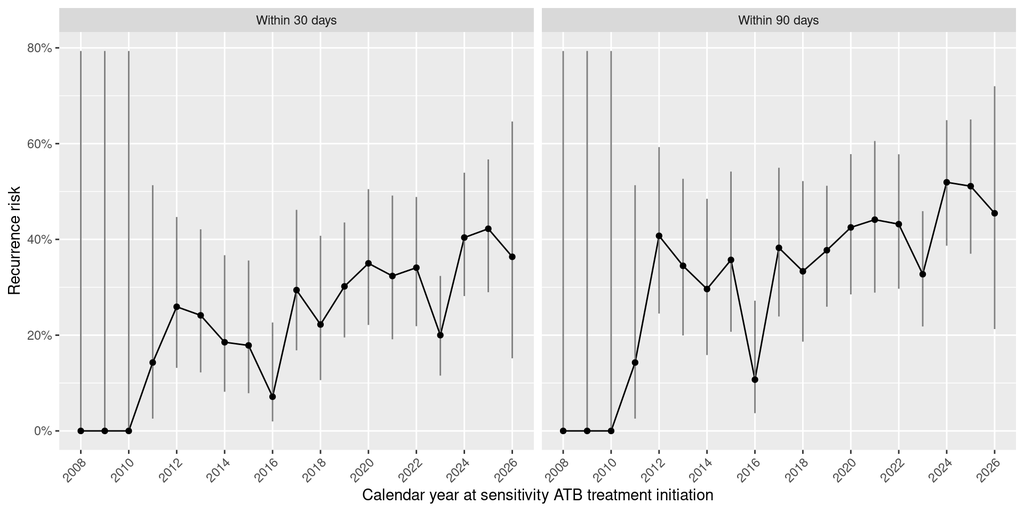

Figure 1. Observed recurrence within 30 and 90 days after therapy completion by calendar year of sensitivity ATB treatment initiation. Black points show observed proportions, grey vertical bars show 95% Wilson confidence intervals, and connecting lines guide the eye

```r
year_breaks <- seq(
  floor(min(year_risk$calendar_year) / 2) * 2,
  ceiling(max(year_risk$calendar_year) / 2) * 2,
  by = 2
)
myplot <- ggplot(year_risk, aes(calendar_year, risk)) +
  geom_line() +
  geom_linerange(aes(ymin = lower, ymax = upper), colour = "grey50") +
  geom_point() +
  facet_wrap(~ window) +
  scale_x_continuous(breaks = year_breaks, minor_breaks = NULL) +
  scale_y_continuous(labels = scales::label_percent()) +
  labs(
    x = "Calendar year at sensitivity ATB treatment initiation",
    y = "Recurrence risk"
  ) +
  theme(
    panel.grid.major.x = element_line(colour = "white"),
    axis.text.x = element_text(angle = 45, hjust = 1)
  )
plotac <- "fig_x01"
myplot <- save_plot(myplot, plotac, width = 10, height = 5)
myplot
```

## 3.2 Cohort description

Compare patient characteristics between the two treatment groups. Continuous variables are shown as median (interquartile range), and categorical variables as counts and percentages. Missing values are shown separately.

**Open code**

```r
cohort_table <- data_analysis |>
  dplyr::select(
    treatment_group,
    age,
    sex_female,
    TX_to_infection_months,
    urology_acute,
    stent_in_situ,
    bph_pca_subvesical_obstruction,
    urethral_stricture,
    renofunctional_obstruction,
    diabetes_severe,
    diabetes,
    mra_positive,
    bad_response_early_worsening,
    initial_agent_identified,
    hemoculture_positive,
    fever_signs,
    dysuria_UroInfSigns,
    profylaxis,
    severe_aki,
    CRP_entry,
    CRP_max,
    immunosuppression_regimen,
    depletion_induction_or_rejection_treatment_6M,
    calendar_period,
    ATB_sensitivity_duration,
    recurence_till_1M,
    recurence_till_90D
  ) |>
  data.frame() |>
  gtsummary::tbl_summary(
    by = treatment_group,
    label = list(
      age ~
        "Age, years",
      sex_female ~
        "Female sex",
      TX_to_infection_months ~
        "Time from transplantation to infection, months",
      urology_acute ~
        "Acute urological complications",
      stent_in_situ ~
        "Ureteral stent in situ",
      bph_pca_subvesical_obstruction ~
        "Subvesical obstruction",
      urethral_stricture ~
        "Urethral stricture",
      renofunctional_obstruction ~
        "Obstruction risk factors",
      diabetes_severe ~
        "Complicated diabetes mellitus",
      diabetes ~
        "Diabetes mellitus",
      mra_positive ~
        "Multidrug-resistant pathogen",
      bad_response_early_worsening ~
        "Unfavourable clinical response",
      initial_agent_identified ~
        "Culture-positive UTI",
      hemoculture_positive ~
        "Positive blood culture",
      fever_signs ~
        "Systemic infection symptoms",
      dysuria_UroInfSigns ~
        "Urinary tract infection symptoms",
      profylaxis ~
        "Antibiotic prophylaxis",
      severe_aki ~
        "Stage 2–3 AKI",
      CRP_entry ~
        "CRP at entry, mg/L",
      CRP_max ~
        "Maximum CRP, mg/L",
      immunosuppression_regimen ~
        "Immunosuppressive regimen",
      depletion_induction_or_rejection_treatment_6M ~
        "Depletion induction or rejection treatment within 6 months",
      calendar_period ~
        "Calendar period",
      ATB_sensitivity_duration ~
        "Duration of appropriate therapy, days",
      recurence_till_1M ~
        "Recurrence within 30 days",
      recurence_till_90D ~
        "Recurrence within 90 days"
    ),
    type = list(
      c(
        initial_agent_identified,
        hemoculture_positive,
        fever_signs,
        dysuria_UroInfSigns,
        recurence_till_1M,
        recurence_till_90D
      ) ~ "dichotomous"
    ),
    value = list(
      c(
        initial_agent_identified,
        hemoculture_positive,
        fever_signs,
        dysuria_UroInfSigns,
        recurence_till_1M,
        recurence_till_90D
      ) ~ 1
    ),
    statistic = list(
      gtsummary::all_continuous() ~ "{median} ({p25}, {p75})",
      gtsummary::all_categorical() ~ "{n} ({p}%)"
    ),
    missing = "ifany"
  ) |>
  gtsummary::bold_labels() |>
  gtsummary::modify_caption(
    "Patient characteristics by sensitivity ATB duration. Continuous variables are shown as median (interquartile range), and categorical variables as counts and within-group percentages among patients with available values. Binary variables show the number and percentage coded 1, indicating presence. Recurrence is measured within 30 and 90 days after therapy completion"
  )

cohort_table
```

Patient characteristics by sensitivity ATB duration. Continuous variables are shown as median (interquartile range), and categorical variables as counts and within-group percentages among patients with available values. Binary variables show the number and percentage coded 1, indicating presence. Recurrence is measured within 30 and 90 days after therapy completion

| **Characteristic** | **<=13 days** N = 244<sup>1</sup> | **>13 days** N = 300<sup>1</sup> |
| --- | --- | --- |
| Age, years | 63 (50, 70) | 59 (46, 67) |
| Female sex | 133 (55%) | 151 (50%) |
| Time from transplantation to infection, months | 10 (1, 63) | 14 (3, 72) |
| Acute urological complications | 40 (16%) | 66 (22%) |
| Ureteral stent in situ | 19 (7.8%) | 20 (6.7%) |
| Subvesical obstruction | 38 (16%) | 49 (16%) |
| Urethral stricture | 15 (6.1%) | 20 (6.7%) |
| Obstruction risk factors | 58 (24%) | 80 (27%) |
| Complicated diabetes mellitus | 47 (19%) | 59 (20%) |
| Diabetes mellitus | 88 (36%) | 90 (30%) |
| Multidrug-resistant pathogen | 103 (42%) | 82 (27%) |
| Unfavourable clinical response | 14 (5.7%) | 41 (14%) |
| Culture-positive UTI | 201 (82%) | 254 (85%) |
| Positive blood culture | 50 (20%) | 108 (36%) |
| Systemic infection symptoms | 175 (72%) | 253 (84%) |
| Urinary tract infection symptoms | 166 (68%) | 205 (68%) |
| Antibiotic prophylaxis | 139 (57%) | 159 (53%) |
| Stage 2–3 AKI | 33 (14%) | 80 (27%) |
| CRP at entry, mg/L | 110 (63, 178) | 176 (97, 263) |
| Maximum CRP, mg/L | 141 (93, 207) | 213 (141, 281) |
| Immunosuppressive regimen |  |  |
| standard triple | 191 (78%) | 233 (78%) |
| other triple | 15 (6.1%) | 22 (7.3%) |
| dual or single | 38 (16%) | 45 (15%) |
| Depletion induction or rejection treatment within 6 months | 65 (27%) | 65 (22%) |
| Calendar period |  |  |
| <=2016 | 47 (19%) | 102 (34%) |
| 2017-2021 | 78 (32%) | 110 (37%) |
| >=2022 | 119 (49%) | 88 (29%) |
| Duration of appropriate therapy, days | 10.0 (9.0, 13.0) | 17.0 (15.0, 20.0) |
| Recurrence within 30 days | 68 (28%) | 86 (29%) |
| Recurrence within 90 days | 99 (41%) | 110 (37%) |

<sup>1</sup> Median (Q1, Q3); n (%)

## 3.3 Correlations among continuous measures

Look for closely related measures before interpreting models that include them together. Spearman correlations describe rank relationships; the lower panels show the original observations.

**Open code**

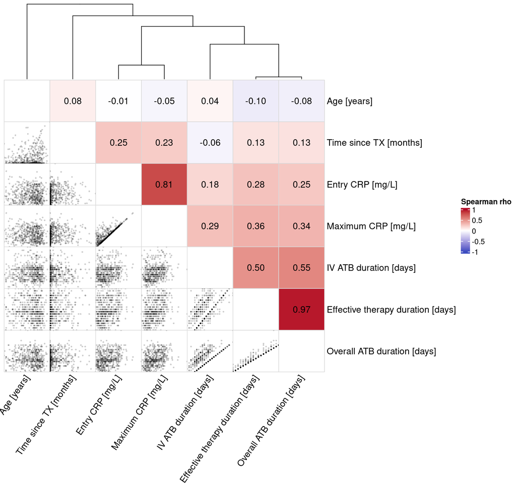

Figure 2. Pairwise Spearman correlations among age, admission and maximum CRP, time since transplantation, and sensitivity ATB, overall and intravenous antibiotic duration. Upper cells show Spearman rho; lower cells show individual observations. Variables are ordered by UPGMA hierarchical clustering using distance 1 minus rho and average linkage. Pairwise complete records are used; axes in lower cells use each variable’s observed range. Effective therapy duration denotes days of treatment with an antibiotic to which the isolated organism was susceptible in vitro. IV theraphy means intravenous antibiotic therapy. Overall duration includes all antibiotic treatment irrespective of in vitro susceptibility; IV denotes intravenous and TX transplantation

```r
correlation_data <- data_analysis |>
  dplyr::select(
    age,
    CRP_entry,
    CRP_max,
    TX_to_infection_months,
    ATB_sensitivity_duration,
    ATB_duration_overall,
    ATB_IV_duration
  ) |>
  data.frame()
correlation_labels <- c(
  "Age [years]", "Entry CRP [mg/L]", "Maximum CRP [mg/L]",
  "Time since TX [months]", "Effective therapy duration [days]",
  "Overall ATB duration [days]", "IV ATB duration [days]"
)
rho_matrix <- cor(
  correlation_data,
  method = "spearman",
  use = "pairwise.complete.obs"
)
correlation_upgma <- hclust(as.dist(1 - rho_matrix), method = "average")
correlation_order <- correlation_upgma$order
display_position <- integer(length(correlation_order))
display_position[correlation_order] <- seq_along(correlation_order)
rho_display <- rho_matrix
rho_display[!outer(display_position, display_position, "<")] <- NA_real_
myplot <- ComplexHeatmap::Heatmap(
  rho_display,
  name = "Spearman rho",
  col = circlize::colorRamp2(
    c(-1, 0, 1), c("#3B4CC0", "white", "#B40426")
  ),
  cluster_rows = FALSE,
  row_order = correlation_order,
  cluster_columns = as.dendrogram(correlation_upgma),
  column_dend_reorder = FALSE,
  show_row_dend = FALSE,
  row_labels = correlation_labels,
  column_labels = correlation_labels,
  column_names_rot = 55,
  column_dend_height = grid::unit(35, "mm"),
  na_col = "white",
  rect_gp = grid::gpar(col = "grey85"),
  cell_fun = function(j, i, x, y, width, height, fill) {
    if (display_position[i] < display_position[j]) {
      grid::grid.text(sprintf("%.2f", rho_matrix[i, j]), x, y)
    }
    if (display_position[i] > display_position[j]) {
      pairs <- correlation_data[, c(j, i)]
      pairs <- pairs[complete.cases(pairs), , drop = FALSE]
      grid::pushViewport(grid::viewport(
        x = x, y = y, width = width, height = height,
        xscale = range(pairs[[1]]), yscale = range(pairs[[2]]),
        clip = "on"
      ))
      grid::grid.rect(gp = grid::gpar(fill = "white", col = "grey85"))
      grid::grid.points(
        pairs[[1]], pairs[[2]], default.units = "native",
        pch = 16, size = grid::unit(1, "mm"),
        gp = grid::gpar(col = grDevices::rgb(0, 0, 0, alpha = 0.2))
      )
      grid::popViewport()
    }
  }
)
plotac <- "fig_x02"
assign(plotac, myplot)
figure_path <- file.path("gitignore/figures", paste0(plotac, ".pdf"))
if (!file.exists(figure_path)) {
  cairo_pdf(figure_path, width = 9.5, height = 9)
  ComplexHeatmap::draw(get(plotac))
  dev.off()
}
grid::grid.newpage()
ComplexHeatmap::draw(get(plotac))
```

# 4 Unadjusted regression

Fit each predictor separately

**Open code**

```r
unadjusted_table <- function(outcome, predictors, data) {
  purrr::map_dfr(predictors, function(predictor) {
    model <- glm(
      reformulate(predictor, response = outcome),
      data = data,
      family = binomial(link = "logit")
    )
    profile_or(model) |>
      dplyr::mutate(
        predictor = predictor,
        term = dplyr::coalesce(unname(my_labels_dict[term]), term),
        n = nobs(model),
        .before = 1
      )
  }) |>
    data.frame()
}

unadjusted_predictors <- c(
  "ATB_sensitivity_per7", "log2_ATB_sensitivity_duration",
  "ATB_overall_per7", "log2_ATB_duration_overall",
  "treatment_under14D", "sex_female", "age_by30y",
  "log2_TX_to_infection", "urology_acute", "diabetes_severe",
  "mra_positive", "bad_response_early_worsening", "hemoculture_positive",
  "profylaxis", "severe_aki", "log2(CRP_entry)", "log2(CRP_max)",
  "I(years_from2019 / 10)", "immunosuppression_regimen",
  "depletion_induction_or_rejection_treatment_6M", "any_problem_D1_13"
)
```

## 4.1 Recurrence within 30 days

Show the unadjusted associations

**Open code**

```r
unadjusted_30D <- unadjusted_table(
  "recurence_till_1M",
  unadjusted_predictors,
  data_analysis
)
## Waiting for profiling to be done...
## Waiting for profiling to be done...
## Waiting for profiling to be done...
## Waiting for profiling to be done...
## Waiting for profiling to be done...
## Waiting for profiling to be done...
## Waiting for profiling to be done...
## Waiting for profiling to be done...
## Waiting for profiling to be done...
## Waiting for profiling to be done...
## Waiting for profiling to be done...
## Waiting for profiling to be done...
## Waiting for profiling to be done...
## Waiting for profiling to be done...
## Waiting for profiling to be done...
## Waiting for profiling to be done...
## Waiting for profiling to be done...
## Waiting for profiling to be done...
## Waiting for profiling to be done...
## Waiting for profiling to be done...
## Waiting for profiling to be done...
kableExtra::kable(
  unadjusted_30D,
  digits = 3,
  caption = "Unadjusted associations with recurrence within 30 days after therapy completion. Each predictor was fitted separately using logistic regression. OR (odds ratio) states how many times the odds of recurrence change when a numerical predictor increases by one unit or a binary predictor changes from 0 to 1. For _per7 variables, the increase is seven treatment days; for log2-transformed variables, it is a doubling of the original value. For other categorical predictors, OR describes the change from the reference category to the category shown in the row. n is the number of patients analysed; lower and upper are the 95% profile-likelihood confidence limits"
)
```

Unadjusted associations with recurrence within 30 days after therapy completion. Each predictor was fitted separately using logistic regression. OR (odds ratio) states how many times the odds of recurrence change when a numerical predictor increases by one unit or a binary predictor changes from 0 to 1. For _per7 variables, the increase is seven treatment days; for log2-transformed variables, it is a doubling of the original value. For other categorical predictors, OR describes the change from the reference category to the category shown in the row. n is the number of patients analysed; lower and upper are the 95% profile-likelihood confidence limits

| predictor | n | term | OR | lower | upper |
| --- | --- | --- | --- | --- | --- |
| ATB_sensitivity_per7 | 544 | Duration of appropriate therapy, per additional week | 1.051 | 0.789 | 1.399 |
| log2_ATB_sensitivity_duration | 544 | Duration of appropriate therapy, per doubling | 1.110 | 0.758 | 1.637 |
| ATB_overall_per7 | 544 | Overall duration of therapy, per additional week | 1.026 | 0.777 | 1.352 |
| log2_ATB_duration_overall | 544 | Overall duration of therapy, per doubling | 1.077 | 0.734 | 1.588 |
| treatment_under14D | 544 | Appropriate therapy, <=13 vs. >13 days | 0.961 | 0.659 | 1.398 |
| sex_female | 544 | Female sex | 0.637 | 0.437 | 0.926 |
| age_by30y | 544 | Age, per 30 years | 0.985 | 0.665 | 1.471 |
| log2_TX_to_infection | 544 | Time from transplantation, per doubling | 0.843 | 0.788 | 0.901 |
| urology_acute | 544 | Acute urological complications | 2.116 | 1.355 | 3.290 |
| diabetes_severe | 544 | Complicated diabetes mellitus | 1.120 | 0.697 | 1.769 |
| mra_positive | 544 | Multidrug-resistant pathogen | 2.611 | 1.776 | 3.847 |
| bad_response_early_worsening | 544 | Unfavourable clinical response | 1.149 | 0.614 | 2.074 |
| hemoculture_positive | 544 | Positive blood culture | 2.239 | 1.506 | 3.327 |
| profylaxis | 544 | Antibiotic prophylaxis | 0.661 | 0.454 | 0.961 |
| severe_aki | 544 | Stage 2–3 AKI | 0.752 | 0.459 | 1.200 |
| log2(CRP_entry) | 544 | CRP at entry, per doubling | 0.924 | 0.802 | 1.066 |
| log2(CRP_max) | 544 | Maximum CRP, per doubling | 1.000 | 0.797 | 1.260 |
| I(years_from2019 / 10) | 544 | Calendar time, per decade | 2.160 | 1.360 | 3.479 |
| immunosuppression_regimen | 544 | Immunosuppression, other vs. standard triple | 0.522 | 0.206 | 1.154 |
| immunosuppression_regimen | 544 | Immunosuppression, dual or single vs. standard triple | 0.534 | 0.289 | 0.935 |
| depletion_induction_or_rejection_treatment_6M | 544 | Depletion induction or rejection treatment within 6 months | 2.039 | 1.342 | 3.088 |
| any_problem_D1_13 | 544 | Any recorded reason for extending therapy | 1.105 | 0.699 | 1.719 |

## 4.2 Recurrence within 90 days

Show the unadjusted associations.

**Open code**

```r
unadjusted_90D <- unadjusted_table(
  "recurence_till_90D",
  unadjusted_predictors,
  data_analysis
)
## Waiting for profiling to be done...
## Waiting for profiling to be done...
## Waiting for profiling to be done...
## Waiting for profiling to be done...
## Waiting for profiling to be done...
## Waiting for profiling to be done...
## Waiting for profiling to be done...
## Waiting for profiling to be done...
## Waiting for profiling to be done...
## Waiting for profiling to be done...
## Waiting for profiling to be done...
## Waiting for profiling to be done...
## Waiting for profiling to be done...
## Waiting for profiling to be done...
## Waiting for profiling to be done...
## Waiting for profiling to be done...
## Waiting for profiling to be done...
## Waiting for profiling to be done...
## Waiting for profiling to be done...
## Waiting for profiling to be done...
## Waiting for profiling to be done...
kableExtra::kable(
  unadjusted_90D,
  digits = 3,
  caption = "Unadjusted associations with recurrence within 90 days after therapy completion. Each predictor was fitted separately using logistic regression. OR (odds ratio) states how many times the odds of recurrence change when a numerical predictor increases by one unit or a binary predictor changes from 0 to 1. For _per7 variables, the increase is seven treatment days; for log2-transformed variables, it is a doubling of the original value. For other categorical predictors, OR describes the change from the reference category to the category shown in the row. n is the number of patients analysed; lower and upper are the 95% profile-likelihood confidence limits"
)
```

Unadjusted associations with recurrence within 90 days after therapy completion. Each predictor was fitted separately using logistic regression. OR (odds ratio) states how many times the odds of recurrence change when a numerical predictor increases by one unit or a binary predictor changes from 0 to 1. For _per7 variables, the increase is seven treatment days; for log2-transformed variables, it is a doubling of the original value. For other categorical predictors, OR describes the change from the reference category to the category shown in the row. n is the number of patients analysed; lower and upper are the 95% profile-likelihood confidence limits

| predictor | n | term | OR | lower | upper |
| --- | --- | --- | --- | --- | --- |
| ATB_sensitivity_per7 | 544 | Duration of appropriate therapy, per additional week | 0.859 | 0.657 | 1.120 |
| log2_ATB_sensitivity_duration | 544 | Duration of appropriate therapy, per doubling | 0.817 | 0.573 | 1.163 |
| ATB_overall_per7 | 544 | Overall duration of therapy, per additional week | 0.849 | 0.654 | 1.098 |
| log2_ATB_duration_overall | 544 | Overall duration of therapy, per doubling | 0.801 | 0.561 | 1.143 |
| treatment_under14D | 544 | Appropriate therapy, <=13 vs. >13 days | 1.179 | 0.833 | 1.669 |
| sex_female | 544 | Female sex | 0.685 | 0.484 | 0.969 |
| age_by30y | 544 | Age, per 30 years | 1.128 | 0.781 | 1.637 |
| log2_TX_to_infection | 544 | Time from transplantation, per doubling | 0.841 | 0.790 | 0.894 |
| urology_acute | 544 | Acute urological complications | 2.656 | 1.727 | 4.113 |
| diabetes_severe | 544 | Complicated diabetes mellitus | 1.293 | 0.839 | 1.986 |
| mra_positive | 544 | Multidrug-resistant pathogen | 3.715 | 2.566 | 5.412 |
| bad_response_early_worsening | 544 | Unfavourable clinical response | 1.171 | 0.658 | 2.054 |
| hemoculture_positive | 544 | Positive blood culture | 1.638 | 1.124 | 2.387 |
| profylaxis | 544 | Antibiotic prophylaxis | 0.896 | 0.634 | 1.269 |
| severe_aki | 544 | Stage 2–3 AKI | 0.630 | 0.399 | 0.976 |
| log2(CRP_entry) | 544 | CRP at entry, per doubling | 0.870 | 0.760 | 0.994 |
| log2(CRP_max) | 544 | Maximum CRP, per doubling | 0.817 | 0.661 | 1.009 |
| I(years_from2019 / 10) | 544 | Calendar time, per decade | 1.954 | 1.281 | 3.009 |
| immunosuppression_regimen | 544 | Immunosuppression, other vs. standard triple | 0.778 | 0.375 | 1.547 |
| immunosuppression_regimen | 544 | Immunosuppression, dual or single vs. standard triple | 0.518 | 0.301 | 0.863 |
| depletion_induction_or_rejection_treatment_6M | 544 | Depletion induction or rejection treatment within 6 months | 1.954 | 1.311 | 2.917 |
| any_problem_D1_13 | 544 | Any recorded reason for extending therapy | 1.202 | 0.790 | 1.820 |

# 5 Multivariable regression

## 5.1 30-day recurrence. Sensitivity ATB duration per additional seven days

Fit the model

**Open code**

```r
m_30D_effective_7d <- glm(
  recurence_till_1M ~
    ATB_sensitivity_per7 +
    sex_female +
    age_by30y +
    log2_TX_to_infection +
    urology_acute +
    diabetes_severe +
    mra_positive +
    bad_response_early_worsening +
    hemoculture_positive +
    profylaxis +
    severe_aki +
    I(years_from2019 / 10),
  data = data_analysis,
  family = binomial(link = "logit")
)
summary(m_30D_effective_7d)
##
## Call:
## glm(formula = recurence_till_1M ~ ATB_sensitivity_per7 + sex_female +
##     age_by30y + log2_TX_to_infection + urology_acute + diabetes_severe +
##     mra_positive + bad_response_early_worsening + hemoculture_positive +
##     profylaxis + severe_aki + I(years_from2019/10), family = binomial(link = "logit"),
##     data = data_analysis)
##
## Coefficients:
##                              Estimate Std. Error z value Pr(>|z|)
## (Intercept)                  -0.41195    0.62892  -0.655 0.512454
## ATB_sensitivity_per7          0.18059    0.18084   0.999 0.317976
## sex_female                   -0.36981    0.22436  -1.648 0.099299 .
## age_by30y                    -0.14442    0.23784  -0.607 0.543716
## log2_TX_to_infection         -0.17336    0.04138  -4.190 2.79e-05 ***
## urology_acute                 0.61055    0.26776   2.280 0.022593 *
## diabetes_severe              -0.18249    0.27138  -0.672 0.501288
## mra_positive                  0.89347    0.23637   3.780 0.000157 ***
## bad_response_early_worsening  0.10155    0.34964   0.290 0.771475
## hemoculture_positive          0.74586    0.23683   3.149 0.001636 **
## profylaxis                   -1.01132    0.23652  -4.276 1.90e-05 ***
## severe_aki                   -0.25189    0.28304  -0.890 0.373479
## I(years_from2019/10)          0.61422    0.27086   2.268 0.023348 *
## ---
## Signif. codes:  0 '***' 0.001 '**' 0.01 '*' 0.05 '.' 0.1 ' ' 1
##
## (Dispersion parameter for binomial family taken to be 1)
##
##     Null deviance: 648.28  on 543  degrees of freedom
## Residual deviance: 557.29  on 531  degrees of freedom
## AIC: 583.29
##
## Number of Fisher Scoring iterations: 4
car::vif(m_30D_effective_7d)
##         ATB_sensitivity_per7                   sex_female
##                     1.285919                     1.158614
##                    age_by30y         log2_TX_to_infection
##                     1.119471                     1.331757
##                urology_acute              diabetes_severe
##                     1.176844                     1.099542
##                 mra_positive bad_response_early_worsening
##                     1.255620                     1.047982
##         hemoculture_positive                   profylaxis
##                     1.173787                     1.289184
##                   severe_aki         I(years_from2019/10)
##                     1.121742                     1.151039

sjPlot::tab_model(
  m_30D_effective_7d,
  pred.labels = unname(
    my_labels_dict[names(coef(m_30D_effective_7d))]
  ),
  show.ci = 0.95,
  show.p = TRUE,
  show.se = FALSE,
  digits = 3,
  title = "30-day recurrence. Sensitivity ATB duration per additional seven days: adjusted odds ratios"
)
```

30-day recurrence. Sensitivity ATB duration per additional seven days: adjusted odds ratios

|  | recurence till 1 M |  |  |
| --- | --- | --- | --- |
| Predictors | Odds Ratios | CI | p |
| Intercept | 0.662 | 0.191 – 2.263 | 0.512 |
| Duration of appropriate therapy, per additional week | 1.198 | 0.840 – 1.710 | 0.318 |
| Female sex | 0.691 | 0.444 – 1.072 | 0.099 |
| Age, per 30 years | 0.866 | 0.544 – 1.384 | 0.544 |
| Time from transplantation, per doubling | 0.841 | 0.774 – 0.911 | **<0.001** |
| Acute urological complications | 1.841 | 1.088 – 3.115 | **0.023** |
| Complicated diabetes mellitus | 0.833 | 0.484 – 1.406 | 0.501 |
| Multidrug-resistant pathogen | 2.444 | 1.541 – 3.899 | **<0.001** |
| Unfavourable clinical response | 1.107 | 0.547 – 2.167 | 0.771 |
| Positive blood culture | 2.108 | 1.326 – 3.360 | **0.002** |
| Antibiotic prophylaxis | 0.364 | 0.227 – 0.574 | **<0.001** |
| Stage 2–3 AKI | 0.777 | 0.441 – 1.341 | 0.373 |
| Calendar time, per decade | 1.848 | 1.094 – 3.171 | **0.023** |
| Observations | 544 |  |  |
| R<sup>2</sup> Tjur | 0.160 |  |  |

Plot the model

**Open code**

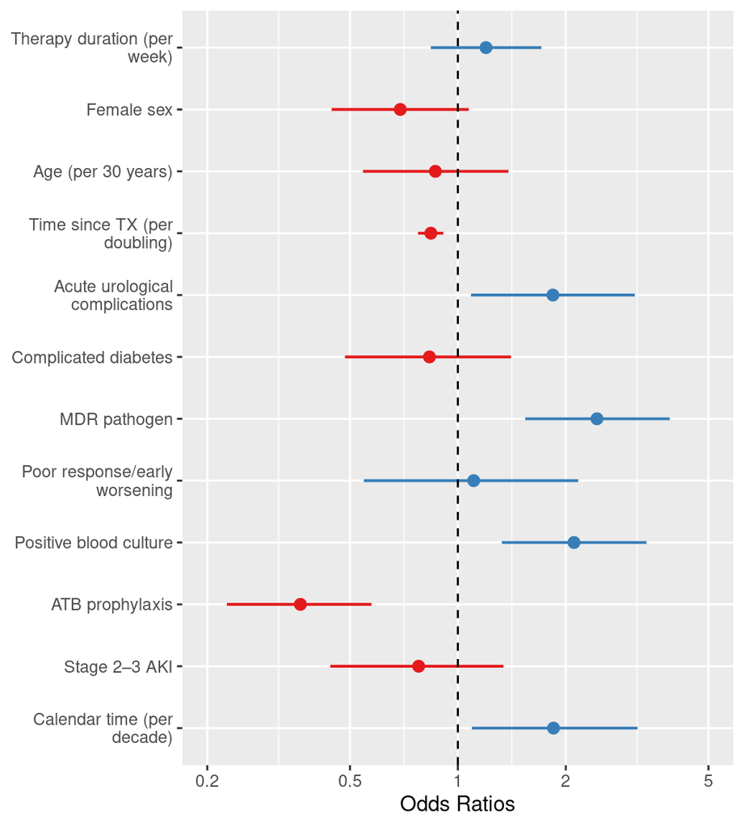

Figure 3. 30-day recurrence. Sensitivity ATB duration per additional seven days. Points show adjusted logistic-regression odds ratios and horizontal lines show 95% profile-likelihood confidence intervals. OR states how many times recurrence odds change when a numerical predictor increases by one modelled unit or a binary predictor changes from 0 to 1. For other categorical predictors, the change is from the reference category to the category shown. The dashed line marks OR = 1. Therapy duration denotes days of treatment with an antibiotic to which the isolated organism was susceptible in vitro. TX denotes transplantation, MDR multidrug resistance, ATB antibiotics and AKI acute kidney injury

```r
myplot <- plot_my_model(
  m_30D_effective_7d,
  axis.lim = c(0.5, 4)
  )

plotac <- "fig_x03"
myplot <- save_plot(myplot, plotac, width = 5.4, height = 6.0)
myplot
```

## 5.2 90-day recurrence. Sensitivity ATB duration per additional seven days

Fit the model

**Open code**

```r
m_90D_effective_7d <- glm(
  recurence_till_90D ~
    ATB_sensitivity_per7 +
    sex_female +
    age_by30y +
    log2_TX_to_infection +
    urology_acute +
    diabetes_severe +
    mra_positive +
    bad_response_early_worsening +
    hemoculture_positive +
    profylaxis +
    severe_aki +
    I(years_from2019 / 10),
  data = data_analysis,
  family = binomial(link = "logit")
)
summary(m_90D_effective_7d)
##
## Call:
## glm(formula = recurence_till_90D ~ ATB_sensitivity_per7 + sex_female +
##     age_by30y + log2_TX_to_infection + urology_acute + diabetes_severe +
##     mra_positive + bad_response_early_worsening + hemoculture_positive +
##     profylaxis + severe_aki + I(years_from2019/10), family = binomial(link = "logit"),
##     data = data_analysis)
##
## Coefficients:
##                              Estimate Std. Error z value Pr(>|z|)
## (Intercept)                  -0.19894    0.58208  -0.342 0.732520
## ATB_sensitivity_per7          0.03831    0.16691   0.230 0.818455
## sex_female                   -0.19099    0.20938  -0.912 0.361684
## age_by30y                    -0.07044    0.21937  -0.321 0.748148
## log2_TX_to_infection         -0.13047    0.03809  -3.426 0.000614 ***
## urology_acute                 0.86795    0.26136   3.321 0.000897 ***
## diabetes_severe              -0.06866    0.25268  -0.272 0.785824
## mra_positive                  1.21928    0.22389   5.446 5.15e-08 ***
## bad_response_early_worsening  0.18314    0.32714   0.560 0.575600
## hemoculture_positive          0.40576    0.22778   1.781 0.074852 .
## profylaxis                   -0.67595    0.21752  -3.108 0.001886 **
## severe_aki                   -0.32707    0.26039  -1.256 0.209093
## I(years_from2019/10)          0.60332    0.25157   2.398 0.016477 *
## ---
## Signif. codes:  0 '***' 0.001 '**' 0.01 '*' 0.05 '.' 0.1 ' ' 1
##
## (Dispersion parameter for binomial family taken to be 1)
##
##     Null deviance: 724.69  on 543  degrees of freedom
## Residual deviance: 623.26  on 531  degrees of freedom
## AIC: 649.26
##
## Number of Fisher Scoring iterations: 4
car::vif(m_90D_effective_7d)
##         ATB_sensitivity_per7                   sex_female
##                     1.269050                     1.159387
##                    age_by30y         log2_TX_to_infection
##                     1.114317                     1.300891
##                urology_acute              diabetes_severe
##                     1.178948                     1.083369
##                 mra_positive bad_response_early_worsening
##                     1.252000                     1.049870
##         hemoculture_positive                   profylaxis
##                     1.168228                     1.244713
##                   severe_aki         I(years_from2019/10)
##                     1.102530                     1.152067

sjPlot::tab_model(
  m_90D_effective_7d,
  pred.labels = unname(
    my_labels_dict[names(coef(m_90D_effective_7d))]
  ),
  show.ci = 0.95,
  show.p = TRUE,
  show.se = FALSE,
  digits = 3,
  title = "90-day recurrence. Sensitivity ATB duration per additional seven days: adjusted odds ratios"
)
```

90-day recurrence. Sensitivity ATB duration per additional seven days: adjusted odds ratios

|  | recurence till 90 D |  |  |
| --- | --- | --- | --- |
| Predictors | Odds Ratios | CI | p |
| Intercept | 0.820 | 0.261 – 2.562 | 0.733 |
| Duration of appropriate therapy, per additional week | 1.039 | 0.749 – 1.443 | 0.818 |
| Female sex | 0.826 | 0.548 – 1.246 | 0.362 |
| Age, per 30 years | 0.932 | 0.606 – 1.434 | 0.748 |
| Time from transplantation, per doubling | 0.878 | 0.814 – 0.945 | **0.001** |
| Acute urological complications | 2.382 | 1.432 – 3.999 | **0.001** |
| Complicated diabetes mellitus | 0.934 | 0.566 – 1.527 | 0.786 |
| Multidrug-resistant pathogen | 3.385 | 2.191 – 5.278 | **<0.001** |
| Unfavourable clinical response | 1.201 | 0.627 – 2.270 | 0.576 |
| Positive blood culture | 1.500 | 0.960 – 2.347 | 0.075 |
| Antibiotic prophylaxis | 0.509 | 0.330 – 0.775 | **0.002** |
| Stage 2–3 AKI | 0.721 | 0.429 – 1.194 | 0.209 |
| Calendar time, per decade | 1.828 | 1.122 – 3.012 | **0.016** |
| Observations | 544 |  |  |
| R<sup>2</sup> Tjur | 0.176 |  |  |

Plot the model

**Open code**

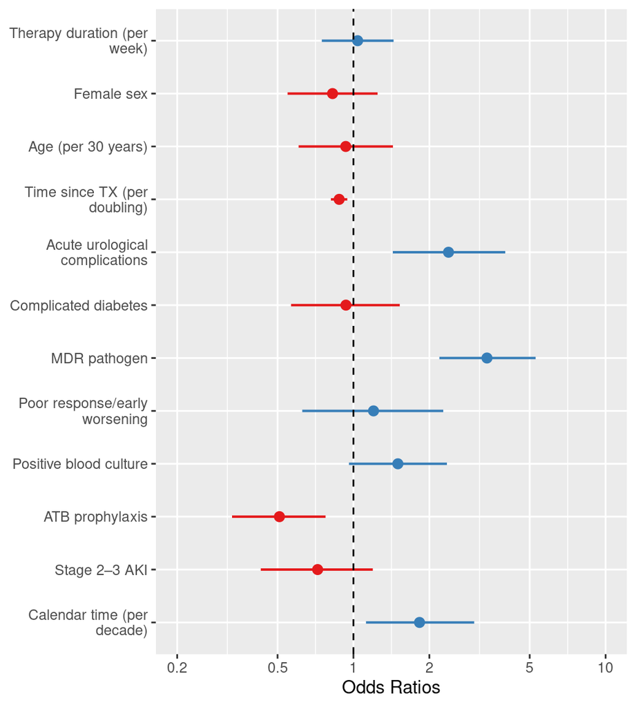

Figure 4. 90-day recurrence. Sensitivity ATB duration per additional seven days. Points show adjusted logistic-regression odds ratios and horizontal lines show 95% profile-likelihood confidence intervals. OR states how many times recurrence odds change when a numerical predictor increases by one modelled unit or a binary predictor changes from 0 to 1. For other categorical predictors, the change is from the reference category to the category shown. The dashed line marks OR = 1. Therapy duration denotes days of treatment with an antibiotic to which the isolated organism was susceptible in vitro. TX denotes transplantation, MDR multidrug resistance, ATB antibiotics and AKI acute kidney injury

```r
myplot <- plot_my_model(
  m_90D_effective_7d,
  axis.lim = c(0.49, 5)
  )

plotac <- "fig_x04"
myplot <- save_plot(myplot, plotac, width = 5.4, height = 6.0)
myplot
```

## 5.3 30-day recurrence. Sensitivity ATB duration per doubling

Fit the model

**Open code**

```r
m_30D_effective_log2 <- glm(
  recurence_till_1M ~
    log2_ATB_sensitivity_duration +
    sex_female +
    age_by30y +
    log2_TX_to_infection +
    urology_acute +
    diabetes_severe +
    mra_positive +
    bad_response_early_worsening +
    hemoculture_positive +
    profylaxis +
    severe_aki +
    I(years_from2019 / 10),
  data = data_analysis,
  family = binomial(link = "logit")
)
summary(m_30D_effective_log2)
##
## Call:
## glm(formula = recurence_till_1M ~ log2_ATB_sensitivity_duration +
##     sex_female + age_by30y + log2_TX_to_infection + urology_acute +
##     diabetes_severe + mra_positive + bad_response_early_worsening +
##     hemoculture_positive + profylaxis + severe_aki + I(years_from2019/10),
##     family = binomial(link = "logit"), data = data_analysis)
##
## Coefficients:
##                               Estimate Std. Error z value Pr(>|z|)
## (Intercept)                   -1.05584    1.04839  -1.007 0.313887
## log2_ATB_sensitivity_duration  0.26788    0.24297   1.103 0.270218
## sex_female                    -0.36788    0.22440  -1.639 0.101131
## age_by30y                     -0.14206    0.23813  -0.597 0.550792
## log2_TX_to_infection          -0.17340    0.04140  -4.189 2.80e-05 ***
## urology_acute                  0.60693    0.26801   2.265 0.023541 *
## diabetes_severe               -0.18283    0.27146  -0.673 0.500632
## mra_positive                   0.89769    0.23663   3.794 0.000148 ***
## bad_response_early_worsening   0.09978    0.34852   0.286 0.774640
## hemoculture_positive           0.73635    0.23728   3.103 0.001914 **
## profylaxis                    -1.00628    0.23660  -4.253 2.11e-05 ***
## severe_aki                    -0.25146    0.28255  -0.890 0.373481
## I(years_from2019/10)           0.62054    0.27072   2.292 0.021896 *
## ---
## Signif. codes:  0 '***' 0.001 '**' 0.01 '*' 0.05 '.' 0.1 ' ' 1
##
## (Dispersion parameter for binomial family taken to be 1)
##
##     Null deviance: 648.28  on 543  degrees of freedom
## Residual deviance: 557.06  on 531  degrees of freedom
## AIC: 583.06
##
## Number of Fisher Scoring iterations: 4
car::vif(m_30D_effective_log2)
## log2_ATB_sensitivity_duration                    sex_female
##                      1.275860                      1.158303
##                     age_by30y          log2_TX_to_infection
##                      1.119990                      1.330257
##                 urology_acute               diabetes_severe
##                      1.177537                      1.099150
##                  mra_positive  bad_response_early_worsening
##                      1.257219                      1.041734
##          hemoculture_positive                    profylaxis
##                      1.177477                      1.289208
##                    severe_aki          I(years_from2019/10)
##                      1.117144                      1.147563

sjPlot::tab_model(
  m_30D_effective_log2,
  pred.labels = unname(
    my_labels_dict[names(coef(m_30D_effective_log2))]
  ),
  show.ci = 0.95,
  show.p = TRUE,
  show.se = FALSE,
  digits = 3,
  title = "30-day recurrence. Sensitivity ATB duration per doubling: adjusted odds ratios"
)
```

30-day recurrence. Sensitivity ATB duration per doubling: adjusted odds ratios

|  | recurence till 1 M |  |  |
| --- | --- | --- | --- |
| Predictors | Odds Ratios | CI | p |
| Intercept | 0.348 | 0.043 – 2.669 | 0.314 |
| Duration of appropriate therapy, per doubling | 1.307 | 0.815 – 2.118 | 0.270 |
| Female sex | 0.692 | 0.445 – 1.075 | 0.101 |
| Age, per 30 years | 0.868 | 0.545 – 1.388 | 0.551 |
| Time from transplantation, per doubling | 0.841 | 0.774 – 0.911 | **<0.001** |
| Acute urological complications | 1.835 | 1.083 – 3.105 | **0.024** |
| Complicated diabetes mellitus | 0.833 | 0.484 – 1.406 | 0.501 |
| Multidrug-resistant pathogen | 2.454 | 1.547 – 3.918 | **<0.001** |
| Unfavourable clinical response | 1.105 | 0.547 – 2.158 | 0.775 |
| Positive blood culture | 2.088 | 1.312 – 3.332 | **0.002** |
| Antibiotic prophylaxis | 0.366 | 0.228 – 0.577 | **<0.001** |
| Stage 2–3 AKI | 0.778 | 0.441 – 1.340 | 0.373 |
| Calendar time, per decade | 1.860 | 1.102 – 3.190 | **0.022** |
| Observations | 544 |  |  |
| R<sup>2</sup> Tjur | 0.161 |  |  |

Plot the model

**Open code**

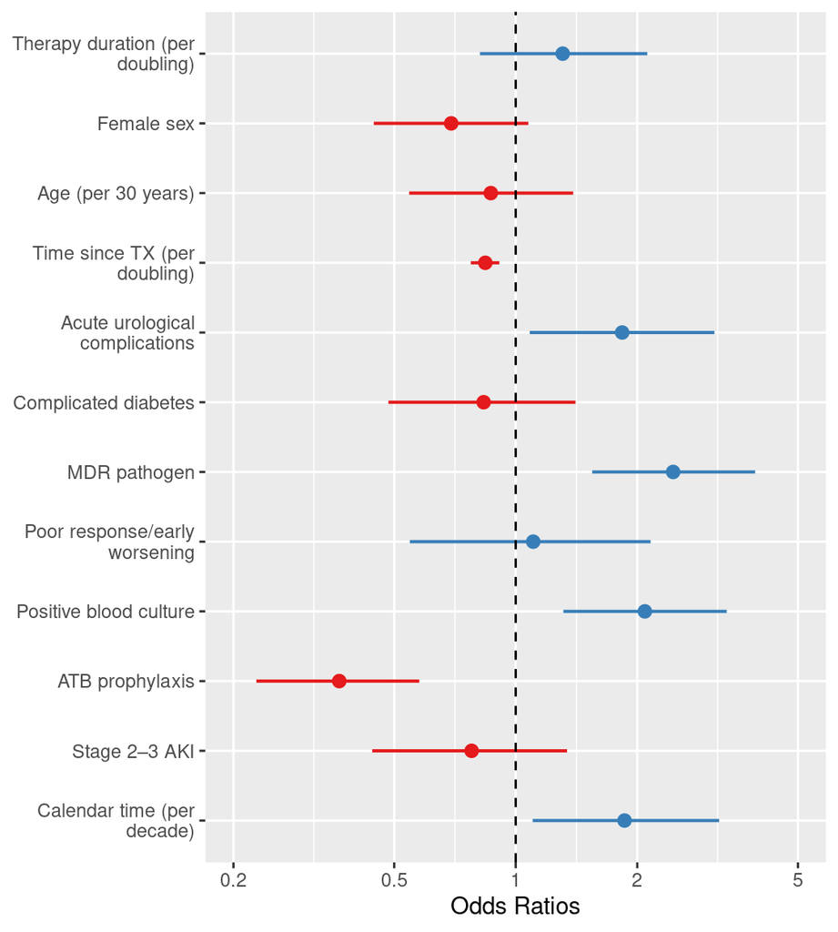

Figure 5. 30-day recurrence. Sensitivity ATB duration per doubling. Points show adjusted logistic-regression odds ratios and horizontal lines show 95% profile-likelihood confidence intervals. OR states how many times recurrence odds change when a numerical predictor increases by one modelled unit or a binary predictor changes from 0 to 1. For other categorical predictors, the change is from the reference category to the category shown. The dashed line marks OR = 1. Therapy duration denotes days of treatment with an antibiotic to which the isolated organism was susceptible in vitro. TX denotes transplantation, MDR multidrug resistance, ATB antibiotics and AKI acute kidney injury

```r
myplot <- plot_my_model(
  m_30D_effective_log2,
  axis.lim = c(0.49, 4)
  )


plotac <- "fig_x05"
myplot <- save_plot(myplot, plotac, width = 5.4, height = 6.0)
myplot
```

## 5.4 90-day recurrence. Sensitivity ATB duration per doubling

Fit the model

**Open code**

```r
m_90D_effective_log2 <- glm(
  recurence_till_90D ~
    log2_ATB_sensitivity_duration +
    sex_female +
    age_by30y +
    log2_TX_to_infection +
    urology_acute +
    diabetes_severe +
    mra_positive +
    bad_response_early_worsening +
    hemoculture_positive +
    profylaxis +
    severe_aki +
    I(years_from2019 / 10),
  data = data_analysis,
  family = binomial(link = "logit")
)
summary(m_90D_effective_log2)
##
## Call:
## glm(formula = recurence_till_90D ~ log2_ATB_sensitivity_duration +
##     sex_female + age_by30y + log2_TX_to_infection + urology_acute +
##     diabetes_severe + mra_positive + bad_response_early_worsening +
##     hemoculture_positive + profylaxis + severe_aki + I(years_from2019/10),
##     family = binomial(link = "logit"), data = data_analysis)
##
## Coefficients:
##                               Estimate Std. Error z value Pr(>|z|)
## (Intercept)                   -0.25648    0.95306  -0.269 0.787847
## log2_ATB_sensitivity_duration  0.03585    0.22012   0.163 0.870622
## sex_female                    -0.19059    0.20938  -0.910 0.362684
## age_by30y                     -0.07114    0.21938  -0.324 0.745712
## log2_TX_to_infection          -0.13033    0.03808  -3.422 0.000621 ***
## urology_acute                  0.86899    0.26141   3.324 0.000887 ***
## diabetes_severe               -0.06933    0.25268  -0.274 0.783803
## mra_positive                   1.21722    0.22395   5.435 5.48e-08 ***
## bad_response_early_worsening   0.18820    0.32621   0.577 0.563999
## hemoculture_positive           0.41001    0.22805   1.798 0.072194 .
## profylaxis                    -0.67595    0.21762  -3.106 0.001896 **
## severe_aki                    -0.32431    0.25993  -1.248 0.212154
## I(years_from2019/10)           0.59838    0.25069   2.387 0.016989 *
## ---
## Signif. codes:  0 '***' 0.001 '**' 0.01 '*' 0.05 '.' 0.1 ' ' 1
##
## (Dispersion parameter for binomial family taken to be 1)
##
##     Null deviance: 724.69  on 543  degrees of freedom
## Residual deviance: 623.29  on 531  degrees of freedom
## AIC: 649.29
##
## Number of Fisher Scoring iterations: 4
car::vif(m_90D_effective_log2)
## log2_ATB_sensitivity_duration                    sex_female
##                      1.255501                      1.159405
##                     age_by30y          log2_TX_to_infection
##                      1.114578                      1.300724
##                 urology_acute               diabetes_severe
##                      1.179232                      1.083128
##                  mra_positive  bad_response_early_worsening
##                      1.252813                      1.044099
##          hemoculture_positive                    profylaxis
##                      1.170827                      1.246013
##                    severe_aki          I(years_from2019/10)
##                      1.098724                      1.144317

sjPlot::tab_model(
  m_90D_effective_log2,
  pred.labels = unname(
    my_labels_dict[names(coef(m_90D_effective_log2))]
  ),
  show.ci = 0.95,
  show.p = TRUE,
  show.se = FALSE,
  digits = 3,
  title = "90-day recurrence. Sensitivity ATB duration per doubling: adjusted odds ratios"
)
```

90-day recurrence. Sensitivity ATB duration per doubling: adjusted odds ratios

|  | recurence till 90 D |  |  |
| --- | --- | --- | --- |
| Predictors | Odds Ratios | CI | p |
| Intercept | 0.774 | 0.118 – 4.983 | 0.788 |
| Duration of appropriate therapy, per doubling | 1.037 | 0.674 – 1.601 | 0.871 |
| Female sex | 0.826 | 0.548 – 1.247 | 0.363 |
| Age, per 30 years | 0.931 | 0.606 – 1.434 | 0.746 |
| Time from transplantation, per doubling | 0.878 | 0.814 – 0.945 | **0.001** |
| Acute urological complications | 2.385 | 1.434 – 4.003 | **0.001** |
| Complicated diabetes mellitus | 0.933 | 0.565 – 1.526 | 0.784 |
| Multidrug-resistant pathogen | 3.378 | 2.187 – 5.268 | **<0.001** |
| Unfavourable clinical response | 1.207 | 0.631 – 2.278 | 0.564 |
| Positive blood culture | 1.507 | 0.963 – 2.359 | 0.072 |
| Antibiotic prophylaxis | 0.509 | 0.330 – 0.775 | **0.002** |
| Stage 2–3 AKI | 0.723 | 0.431 – 1.196 | 0.212 |
| Calendar time, per decade | 1.819 | 1.118 – 2.992 | **0.017** |
| Observations | 544 |  |  |
| R<sup>2</sup> Tjur | 0.176 |  |  |

Plot the model

**Open code**

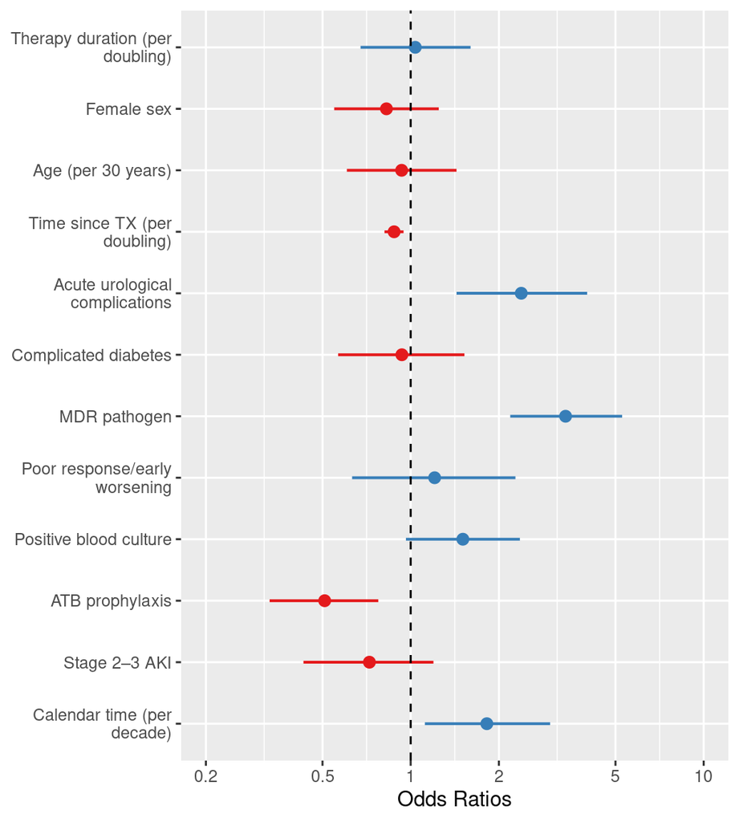

Figure 6. 90-day recurrence. Sensitivity ATB duration per doubling. Points show adjusted logistic-regression odds ratios and horizontal lines show 95% profile-likelihood confidence intervals. OR states how many times recurrence odds change when a numerical predictor increases by one modelled unit or a binary predictor changes from 0 to 1. For other categorical predictors, the change is from the reference category to the category shown. The dashed line marks OR = 1. Therapy duration denotes days of treatment with an antibiotic to which the isolated organism was susceptible in vitro. TX denotes transplantation, MDR multidrug resistance, ATB antibiotics and AKI acute kidney injury

```r
myplot <- plot_my_model(
  m_90D_effective_log2,
  axis.lim = c(0.49, 5.2))


plotac <- "fig_x06"
myplot <- save_plot(myplot, plotac, width = 5.4, height = 6.0)
myplot
```

## 5.5 30-day recurrence. Sensitivity ATB duration: <=13 versus >13 days

Fit the model

**Open code**

```r
m_30D_effective_short <- glm(
  recurence_till_1M ~
    treatment_under14D +
    sex_female +
    age_by30y +
    log2_TX_to_infection +
    urology_acute +
    diabetes_severe +
    mra_positive +
    bad_response_early_worsening +
    hemoculture_positive +
    profylaxis +
    severe_aki +
    I(years_from2019 / 10),
  data = data_analysis,
  family = binomial(link = "logit")
)
summary(m_30D_effective_short)
##
## Call:
## glm(formula = recurence_till_1M ~ treatment_under14D + sex_female +
##     age_by30y + log2_TX_to_infection + urology_acute + diabetes_severe +
##     mra_positive + bad_response_early_worsening + hemoculture_positive +
##     profylaxis + severe_aki + I(years_from2019/10), family = binomial(link = "logit"),
##     data = data_analysis)
##
## Coefficients:
##                              Estimate Std. Error z value Pr(>|z|)
## (Intercept)                  -0.01085    0.51559  -0.021 0.983211
## treatment_under14D           -0.14193    0.23129  -0.614 0.539460
## sex_female                   -0.36677    0.22413  -1.636 0.101757
## age_by30y                    -0.13922    0.23865  -0.583 0.559652
## log2_TX_to_infection         -0.17060    0.04131  -4.130 3.62e-05 ***
## urology_acute                 0.60609    0.26949   2.249 0.024511 *
## diabetes_severe              -0.19519    0.27127  -0.720 0.471817
## mra_positive                  0.88675    0.23772   3.730 0.000191 ***
## bad_response_early_worsening  0.13718    0.34711   0.395 0.692697
## hemoculture_positive          0.78374    0.23223   3.375 0.000738 ***
## profylaxis                   -1.01173    0.23685  -4.272 1.94e-05 ***
## severe_aki                   -0.23217    0.28182  -0.824 0.410031
## I(years_from2019/10)          0.58541    0.26958   2.172 0.029890 *
## ---
## Signif. codes:  0 '***' 0.001 '**' 0.01 '*' 0.05 '.' 0.1 ' ' 1
##
## (Dispersion parameter for binomial family taken to be 1)
##
##     Null deviance: 648.28  on 543  degrees of freedom
## Residual deviance: 557.91  on 531  degrees of freedom
## AIC: 583.91
##
## Number of Fisher Scoring iterations: 4
car::vif(m_30D_effective_short)
##           treatment_under14D                   sex_female
##                     1.224188                     1.157725
##                    age_by30y         log2_TX_to_infection
##                     1.130401                     1.332119
##                urology_acute              diabetes_severe
##                     1.192552                     1.098405
##                 mra_positive bad_response_early_worsening
##                     1.272059                     1.032221
##         hemoculture_positive                   profylaxis
##                     1.128598                     1.294562
##                   severe_aki         I(years_from2019/10)
##                     1.113309                     1.146087

sjPlot::tab_model(
  m_30D_effective_short,
  pred.labels = unname(
    my_labels_dict[names(coef(m_30D_effective_short))]
  ),
  show.ci = 0.95,
  show.p = TRUE,
  show.se = FALSE,
  digits = 3,
  title = "30-day recurrence. Sensitivity ATB duration: <=13 versus >13 days: adjusted odds ratios"
)
```

30-day recurrence. Sensitivity ATB duration: <=13 versus >13 days: adjusted odds ratios

|  | recurence till 1 M |  |  |
| --- | --- | --- | --- |
| Predictors | Odds Ratios | CI | p |
| Intercept | 0.989 | 0.358 – 2.716 | 0.983 |
| Appropriate therapy, <=13 vs. >13 days | 0.868 | 0.550 – 1.364 | 0.539 |
| Female sex | 0.693 | 0.446 – 1.075 | 0.102 |
| Age, per 30 years | 0.870 | 0.546 – 1.393 | 0.560 |
| Time from transplantation, per doubling | 0.843 | 0.777 – 0.913 | **<0.001** |
| Acute urological complications | 1.833 | 1.079 – 3.112 | **0.025** |
| Complicated diabetes mellitus | 0.823 | 0.478 – 1.388 | 0.472 |
| Multidrug-resistant pathogen | 2.427 | 1.527 – 3.884 | **<0.001** |
| Unfavourable clinical response | 1.147 | 0.569 – 2.233 | 0.693 |
| Positive blood culture | 2.190 | 1.390 – 3.459 | **0.001** |
| Antibiotic prophylaxis | 0.364 | 0.227 – 0.574 | **<0.001** |
| Stage 2–3 AKI | 0.793 | 0.450 – 1.364 | 0.410 |
| Calendar time, per decade | 1.796 | 1.065 – 3.070 | **0.030** |
| Observations | 544 |  |  |
| R<sup>2</sup> Tjur | 0.159 |  |  |

Plot the model

**Open code**

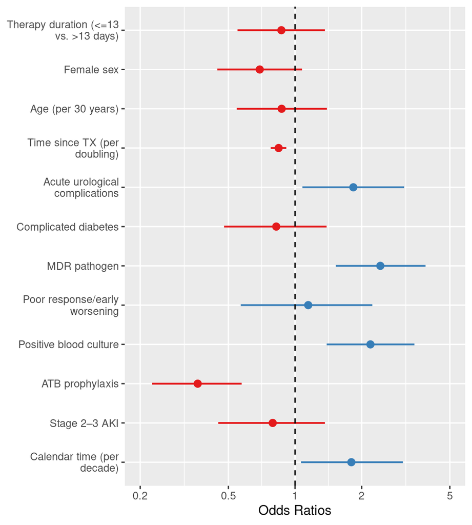

Figure 7. 30-day recurrence. Sensitivity ATB duration: <=13 versus >13 days. Points show adjusted logistic-regression odds ratios and horizontal lines show 95% profile-likelihood confidence intervals. OR states how many times recurrence odds change when a numerical predictor increases by one modelled unit or a binary predictor changes from 0 to 1. For other categorical predictors, the change is from the reference category to the category shown. The dashed line marks OR = 1. Therapy duration denotes days of treatment with an antibiotic to which the isolated organism was susceptible in vitro. TX denotes transplantation, MDR multidrug resistance, ATB antibiotics and AKI acute kidney injury

```r
myplot <- plot_my_model(
  m_30D_effective_short,
  axis.lim = c(0.49, 4.9)
  )


plotac <- "fig_x07"
myplot <- save_plot(myplot, plotac, width = 5.4, height = 6.0)
myplot
```

## 5.6 90-day recurrence. Sensitivity ATB duration: <=13 versus >13 days

Fit the model

**Open code**

```r
m_90D_effective_short <- glm(
  recurence_till_90D ~
    treatment_under14D +
    sex_female +
    age_by30y +
    log2_TX_to_infection +
    urology_acute +
    diabetes_severe +
    mra_positive +
    bad_response_early_worsening +
    hemoculture_positive +
    profylaxis +
    severe_aki +
    I(years_from2019 / 10),
  data = data_analysis,
  family = binomial(link = "logit")
)
summary(m_90D_effective_short)
##
## Call:
## glm(formula = recurence_till_90D ~ treatment_under14D + sex_female +
##     age_by30y + log2_TX_to_infection + urology_acute + diabetes_severe +
##     mra_positive + bad_response_early_worsening + hemoculture_positive +
##     profylaxis + severe_aki + I(years_from2019/10), family = binomial(link = "logit"),
##     data = data_analysis)
##
## Coefficients:
##                              Estimate Std. Error z value Pr(>|z|)
## (Intercept)                  -0.11233    0.47919  -0.234 0.814662
## treatment_under14D           -0.03547    0.21442  -0.165 0.868610
## sex_female                   -0.19026    0.20936  -0.909 0.363468
## age_by30y                    -0.06903    0.22042  -0.313 0.754139
## log2_TX_to_infection         -0.12988    0.03805  -3.413 0.000643 ***
## urology_acute                 0.86631    0.26287   3.296 0.000982 ***
## diabetes_severe              -0.07126    0.25265  -0.282 0.777918
## mra_positive                  1.21858    0.22527   5.409 6.32e-08 ***
## bad_response_early_worsening  0.19007    0.32432   0.586 0.557841
## hemoculture_positive          0.41337    0.22276   1.856 0.063492 .
## profylaxis                   -0.67552    0.21773  -3.103 0.001918 **
## severe_aki                   -0.32398    0.25967  -1.248 0.212156
## I(years_from2019/10)          0.59894    0.25128   2.384 0.017147 *
## ---
## Signif. codes:  0 '***' 0.001 '**' 0.01 '*' 0.05 '.' 0.1 ' ' 1
##
## (Dispersion parameter for binomial family taken to be 1)
##
##     Null deviance: 724.69  on 543  degrees of freedom
## Residual deviance: 623.29  on 531  degrees of freedom
## AIC: 649.29
##
## Number of Fisher Scoring iterations: 4
car::vif(m_90D_effective_short)
##           treatment_under14D                   sex_female
##                     1.209709                     1.159223
##                    age_by30y         log2_TX_to_infection
##                     1.125305                     1.299268
##                urology_acute              diabetes_severe
##                     1.192405                     1.082877
##                 mra_positive bad_response_early_worsening
##                     1.267680                     1.031305
##         hemoculture_positive                   profylaxis
##                     1.116862                     1.247260
##                   severe_aki         I(years_from2019/10)
##                     1.096590                     1.149753

sjPlot::tab_model(
  m_90D_effective_short,
  pred.labels = unname(
    my_labels_dict[names(coef(m_90D_effective_short))]
  ),
  show.ci = 0.95,
  show.p = TRUE,
  show.se = FALSE,
  digits = 3,
  title = "90-day recurrence. Sensitivity ATB duration: <=13 versus >13 days: adjusted odds ratios"
)
```

90-day recurrence. Sensitivity ATB duration: <=13 versus >13 days: adjusted odds ratios

|  | recurence till 90 D |  |  |
| --- | --- | --- | --- |
| Predictors | Odds Ratios | CI | p |
| Intercept | 0.894 | 0.348 – 2.286 | 0.815 |
| Appropriate therapy, <=13 vs. >13 days | 0.965 | 0.633 – 1.468 | 0.869 |
| Female sex | 0.827 | 0.548 – 1.247 | 0.363 |
| Age, per 30 years | 0.933 | 0.606 – 1.440 | 0.754 |
| Time from transplantation, per doubling | 0.878 | 0.815 – 0.946 | **0.001** |
| Acute urological complications | 2.378 | 1.426 – 4.004 | **0.001** |
| Complicated diabetes mellitus | 0.931 | 0.564 – 1.523 | 0.778 |
| Multidrug-resistant pathogen | 3.382 | 2.184 – 5.290 | **<0.001** |
| Unfavourable clinical response | 1.209 | 0.634 – 2.273 | 0.558 |
| Positive blood culture | 1.512 | 0.977 – 2.342 | 0.063 |
| Antibiotic prophylaxis | 0.509 | 0.330 – 0.776 | **0.002** |
| Stage 2–3 AKI | 0.723 | 0.431 – 1.196 | 0.212 |
| Calendar time, per decade | 1.820 | 1.117 – 2.996 | **0.017** |
| Observations | 544 |  |  |
| R<sup>2</sup> Tjur | 0.176 |  |  |

Plot the model

**Open code**

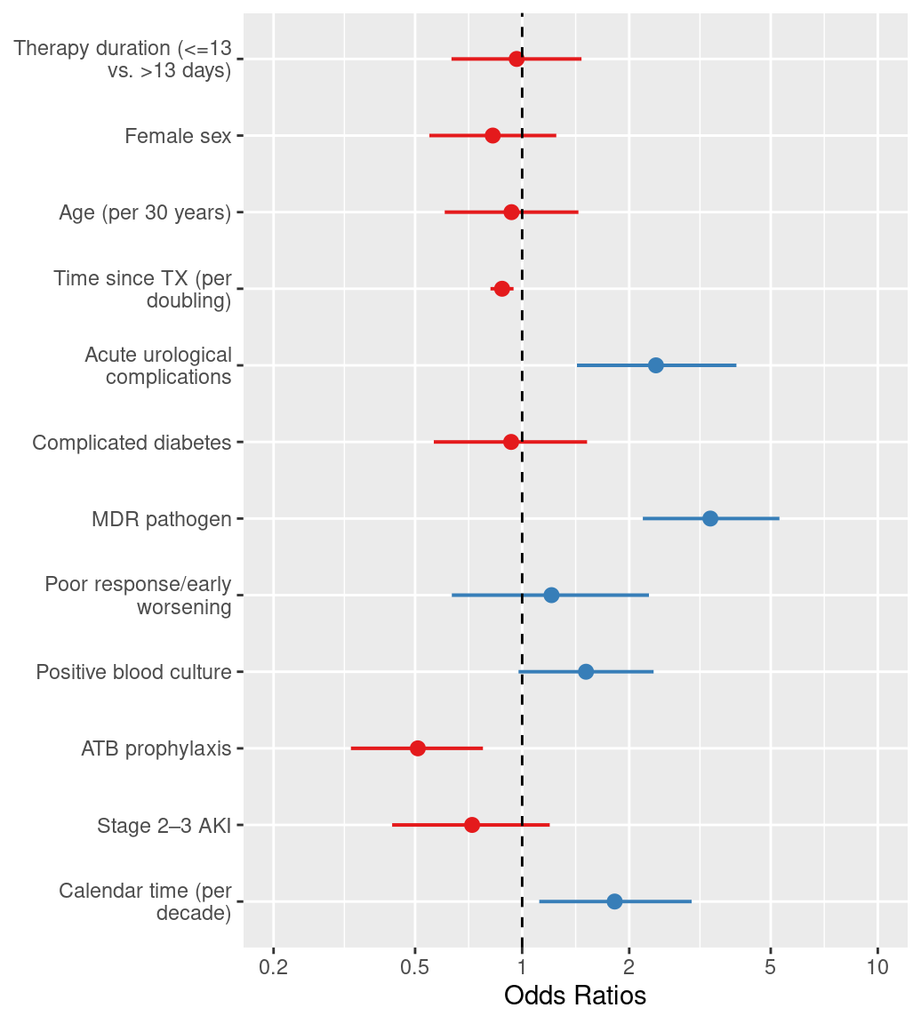

Figure 8. 90-day recurrence. Sensitivity ATB duration: <=13 versus >13 days. Points show adjusted logistic-regression odds ratios and horizontal lines show 95% profile-likelihood confidence intervals. OR states how many times recurrence odds change when a numerical predictor increases by one modelled unit or a binary predictor changes from 0 to 1. For other categorical predictors, the change is from the reference category to the category shown. The dashed line marks OR = 1. Therapy duration denotes days of treatment with an antibiotic to which the isolated organism was susceptible in vitro. TX denotes transplantation, MDR multidrug resistance, ATB antibiotics and AKI acute kidney injury

```r
myplot <- plot_my_model(
  m_90D_effective_short,
  axis.lim = c(0.44, 5)
  )


plotac <- "fig_x08"
myplot <- save_plot(myplot, plotac, width = 5.4, height = 6.0)
myplot
```

## 5.7 30-day recurrence. Overall duration per seven days

Fit the model

**Open code**

```r
m_30D_overall_7d <- glm(
  recurence_till_1M ~
    ATB_overall_per7 +
    sex_female +
    age_by30y +
    log2_TX_to_infection +
    urology_acute +
    diabetes_severe +
    mra_positive +
    bad_response_early_worsening +
    hemoculture_positive +
    profylaxis +
    severe_aki +
    I(years_from2019 / 10),
  data = data_analysis,
  family = binomial(link = "logit")
)
summary(m_30D_overall_7d)
##
## Call:
## glm(formula = recurence_till_1M ~ ATB_overall_per7 + sex_female +
##     age_by30y + log2_TX_to_infection + urology_acute + diabetes_severe +
##     mra_positive + bad_response_early_worsening + hemoculture_positive +
##     profylaxis + severe_aki + I(years_from2019/10), family = binomial(link = "logit"),
##     data = data_analysis)
##
## Coefficients:
##                              Estimate Std. Error z value Pr(>|z|)
## (Intercept)                  -0.32827    0.61702  -0.532 0.594702
## ATB_overall_per7              0.14054    0.17278   0.813 0.415990
## sex_female                   -0.37484    0.22452  -1.669 0.095019 .
## age_by30y                    -0.14719    0.23755  -0.620 0.535495
## log2_TX_to_infection         -0.17398    0.04145  -4.197  2.7e-05 ***
## urology_acute                 0.61653    0.26747   2.305 0.021162 *
## diabetes_severe              -0.19032    0.27121  -0.702 0.482844
## mra_positive                  0.87865    0.23485   3.741 0.000183 ***
## bad_response_early_worsening  0.10971    0.35025   0.313 0.754110
## hemoculture_positive          0.75945    0.23652   3.211 0.001323 **
## profylaxis                   -1.01459    0.23656  -4.289  1.8e-05 ***
## severe_aki                   -0.24263    0.28244  -0.859 0.390319
## I(years_from2019/10)          0.59676    0.26922   2.217 0.026651 *
## ---
## Signif. codes:  0 '***' 0.001 '**' 0.01 '*' 0.05 '.' 0.1 ' ' 1
##
## (Dispersion parameter for binomial family taken to be 1)
##
##     Null deviance: 648.28  on 543  degrees of freedom
## Residual deviance: 557.63  on 531  degrees of freedom
## AIC: 583.63
##
## Number of Fisher Scoring iterations: 4
car::vif(m_30D_overall_7d)
##             ATB_overall_per7                   sex_female
##                     1.269851                     1.161188
##                    age_by30y         log2_TX_to_infection
##                     1.118874                     1.338539
##                urology_acute              diabetes_severe
##                     1.175398                     1.097953
##                 mra_positive bad_response_early_worsening
##                     1.240962                     1.054893
##         hemoculture_positive                   profylaxis
##                     1.171374                     1.290726
##                   severe_aki         I(years_from2019/10)
##                     1.118491                     1.139434

sjPlot::tab_model(
  m_30D_overall_7d,
  pred.labels = unname(
    my_labels_dict[names(coef(m_30D_overall_7d))]
  ),
  show.ci = 0.95,
  show.p = TRUE,
  show.se = FALSE,
  digits = 3,
  title = "30-day recurrence. Overall duration per seven days: adjusted odds ratios"
)
```

30-day recurrence. Overall duration per seven days: adjusted odds ratios

|  | recurence till 1 M |  |  |
| --- | --- | --- | --- |
| Predictors | Odds Ratios | CI | p |
| Intercept | 0.720 | 0.213 – 2.407 | 0.595 |
| Overall duration of therapy, per additional week | 1.151 | 0.820 – 1.616 | 0.416 |
| Female sex | 0.687 | 0.442 – 1.067 | 0.095 |
| Age, per 30 years | 0.863 | 0.542 – 1.379 | 0.535 |
| Time from transplantation, per doubling | 0.840 | 0.774 – 0.911 | **<0.001** |
| Acute urological complications | 1.852 | 1.095 – 3.132 | **0.021** |
| Complicated diabetes mellitus | 0.827 | 0.481 – 1.395 | 0.483 |
| Multidrug-resistant pathogen | 2.408 | 1.523 – 3.829 | **<0.001** |
| Unfavourable clinical response | 1.116 | 0.551 – 2.188 | 0.754 |
| Positive blood culture | 2.137 | 1.345 – 3.404 | **0.001** |
| Antibiotic prophylaxis | 0.363 | 0.226 – 0.572 | **<0.001** |
| Stage 2–3 AKI | 0.785 | 0.445 – 1.352 | 0.390 |
| Calendar time, per decade | 1.816 | 1.078 – 3.105 | **0.027** |
| Observations | 544 |  |  |
| R<sup>2</sup> Tjur | 0.160 |  |  |

Plot the model

**Open code**

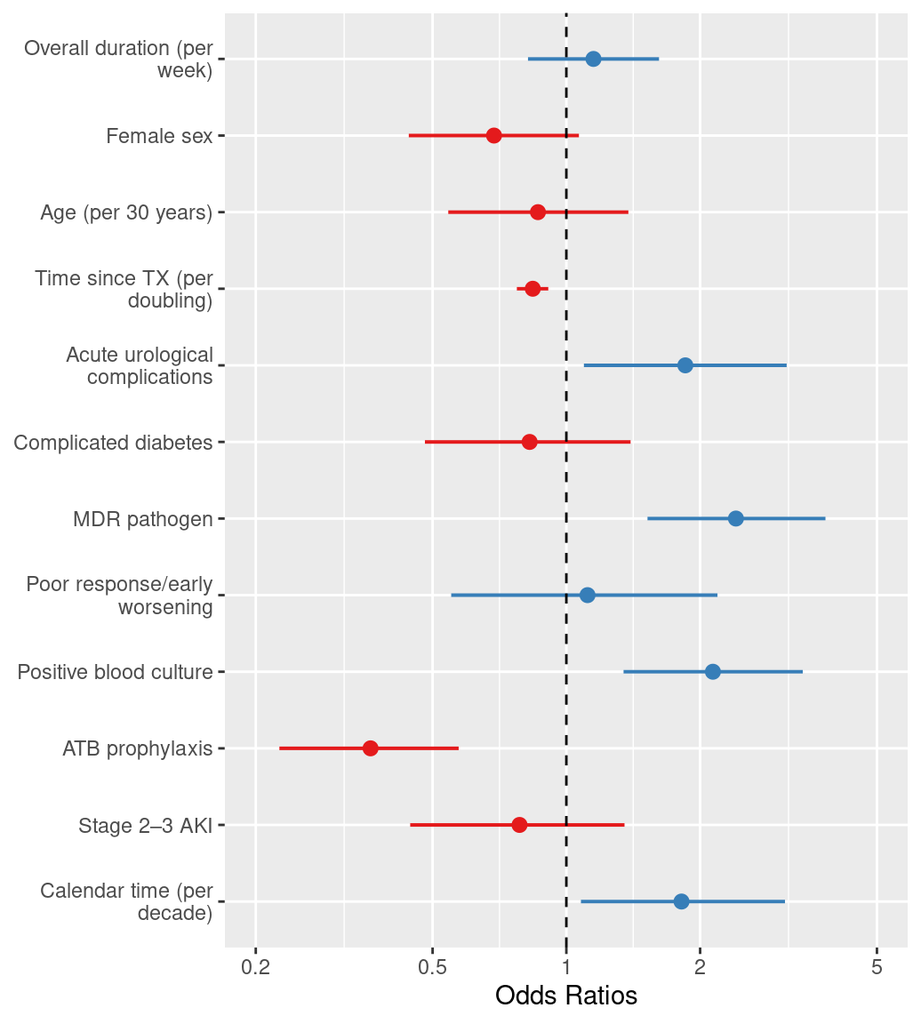

Figure 9. 30-day recurrence. Overall duration per seven days. Points show adjusted logistic-regression odds ratios and horizontal lines show 95% profile-likelihood confidence intervals. OR states how many times recurrence odds change when a numerical predictor increases by one modelled unit or a binary predictor changes from 0 to 1. For other categorical predictors, the change is from the reference category to the category shown. The dashed line marks OR = 1. Overall duration includes all antibiotic treatment irrespective of in vitro susceptibility. TX denotes transplantation, MDR multidrug resistance, ATB antibiotics and AKI acute kidney injury

```r
myplot <- plot_my_model(
  m_30D_overall_7d,
  axis.lim = c(0.49, 4.9)
  )


plotac <- "fig_x09"
myplot <- save_plot(myplot, plotac, width = 5.4, height = 6.0)
myplot
```

## 5.8 90-day recurrence. Overall duration per seven days

Fit the model

**Open code**

```r
m_90D_overall_7d <- glm(
  recurence_till_90D ~
    ATB_overall_per7 +
    sex_female +
    age_by30y +
    log2_TX_to_infection +
    urology_acute +
    diabetes_severe +
    mra_positive +
    bad_response_early_worsening +
    hemoculture_positive +
    profylaxis +
    severe_aki +
    I(years_from2019 / 10),
  data = data_analysis,
  family = binomial(link = "logit")
)
summary(m_90D_overall_7d)
##
## Call:
## glm(formula = recurence_till_90D ~ ATB_overall_per7 + sex_female +
##     age_by30y + log2_TX_to_infection + urology_acute + diabetes_severe +
##     mra_positive + bad_response_early_worsening + hemoculture_positive +
##     profylaxis + severe_aki + I(years_from2019/10), family = binomial(link = "logit"),
##     data = data_analysis)
##
## Coefficients:
##                              Estimate Std. Error z value Pr(>|z|)
## (Intercept)                  -0.09689    0.57044  -0.170 0.865129
## ATB_overall_per7             -0.01272    0.15966  -0.080 0.936489
## sex_female                   -0.18973    0.20960  -0.905 0.365364
## age_by30y                    -0.07390    0.21917  -0.337 0.735990
## log2_TX_to_infection         -0.12984    0.03815  -3.404 0.000665 ***
## urology_acute                 0.87282    0.26130   3.340 0.000837 ***
## diabetes_severe              -0.07062    0.25264  -0.280 0.779849
## mra_positive                  1.21001    0.22230   5.443 5.24e-08 ***
## bad_response_early_worsening  0.20355    0.32848   0.620 0.535462
## hemoculture_positive          0.42599    0.22735   1.874 0.060975 .
## profylaxis                   -0.67789    0.21758  -3.116 0.001836 **
## severe_aki                   -0.31719    0.26019  -1.219 0.222812
## I(years_from2019/10)          0.58313    0.25017   2.331 0.019755 *
## ---
## Signif. codes:  0 '***' 0.001 '**' 0.01 '*' 0.05 '.' 0.1 ' ' 1
##
## (Dispersion parameter for binomial family taken to be 1)
##
##     Null deviance: 724.69  on 543  degrees of freedom
## Residual deviance: 623.31  on 531  degrees of freedom
## AIC: 649.31
##
## Number of Fisher Scoring iterations: 4
car::vif(m_90D_overall_7d)
##             ATB_overall_per7                   sex_female
##                     1.253323                     1.161983
##                    age_by30y         log2_TX_to_infection
##                     1.113346                     1.305295
##                urology_acute              diabetes_severe
##                     1.178500                     1.082404
##                 mra_positive bad_response_early_worsening
##                     1.234804                     1.058994
##         hemoculture_positive                   profylaxis
##                     1.163638                     1.245732
##                   severe_aki         I(years_from2019/10)
##                     1.101320                     1.140759

sjPlot::tab_model(
  m_90D_overall_7d,
  pred.labels = unname(
    my_labels_dict[names(coef(m_90D_overall_7d))]
  ),
  show.ci = 0.95,
  show.p = TRUE,
  show.se = FALSE,
  digits = 3,
  title = "90-day recurrence. Overall duration per seven days: adjusted odds ratios"
)
```

90-day recurrence. Overall duration per seven days: adjusted odds ratios

|  | recurence till 90 D |  |  |
| --- | --- | --- | --- |
| Predictors | Odds Ratios | CI | p |
| Intercept | 0.908 | 0.296 – 2.776 | 0.865 |
| Overall duration of therapy, per additional week | 0.987 | 0.721 – 1.351 | 0.936 |
| Female sex | 0.827 | 0.548 – 1.249 | 0.365 |
| Age, per 30 years | 0.929 | 0.604 – 1.429 | 0.736 |
| Time from transplantation, per doubling | 0.878 | 0.814 – 0.946 | **0.001** |
| Acute urological complications | 2.394 | 1.440 – 4.018 | **0.001** |
| Complicated diabetes mellitus | 0.932 | 0.565 – 1.523 | 0.780 |
| Multidrug-resistant pathogen | 3.354 | 2.177 – 5.212 | **<0.001** |
| Unfavourable clinical response | 1.226 | 0.638 – 2.324 | 0.535 |
| Positive blood culture | 1.531 | 0.980 – 2.394 | 0.061 |
| Antibiotic prophylaxis | 0.508 | 0.329 – 0.774 | **0.002** |
| Stage 2–3 AKI | 0.728 | 0.433 – 1.205 | 0.223 |
| Calendar time, per decade | 1.792 | 1.102 – 2.943 | **0.020** |
| Observations | 544 |  |  |
| R<sup>2</sup> Tjur | 0.176 |  |  |

Plot the model

**Open code**

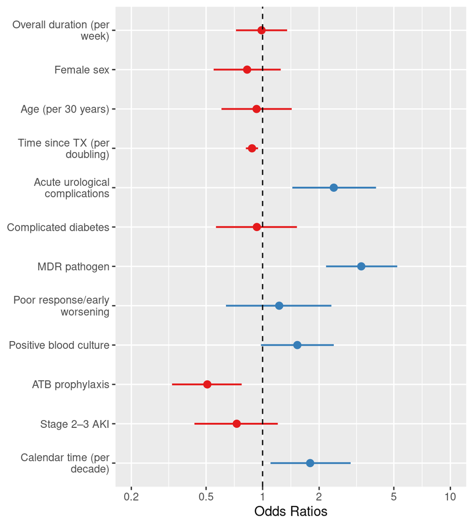

Figure 10. 90-day recurrence. Overall duration per seven days. Points show adjusted logistic-regression odds ratios and horizontal lines show 95% profile-likelihood confidence intervals. OR states how many times recurrence odds change when a numerical predictor increases by one modelled unit or a binary predictor changes from 0 to 1. For other categorical predictors, the change is from the reference category to the category shown. The dashed line marks OR = 1. Overall duration includes all antibiotic treatment irrespective of in vitro susceptibility. TX denotes transplantation, MDR multidrug resistance, ATB antibiotics and AKI acute kidney injury

```r
myplot <- plot_my_model(
  m_90D_overall_7d,
  axis.lim = c(0.24, 5)
  )


plotac <- "fig_x10"
myplot <- save_plot(myplot, plotac, width = 5.4, height = 6.0)
myplot
```

## 5.9 30-day recurrence. Overall duration per doubling

Fit the model

**Open code**

```r
m_30D_overall_log2 <- glm(
  recurence_till_1M ~
    log2_ATB_duration_overall +
    sex_female +
    age_by30y +
    log2_TX_to_infection +
    urology_acute +
    diabetes_severe +
    mra_positive +
    bad_response_early_worsening +
    hemoculture_positive +
    profylaxis +
    severe_aki +
    I(years_from2019 / 10),
  data = data_analysis,
  family = binomial(link = "logit")
)
summary(m_30D_overall_log2)
##
## Call:
## glm(formula = recurence_till_1M ~ log2_ATB_duration_overall +
##     sex_female + age_by30y + log2_TX_to_infection + urology_acute +
##     diabetes_severe + mra_positive + bad_response_early_worsening +
##     hemoculture_positive + profylaxis + severe_aki + I(years_from2019/10),
##     family = binomial(link = "logit"), data = data_analysis)
##
## Coefficients:
##                              Estimate Std. Error z value Pr(>|z|)
## (Intercept)                  -0.86594    1.04084  -0.832 0.405431
## log2_ATB_duration_overall     0.21783    0.24134   0.903 0.366746
## sex_female                   -0.37235    0.22441  -1.659 0.097062 .
## age_by30y                    -0.14446    0.23777  -0.608 0.543478
## log2_TX_to_infection         -0.17406    0.04146  -4.199 2.68e-05 ***
## urology_acute                 0.61378    0.26768   2.293 0.021851 *
## diabetes_severe              -0.19059    0.27131  -0.702 0.482395
## mra_positive                  0.88095    0.23503   3.748 0.000178 ***
## bad_response_early_worsening  0.10707    0.34926   0.307 0.759173
## hemoculture_positive          0.75159    0.23697   3.172 0.001515 **
## profylaxis                   -1.01155    0.23658  -4.276 1.91e-05 ***
## severe_aki                   -0.24308    0.28211  -0.862 0.388885
## I(years_from2019/10)          0.60146    0.26898   2.236 0.025346 *
## ---
## Signif. codes:  0 '***' 0.001 '**' 0.01 '*' 0.05 '.' 0.1 ' ' 1
##
## (Dispersion parameter for binomial family taken to be 1)
##
##     Null deviance: 648.28  on 543  degrees of freedom
## Residual deviance: 557.47  on 531  degrees of freedom
## AIC: 583.47
##
## Number of Fisher Scoring iterations: 4
car::vif(m_30D_overall_log2)
##    log2_ATB_duration_overall                   sex_female
##                     1.259311                     1.159512
##                    age_by30y         log2_TX_to_infection
##                     1.119660                     1.336508
##                urology_acute              diabetes_severe
##                     1.175969                     1.097785
##                 mra_positive bad_response_early_worsening
##                     1.241972                     1.048754
##         hemoculture_positive                   profylaxis
##                     1.175158                     1.290311
##                   severe_aki         I(years_from2019/10)
##                     1.115336                     1.135297

sjPlot::tab_model(
  m_30D_overall_log2,
  pred.labels = unname(
    my_labels_dict[names(coef(m_30D_overall_log2))]
  ),
  show.ci = 0.95,
  show.p = TRUE,
  show.se = FALSE,
  digits = 3,
  title = "30-day recurrence. Overall duration per doubling: adjusted odds ratios"
)
```

30-day recurrence. Overall duration per doubling: adjusted odds ratios

|  | recurence till 1 M |  |  |
| --- | --- | --- | --- |
| Predictors | Odds Ratios | CI | p |
| Intercept | 0.421 | 0.053 – 3.187 | 0.405 |
| Overall duration of therapy, per doubling | 1.243 | 0.778 – 2.007 | 0.367 |
| Female sex | 0.689 | 0.443 – 1.070 | 0.097 |
| Age, per 30 years | 0.865 | 0.544 – 1.383 | 0.543 |
| Time from transplantation, per doubling | 0.840 | 0.774 – 0.911 | **<0.001** |
| Acute urological complications | 1.847 | 1.092 – 3.125 | **0.022** |
| Complicated diabetes mellitus | 0.826 | 0.480 – 1.395 | 0.482 |
| Multidrug-resistant pathogen | 2.413 | 1.526 – 3.840 | **<0.001** |
| Unfavourable clinical response | 1.113 | 0.550 – 2.178 | 0.759 |
| Positive blood culture | 2.120 | 1.333 – 3.381 | **0.002** |
| Antibiotic prophylaxis | 0.364 | 0.227 – 0.574 | **<0.001** |
| Stage 2–3 AKI | 0.784 | 0.445 – 1.350 | 0.389 |
| Calendar time, per decade | 1.825 | 1.084 – 3.118 | **0.025** |
| Observations | 544 |  |  |
| R<sup>2</sup> Tjur | 0.160 |  |  |

Plot the model

**Open code**

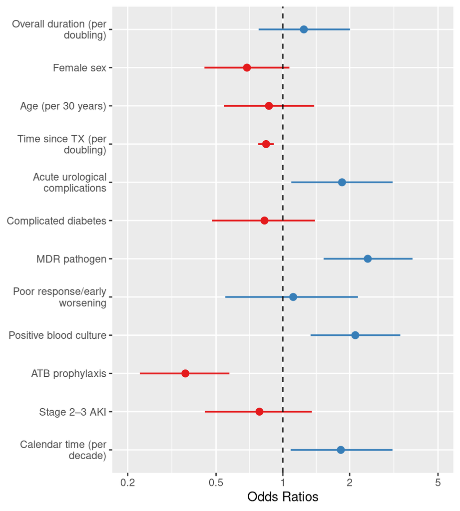

```r
#| fig-cap: "Figure 11. 30-day recurrence. Overall duration per doubling. Points show adjusted logistic-regression odds ratios and horizontal lines show 95% profile-likelihood confidence intervals. OR states how many times recurrence odds change when a numerical predictor increases by one modelled unit or a binary predictor changes from 0 to 1. For other categorical predictors, the change is from the reference category to the category shown. The dashed line marks OR = 1. Overall duration includes all antibiotic treatment irrespective of in vitro susceptibility. TX denotes transplantation, MDR multidrug resistance, ATB antibiotics and AKI acute kidney injury"

myplot <- plot_my_model(
  m_30D_overall_log2,
  axis.lim = c(0.49, 4.5)
  )

plotac <- "fig_x11"
myplot <- save_plot(myplot, plotac, width = 5.4, height = 6.0)
myplot
```

## 5.10 90-day recurrence. Overall duration per doubling

Fit the model

**Open code**

```r
m_90D_overall_log2 <- glm(
  recurence_till_90D ~
    log2_ATB_duration_overall +
    sex_female +
    age_by30y +
    log2_TX_to_infection +
    urology_acute +
    diabetes_severe +
    mra_positive +
    bad_response_early_worsening +
    hemoculture_positive +
    profylaxis +
    severe_aki +
    I(years_from2019 / 10),
  data = data_analysis,
  family = binomial(link = "logit")
)
summary(m_90D_overall_log2)
##
## Call:
## glm(formula = recurence_till_90D ~ log2_ATB_duration_overall +
##     sex_female + age_by30y + log2_TX_to_infection + urology_acute +
##     diabetes_severe + mra_positive + bad_response_early_worsening +
##     hemoculture_positive + profylaxis + severe_aki + I(years_from2019/10),
##     family = binomial(link = "logit"), data = data_analysis)
##
## Coefficients:
##                              Estimate Std. Error z value Pr(>|z|)
## (Intercept)                  -0.01992    0.94529  -0.021 0.983184
## log2_ATB_duration_overall    -0.02734    0.21887  -0.125 0.900584
## sex_female                   -0.18967    0.20952  -0.905 0.365328
## age_by30y                    -0.07449    0.21922  -0.340 0.733998
## log2_TX_to_infection         -0.12973    0.03813  -3.402 0.000669 ***
## urology_acute                 0.87347    0.26131   3.343 0.000830 ***
## diabetes_severe              -0.07067    0.25264  -0.280 0.779701
## mra_positive                  1.20893    0.22235   5.437 5.42e-08 ***
## bad_response_early_worsening  0.20611    0.32738   0.630 0.528973
## hemoculture_positive          0.42898    0.22758   1.885 0.059436 .
## profylaxis                   -0.67834    0.21765  -3.117 0.001829 **
## severe_aki                   -0.31616    0.25984  -1.217 0.223704
## I(years_from2019/10)          0.58073    0.24934   2.329 0.019857 *
## ---
## Signif. codes:  0 '***' 0.001 '**' 0.01 '*' 0.05 '.' 0.1 ' ' 1
##
## (Dispersion parameter for binomial family taken to be 1)
##
##     Null deviance: 724.69  on 543  degrees of freedom
## Residual deviance: 623.30  on 531  degrees of freedom
## AIC: 649.3
##
## Number of Fisher Scoring iterations: 4
car::vif(m_90D_overall_log2)
##    log2_ATB_duration_overall                   sex_female
##                     1.237876                     1.161035
##                    age_by30y         log2_TX_to_infection
##                     1.113945                     1.304580
##                urology_acute              diabetes_severe
##                     1.178701                     1.082401
##                 mra_positive bad_response_early_worsening
##                     1.235407                     1.051981
##         hemoculture_positive                   profylaxis
##                     1.166056                     1.246512
##                   severe_aki         I(years_from2019/10)
##                     1.098437                     1.133474

sjPlot::tab_model(
  m_90D_overall_log2,
  pred.labels = unname(
    my_labels_dict[names(coef(m_90D_overall_log2))]
  ),
  show.ci = 0.95,
  show.p = TRUE,
  show.se = FALSE,
  digits = 3,
  title = "90-day recurrence. Overall duration per doubling: adjusted odds ratios"
)
```

90-day recurrence. Overall duration per doubling: adjusted odds ratios

|  | recurence till 90 D |  |  |
| --- | --- | --- | --- |
| Predictors | Odds Ratios | CI | p |
| Intercept | 0.980 | 0.152 – 6.229 | 0.983 |
| Overall duration of therapy, per doubling | 0.973 | 0.634 – 1.498 | 0.901 |
| Female sex | 0.827 | 0.549 – 1.248 | 0.365 |
| Age, per 30 years | 0.928 | 0.604 – 1.428 | 0.734 |
| Time from transplantation, per doubling | 0.878 | 0.815 – 0.946 | **0.001** |
| Acute urological complications | 2.395 | 1.441 – 4.021 | **0.001** |
| Complicated diabetes mellitus | 0.932 | 0.565 – 1.523 | 0.780 |
| Multidrug-resistant pathogen | 3.350 | 2.175 – 5.207 | **<0.001** |
| Unfavourable clinical response | 1.229 | 0.641 – 2.325 | 0.529 |
| Positive blood culture | 1.536 | 0.983 – 2.402 | 0.059 |
| Antibiotic prophylaxis | 0.507 | 0.329 – 0.774 | **0.002** |
| Stage 2–3 AKI | 0.729 | 0.434 – 1.205 | 0.224 |
| Calendar time, per decade | 1.787 | 1.101 – 2.931 | **0.020** |
| Observations | 544 |  |  |
| R<sup>2</sup> Tjur | 0.176 |  |  |

Plot the model

**Open code**

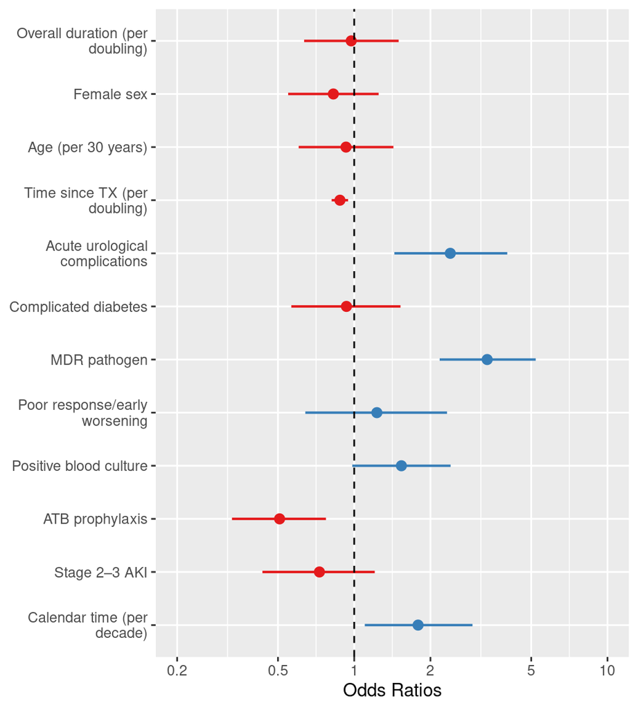

Figure 12. 90-day recurrence. Overall duration per doubling. Points show adjusted logistic-regression odds ratios and horizontal lines show 95% profile-likelihood confidence intervals. OR states how many times recurrence odds change when a numerical predictor increases by one modelled unit or a binary predictor changes from 0 to 1. For other categorical predictors, the change is from the reference category to the category shown. The dashed line marks OR = 1. Overall duration includes all antibiotic treatment irrespective of in vitro susceptibility. TX denotes transplantation, MDR multidrug resistance, ATB antibiotics and AKI acute kidney injury

```r
myplot <- plot_my_model(
  m_90D_overall_log2,
  axis.lim = c(0.49, 5)
  )

plotac <- "fig_x12"
myplot <- save_plot(myplot, plotac, width = 5.4, height = 6.0)
myplot
```

## 5.11 30-day recurrence. Sensitivity ATB duration with immunosuppression

Add maintenance immunosuppression and prior depletion or rejection treatment to the corresponding original model. The original covariates, remain unchanged.

**Open code**

```r
m_30D_sensitivity_IS <- glm(
  recurence_till_1M ~
    ATB_sensitivity_per7 +
    sex_female +
    age_by30y +
    log2_TX_to_infection +
    urology_acute +
    diabetes_severe +
    mra_positive +
    bad_response_early_worsening +
    hemoculture_positive +
    profylaxis +
    severe_aki +
    I(years_from2019 / 10) +
    immunosuppression_regimen +
    depletion_induction_or_rejection_treatment_6M,
  data = data_analysis,
  family = binomial(link = "logit")
)
summary(m_30D_sensitivity_IS)
##
## Call:
## glm(formula = recurence_till_1M ~ ATB_sensitivity_per7 + sex_female +
##     age_by30y + log2_TX_to_infection + urology_acute + diabetes_severe +
##     mra_positive + bad_response_early_worsening + hemoculture_positive +
##     profylaxis + severe_aki + I(years_from2019/10) + immunosuppression_regimen +
##     depletion_induction_or_rejection_treatment_6M, family = binomial(link = "logit"),
##     data = data_analysis)
##
## Coefficients:
##                                               Estimate Std. Error z value
## (Intercept)                                   -0.57786    0.65851  -0.878
## ATB_sensitivity_per7                           0.18232    0.18159   1.004
## sex_female                                    -0.37291    0.22539  -1.655
## age_by30y                                     -0.11816    0.24247  -0.487
## log2_TX_to_infection                          -0.14823    0.04933  -3.005
## urology_acute                                  0.61765    0.27016   2.286
## diabetes_severe                               -0.17564    0.27270  -0.644
## mra_positive                                   0.90608    0.23761   3.813
## bad_response_early_worsening                   0.07785    0.35073   0.222
## hemoculture_positive                           0.73887    0.23807   3.104
## profylaxis                                    -1.00925    0.23747  -4.250
## severe_aki                                    -0.25950    0.28380  -0.914
## I(years_from2019/10)                           0.59856    0.27431   2.182
## immunosuppression_regimenother triple         -0.21940    0.48049  -0.457
## immunosuppression_regimendual or single       -0.11203    0.35938  -0.312
## depletion_induction_or_rejection_treatment_6M  0.23175    0.26302   0.881
##                                               Pr(>|z|)
## (Intercept)                                   0.380205
## ATB_sensitivity_per7                          0.315369
## sex_female                                    0.098017 .
## age_by30y                                     0.626024
## log2_TX_to_infection                          0.002658 **
## urology_acute                                 0.022242 *
## diabetes_severe                               0.519516
## mra_positive                                  0.000137 ***
## bad_response_early_worsening                  0.824349
## hemoculture_positive                          0.001912 **
## profylaxis                                    2.14e-05 ***
## severe_aki                                    0.360508
## I(years_from2019/10)                          0.029109 *
## immunosuppression_regimenother triple         0.647943
## immunosuppression_regimendual or single       0.755236
## depletion_induction_or_rejection_treatment_6M 0.378250
## ---
## Signif. codes:  0 '***' 0.001 '**' 0.01 '*' 0.05 '.' 0.1 ' ' 1
##
## (Dispersion parameter for binomial family taken to be 1)
##
##     Null deviance: 648.28  on 543  degrees of freedom
## Residual deviance: 556.23  on 528  degrees of freedom
## AIC: 588.23
##
## Number of Fisher Scoring iterations: 4
car::vif(m_30D_sensitivity_IS)
##                                                   GVIF Df GVIF^(1/(2*Df))
## ATB_sensitivity_per7                          1.295337  1        1.138129
## sex_female                                    1.166608  1        1.080096
## age_by30y                                     1.157100  1        1.075686
## log2_TX_to_infection                          1.886173  1        1.373380
## urology_acute                                 1.192909  1        1.092204
## diabetes_severe                               1.106787  1        1.052039
## mra_positive                                  1.266595  1        1.125431
## bad_response_early_worsening                  1.053867  1        1.026580
## hemoculture_positive                          1.182370  1        1.087368
## profylaxis                                    1.296456  1        1.138620
## severe_aki                                    1.121834  1        1.059167
## I(years_from2019/10)                          1.173276  1        1.083179
## immunosuppression_regimen                     1.301021  2        1.067999
## depletion_induction_or_rejection_treatment_6M 1.308100  1        1.143722
sjPlot::tab_model(
  m_30D_sensitivity_IS,
  pred.labels = unname(
    my_labels_dict[names(coef(m_30D_sensitivity_IS))]
  ),
  show.ci = 0.95,
  show.p = TRUE,
  show.se = FALSE,
  digits = 3,
  title = "30-day recurrence. Sensitivity ATB duration with immunosuppression: adjusted odds ratios"
)
```

30-day recurrence. Sensitivity ATB duration with immunosuppression: adjusted odds ratios

|  | recurence till 1 M |  |  |
| --- | --- | --- | --- |
| Predictors | Odds Ratios | CI | p |
| Intercept | 0.561 | 0.153 – 2.028 | 0.380 |
| Duration of appropriate therapy, per additional week | 1.200 | 0.841 – 1.715 | 0.315 |
| Female sex | 0.689 | 0.442 – 1.071 | 0.098 |
| Age, per 30 years | 0.889 | 0.553 – 1.434 | 0.626 |
| Time from transplantation, per doubling | 0.862 | 0.782 – 0.949 | **0.003** |
| Acute urological complications | 1.855 | 1.091 – 3.153 | **0.022** |
| Complicated diabetes mellitus | 0.839 | 0.486 – 1.420 | 0.520 |
| Multidrug-resistant pathogen | 2.475 | 1.557 – 3.959 | **<0.001** |
| Unfavourable clinical response | 1.081 | 0.533 – 2.120 | 0.824 |
| Positive blood culture | 2.094 | 1.313 – 3.345 | **0.002** |
| Antibiotic prophylaxis | 0.364 | 0.227 – 0.576 | **<0.001** |
| Stage 2–3 AKI | 0.771 | 0.437 – 1.332 | 0.361 |
| Calendar time, per decade | 1.819 | 1.070 – 3.142 | **0.029** |
| Immunosuppression, other vs. standard triple | 0.803 | 0.292 – 1.968 | 0.648 |
| Immunosuppression, dual or single vs. standard triple | 0.894 | 0.433 – 1.783 | 0.755 |
| Depletion induction or rejection treatment within 6 months | 1.261 | 0.751 – 2.110 | 0.378 |
| Observations | 544 |  |  |
| R<sup>2</sup> Tjur | 0.163 |  |  |

Plot the model

**Open code**

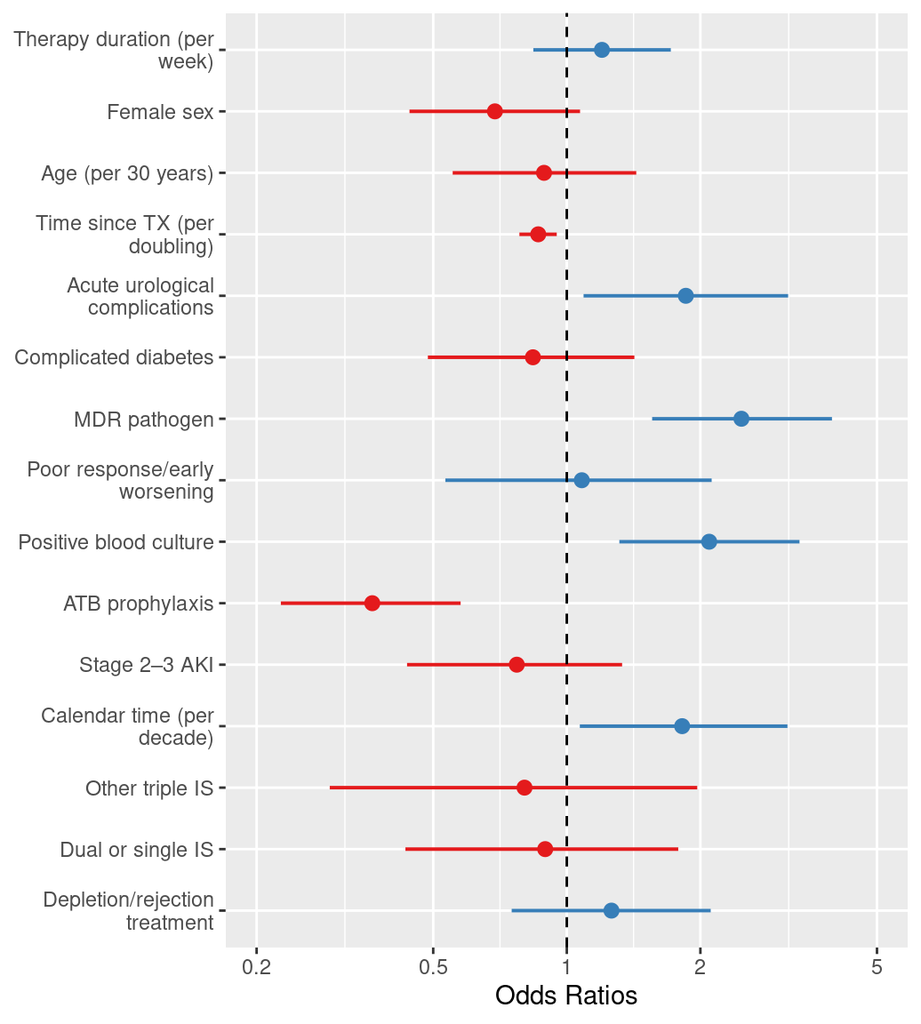

Figure 13. 30-day recurrence. Sensitivity ATB duration with immunosuppression. Points show adjusted logistic-regression odds ratios and horizontal lines show 95% profile-likelihood confidence intervals. The model retains the original adjustment set and adds maintenance immunosuppression and depletion or rejection treatment in the preceding six months. OR states how many times recurrence odds change per modelled numerical unit, from 0 to 1 for binary predictors, or from the reference category to the category shown. Sensitivity ATB duration is per seven days, age per 30 years, calendar time per ten years and log2 variables per doubling. The dashed line marks OR = 1. Therapy duration denotes days of treatment with an antibiotic to which the isolated organism was susceptible in vitro. TX denotes transplantation, MDR multidrug resistance, ATB antibiotics and AKI acute kidney injury. IS denotes maintenance immunosuppression, with standard triple therapy as reference; depletion/rejection treatment refers to the preceding six months

```r
myplot <- plot_my_model(
  m_30D_sensitivity_IS,
  axis.lim = c(0.49, 4.5)
  )


plotac <- "fig_x13"
myplot <- save_plot(myplot, plotac, width = 5.4, height = 6.0)
myplot
```

## 5.12 90-day recurrence. Sensitivity ATB duration with immunosuppression

Add maintenance immunosuppression and prior depletion or rejection treatment to the corresponding original model. The original covariates, remain unchanged.

**Open code**

```r
m_90D_sensitivity_IS <- glm(
  recurence_till_90D ~
    ATB_sensitivity_per7 +
    sex_female +
    age_by30y +
    log2_TX_to_infection +
    urology_acute +
    diabetes_severe +
    mra_positive +
    bad_response_early_worsening +
    hemoculture_positive +
    profylaxis +
    severe_aki +
    I(years_from2019 / 10) +
    immunosuppression_regimen +
    depletion_induction_or_rejection_treatment_6M,
  data = data_analysis,
  family = binomial(link = "logit")
)
summary(m_90D_sensitivity_IS)
##
## Call:
## glm(formula = recurence_till_90D ~ ATB_sensitivity_per7 + sex_female +
##     age_by30y + log2_TX_to_infection + urology_acute + diabetes_severe +
##     mra_positive + bad_response_early_worsening + hemoculture_positive +
##     profylaxis + severe_aki + I(years_from2019/10) + immunosuppression_regimen +
##     depletion_induction_or_rejection_treatment_6M, family = binomial(link = "logit"),
##     data = data_analysis)
##
## Coefficients:
##                                               Estimate Std. Error z value
## (Intercept)                                   -0.39523    0.61319  -0.645
## ATB_sensitivity_per7                           0.03750    0.16815   0.223
## sex_female                                    -0.17848    0.21016  -0.849
## age_by30y                                     -0.02237    0.22343  -0.100
## log2_TX_to_infection                          -0.10568    0.04567  -2.314
## urology_acute                                  0.87175    0.26347   3.309
## diabetes_severe                               -0.07584    0.25356  -0.299
## mra_positive                                   1.25014    0.22603   5.531
## bad_response_early_worsening                   0.18102    0.32927   0.550
## hemoculture_positive                           0.40931    0.22903   1.787
## profylaxis                                    -0.68695    0.21863  -3.142
## severe_aki                                    -0.32930    0.26189  -1.257
## I(years_from2019/10)                           0.57808    0.25457   2.271
## immunosuppression_regimenother triple          0.15502    0.41067   0.377
## immunosuppression_regimendual or single       -0.30289    0.32789  -0.924
## depletion_induction_or_rejection_treatment_6M  0.17921    0.25377   0.706
##                                               Pr(>|z|)
## (Intercept)                                   0.519222
## ATB_sensitivity_per7                          0.823526
## sex_female                                    0.395757
## age_by30y                                     0.920247
## log2_TX_to_infection                          0.020679 *
## urology_acute                                 0.000937 ***
## diabetes_severe                               0.764881
## mra_positive                                  3.18e-08 ***
## bad_response_early_worsening                  0.582478
## hemoculture_positive                          0.073918 .
## profylaxis                                    0.001677 **
## severe_aki                                    0.208610
## I(years_from2019/10)                          0.023158 *
## immunosuppression_regimenother triple         0.705816
## immunosuppression_regimendual or single       0.355611
## depletion_induction_or_rejection_treatment_6M 0.480076
## ---
## Signif. codes:  0 '***' 0.001 '**' 0.01 '*' 0.05 '.' 0.1 ' ' 1
##
## (Dispersion parameter for binomial family taken to be 1)
##
##     Null deviance: 724.69  on 543  degrees of freedom
## Residual deviance: 621.62  on 528  degrees of freedom
## AIC: 653.62
##
## Number of Fisher Scoring iterations: 4
car::vif(m_90D_sensitivity_IS)
##                                                   GVIF Df GVIF^(1/(2*Df))
## ATB_sensitivity_per7                          1.283996  1        1.133135
## sex_female                                    1.164412  1        1.079079
## age_by30y                                     1.150446  1        1.072589
## log2_TX_to_infection                          1.862517  1        1.364741
## urology_acute                                 1.190436  1        1.091071
## diabetes_severe                               1.090894  1        1.044459
## mra_positive                                  1.271900  1        1.127786
## bad_response_early_worsening                  1.058401  1        1.028786
## hemoculture_positive                          1.178102  1        1.085404
## profylaxis                                    1.253416  1        1.119561
## severe_aki                                    1.106210  1        1.051765
## I(years_from2019/10)                          1.173183  1        1.083136
## immunosuppression_regimen                     1.318570  2        1.071583
## depletion_induction_or_rejection_treatment_6M 1.320755  1        1.149241
sjPlot::tab_model(
  m_90D_sensitivity_IS,
  pred.labels = unname(
    my_labels_dict[names(coef(m_90D_sensitivity_IS))]
  ),
  show.ci = 0.95,
  show.p = TRUE,
  show.se = FALSE,
  digits = 3,
  title = "90-day recurrence. Sensitivity ATB duration with immunosuppression: adjusted odds ratios"
)
```

90-day recurrence. Sensitivity ATB duration with immunosuppression: adjusted odds ratios

|  | recurence till 90 D |  |  |
| --- | --- | --- | --- |
| Predictors | Odds Ratios | CI | p |
| Intercept | 0.674 | 0.201 – 2.234 | 0.519 |
| Duration of appropriate therapy, per additional week | 1.038 | 0.747 – 1.445 | 0.824 |
| Female sex | 0.837 | 0.554 – 1.264 | 0.396 |
| Age, per 30 years | 0.978 | 0.631 – 1.518 | 0.920 |
| Time from transplantation, per doubling | 0.900 | 0.822 – 0.984 | **0.021** |
| Acute urological complications | 2.391 | 1.432 – 4.031 | **0.001** |
| Complicated diabetes mellitus | 0.927 | 0.561 – 1.518 | 0.765 |
| Multidrug-resistant pathogen | 3.491 | 2.252 – 5.469 | **<0.001** |
| Unfavourable clinical response | 1.198 | 0.623 – 2.276 | 0.582 |
| Positive blood culture | 1.506 | 0.961 – 2.362 | 0.074 |
| Antibiotic prophylaxis | 0.503 | 0.326 – 0.768 | **0.002** |
| Stage 2–3 AKI | 0.719 | 0.427 – 1.194 | 0.209 |
| Calendar time, per decade | 1.783 | 1.087 – 2.954 | **0.023** |
| Immunosuppression, other vs. standard triple | 1.168 | 0.510 – 2.579 | 0.706 |
| Immunosuppression, dual or single vs. standard triple | 0.739 | 0.383 – 1.391 | 0.356 |
| Depletion induction or rejection treatment within 6 months | 1.196 | 0.726 – 1.967 | 0.480 |
| Observations | 544 |  |  |
| R<sup>2</sup> Tjur | 0.179 |  |  |

Plot the model

**Open code**

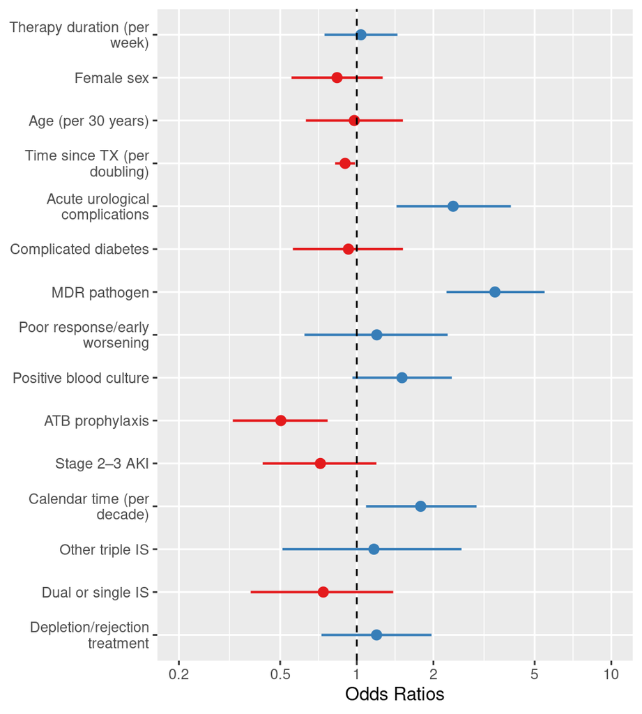

Figure 14. 90-day recurrence. Sensitivity ATB duration with immunosuppression. Points show adjusted logistic-regression odds ratios and horizontal lines show 95% profile-likelihood confidence intervals. The model retains the original adjustment set and adds maintenance immunosuppression and depletion or rejection treatment in the preceding six months. OR states how many times recurrence odds change per modelled numerical unit, from 0 to 1 for binary predictors, or from the reference category to the category shown. Sensitivity ATB duration is per seven days, age per 30 years, calendar time per ten years and log2 variables per doubling. The dashed line marks OR = 1. Therapy duration denotes days of treatment with an antibiotic to which the isolated organism was susceptible in vitro. TX denotes transplantation, MDR multidrug resistance, ATB antibiotics and AKI acute kidney injury. IS denotes maintenance immunosuppression, with standard triple therapy as reference; depletion/rejection treatment refers to the preceding six months

```r
myplot <- plot_my_model(
  m_90D_sensitivity_IS,
  axis.lim = c(0.49, 5)
  )


plotac <- "fig_x14"
myplot <- save_plot(myplot, plotac, width = 5.4, height = 6.0)
myplot
```

## 5.13 90-day, sensitivity per 7D, data 2017+ only

Fit the model

**Open code**

```r
m_90D_effective_7d_2017 <- glm(
  recurence_till_90D ~
    ATB_sensitivity_per7 +
    sex_female +
    age_by30y +
    log2_TX_to_infection +
    urology_acute +
    diabetes_severe +
    mra_positive +
    bad_response_early_worsening +
    hemoculture_positive +
    profylaxis +
    severe_aki +
    I(years_from2019 / 10),
  data = data_analysis |>
    filter(calendar_year >= 2017),
  family = binomial(link = "logit")
)
summary(m_90D_effective_7d_2017)
##
## Call:
## glm(formula = recurence_till_90D ~ ATB_sensitivity_per7 + sex_female +
##     age_by30y + log2_TX_to_infection + urology_acute + diabetes_severe +
##     mra_positive + bad_response_early_worsening + hemoculture_positive +
##     profylaxis + severe_aki + I(years_from2019/10), family = binomial(link = "logit"),
##     data = filter(data_analysis, calendar_year >= 2017))
##
## Coefficients:
##                              Estimate Std. Error z value Pr(>|z|)
## (Intercept)                  -0.10642    0.69770  -0.153  0.87877
## ATB_sensitivity_per7          0.02648    0.19904   0.133  0.89417
## sex_female                   -0.24099    0.24108  -1.000  0.31750
## age_by30y                    -0.19220    0.24951  -0.770  0.44111
## log2_TX_to_infection         -0.08975    0.04314  -2.081  0.03746 *
## urology_acute                 0.82473    0.29923   2.756  0.00585 **
## diabetes_severe               0.05958    0.29733   0.200  0.84119
## mra_positive                  1.30325    0.25893   5.033 4.82e-07 ***
## bad_response_early_worsening  0.20531    0.36383   0.564  0.57256
## hemoculture_positive          0.38628    0.25413   1.520  0.12850
## profylaxis                   -0.56971    0.24817  -2.296  0.02170 *
## severe_aki                   -0.36082    0.30394  -1.187  0.23516
## I(years_from2019/10)          0.56168    0.47058   1.194  0.23264
## ---
## Signif. codes:  0 '***' 0.001 '**' 0.01 '*' 0.05 '.' 0.1 ' ' 1
##
## (Dispersion parameter for binomial family taken to be 1)
##
##     Null deviance: 537.50  on 394  degrees of freedom
## Residual deviance: 468.72  on 382  degrees of freedom
## AIC: 494.72
##
## Number of Fisher Scoring iterations: 4
car::vif(m_90D_effective_7d_2017)
##         ATB_sensitivity_per7                   sex_female
##                     1.317438                     1.166366
##                    age_by30y         log2_TX_to_infection
##                     1.106548                     1.287722
##                urology_acute              diabetes_severe
##                     1.234877                     1.117039
##                 mra_positive bad_response_early_worsening
##                     1.207760                     1.053704
##         hemoculture_positive                   profylaxis
##                     1.148379                     1.234121
##                   severe_aki         I(years_from2019/10)
##                     1.117533                     1.180732

sjPlot::tab_model(
  m_90D_effective_7d_2017,
  pred.labels = unname(
    my_labels_dict[names(coef(m_90D_effective_7d_2017))]
  ),
  show.ci = 0.95,
  show.p = TRUE,
  show.se = FALSE,
  digits = 3,
  title = "90-day recurrence. Sensitivity ATB duration per additional seven days: adjusted odds ratios"
)
```

90-day recurrence. Sensitivity ATB duration per additional seven days: adjusted odds ratios

|  | recurence till 90 D |  |  |
| --- | --- | --- | --- |
| Predictors | Odds Ratios | CI | p |
| Intercept | 0.899 | 0.228 – 3.532 | 0.879 |
| Duration of appropriate therapy, per additional week | 1.027 | 0.695 – 1.520 | 0.894 |
| Female sex | 0.786 | 0.490 – 1.262 | 0.318 |
| Age, per 30 years | 0.825 | 0.504 – 1.345 | 0.441 |
| Time from transplantation, per doubling | 0.914 | 0.840 – 0.995 | **0.037** |
| Acute urological complications | 2.281 | 1.276 – 4.135 | **0.006** |
| Complicated diabetes mellitus | 1.061 | 0.589 – 1.897 | 0.841 |
| Multidrug-resistant pathogen | 3.681 | 2.230 – 6.167 | **<0.001** |
| Unfavourable clinical response | 1.228 | 0.597 – 2.504 | 0.573 |
| Positive blood culture | 1.471 | 0.895 – 2.427 | 0.129 |
| Antibiotic prophylaxis | 0.566 | 0.345 – 0.915 | **0.022** |
| Stage 2–3 AKI | 0.697 | 0.380 – 1.255 | 0.235 |
| Calendar time, per decade | 1.754 | 0.699 – 4.440 | 0.233 |
| Observations | 395 |  |  |
| R<sup>2</sup> Tjur | 0.165 |  |  |

Plot the model

**Open code**

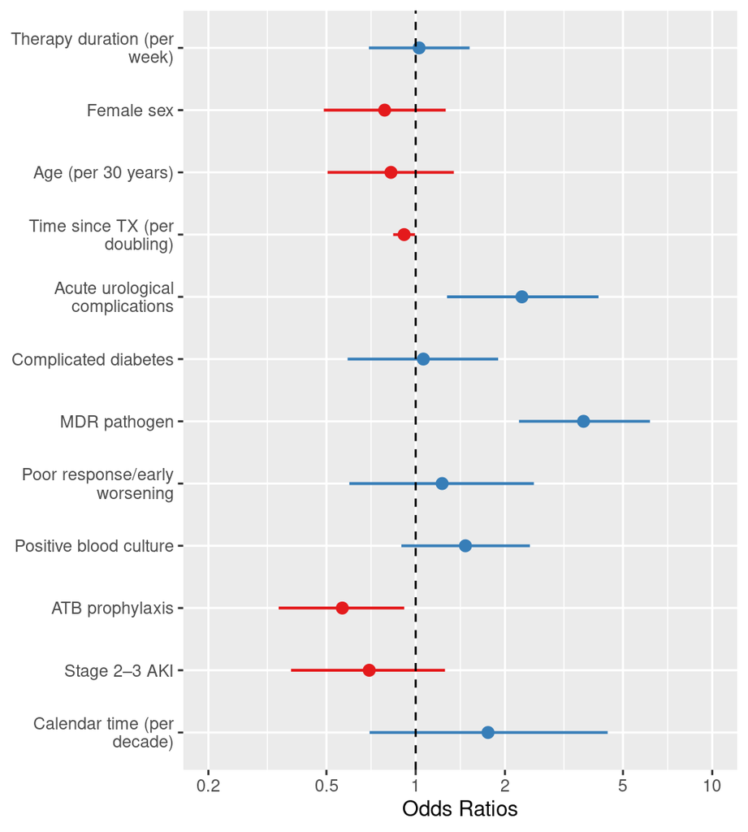

Figure 15. 90-day recurrence. Sensitivity ATB duration per additional seven days (year 2017+). Points show adjusted logistic-regression odds ratios and horizontal lines show 95% profile-likelihood confidence intervals. OR states how many times recurrence odds change when a numerical predictor increases by one modelled unit or a binary predictor changes from 0 to 1. For other categorical predictors, the change is from the reference category to the category shown. The dashed line marks OR = 1. Therapy duration denotes days of treatment with an antibiotic to which the isolated organism was susceptible in vitro. TX denotes transplantation, MDR multidrug resistance, ATB antibiotics and AKI acute kidney injury

```r
myplot <- plot_my_model(
  m_90D_effective_7d_2017,
  axis.lim = c(0.49, 5)
  )


plotac <- "fig_x15"
myplot <- save_plot(myplot, plotac, width = 5.4, height = 6.0)
myplot
```

## 5.14 30-day, sensitivy per 7D, data 2017+ only

Fit the model

**Open code**

```r
m_30D_effective_7d_2017 <- glm(
  recurence_till_1M ~
    ATB_sensitivity_per7 +
    sex_female +
    age_by30y +
    log2_TX_to_infection +
    urology_acute +
    diabetes_severe +
    mra_positive +
    bad_response_early_worsening +
    hemoculture_positive +
    profylaxis +
    severe_aki +
    I(years_from2019 / 10),
  data = data_analysis |> filter(calendar_year >= 2017),
  family = binomial(link = "logit")
)
summary(m_30D_effective_7d_2017)
##
## Call:
## glm(formula = recurence_till_1M ~ ATB_sensitivity_per7 + sex_female +
##     age_by30y + log2_TX_to_infection + urology_acute + diabetes_severe +
##     mra_positive + bad_response_early_worsening + hemoculture_positive +
##     profylaxis + severe_aki + I(years_from2019/10), family = binomial(link = "logit"),
##     data = filter(data_analysis, calendar_year >= 2017))
##
## Coefficients:
##                              Estimate Std. Error z value Pr(>|z|)
## (Intercept)                   0.18409    0.73558   0.250 0.802382
## ATB_sensitivity_per7          0.01981    0.20956   0.095 0.924702
## sex_female                   -0.32335    0.25477  -1.269 0.204375
## age_by30y                    -0.33655    0.26560  -1.267 0.205107
## log2_TX_to_infection         -0.14908    0.04613  -3.232 0.001231 **
## urology_acute                 0.75487    0.30416   2.482 0.013072 *
## diabetes_severe              -0.07142    0.31108  -0.230 0.818423
## mra_positive                  0.96493    0.26367   3.660 0.000253 ***
## bad_response_early_worsening  0.28366    0.37706   0.752 0.451862
## hemoculture_positive          0.73783    0.26293   2.806 0.005013 **
## profylaxis                   -0.98187    0.26812  -3.662 0.000250 ***
## severe_aki                   -0.21134    0.32276  -0.655 0.512599
## I(years_from2019/10)          0.21012    0.49073   0.428 0.668524
## ---
## Signif. codes:  0 '***' 0.001 '**' 0.01 '*' 0.05 '.' 0.1 ' ' 1
##
## (Dispersion parameter for binomial family taken to be 1)
##
##     Null deviance: 496.13  on 394  degrees of freedom
## Residual deviance: 431.98  on 382  degrees of freedom
## AIC: 457.98
##
## Number of Fisher Scoring iterations: 4
car::vif(m_30D_effective_7d_2017)
##         ATB_sensitivity_per7                   sex_female
##                     1.325782                     1.175893
##                    age_by30y         log2_TX_to_infection
##                     1.116361                     1.317061
##                urology_acute              diabetes_severe
##                     1.257144                     1.138366
##                 mra_positive bad_response_early_worsening
##                     1.204129                     1.055107
##         hemoculture_positive                   profylaxis
##                     1.162303                     1.305491
##                   severe_aki         I(years_from2019/10)
##                     1.127670                     1.183453

sjPlot::tab_model(
  m_30D_effective_7d_2017,
  pred.labels = unname(
    my_labels_dict[names(coef(m_30D_effective_7d_2017))]
  ),
  show.ci = 0.95,
  show.p = TRUE,
  show.se = FALSE,
  digits = 3,
  title = "30-day recurrence. Sensitivity ATB duration per additional seven days: adjusted odds ratios"
)
```

30-day recurrence. Sensitivity ATB duration per additional seven days: adjusted odds ratios

|  | recurence till 1 M |  |  |
| --- | --- | --- | --- |
| Predictors | Odds Ratios | CI | p |
| Intercept | 1.202 | 0.283 – 5.092 | 0.802 |
| Duration of appropriate therapy, per additional week | 1.020 | 0.675 – 1.539 | 0.925 |
| Female sex | 0.724 | 0.439 – 1.194 | 0.204 |
| Age, per 30 years | 0.714 | 0.423 – 1.203 | 0.205 |
| Time from transplantation, per doubling | 0.861 | 0.786 – 0.942 | **0.001** |
| Acute urological complications | 2.127 | 1.174 – 3.880 | **0.013** |
| Complicated diabetes mellitus | 0.931 | 0.500 – 1.700 | 0.818 |
| Multidrug-resistant pathogen | 2.625 | 1.570 – 4.423 | **<0.001** |
| Unfavourable clinical response | 1.328 | 0.623 – 2.757 | 0.452 |
| Positive blood culture | 2.091 | 1.251 – 3.515 | **0.005** |
| Antibiotic prophylaxis | 0.375 | 0.219 – 0.628 | **<0.001** |
| Stage 2–3 AKI | 0.809 | 0.423 – 1.508 | 0.513 |
| Calendar time, per decade | 1.234 | 0.472 – 3.244 | 0.669 |
| Observations | 395 |  |  |
| R<sup>2</sup> Tjur | 0.155 |  |  |

Plot the model

**Open code**

[figure not shown]

Figure 16. 30-day recurrence. Sensitivity ATB duration per additional seven days (year 2017+). Points show adjusted logistic-regression odds ratios and horizontal lines show 95% profile-likelihood confidence intervals. OR states how many times recurrence odds change when a numerical predictor increases by one modelled unit or a binary predictor changes from 0 to 1. For other categorical predictors, the change is from the reference category to the category shown. The dashed line marks OR = 1. Therapy duration denotes days of treatment with an antibiotic to which the isolated organism was susceptible in vitro. TX denotes transplantation, MDR multidrug resistance, ATB antibiotics and AKI acute kidney injury

```r
myplot <- plot_my_model(
  m_30D_effective_7d_2017,
  axis.lim = c(0.49, 4.5)
  )


plotac <- "fig_x16"
myplot <- save_plot(myplot, plotac, width = 5.4, height = 6.0)
myplot
```

# 6 Matching

Match treatment groups 1:1 within calendar periods

**Open code**

```r
matching_data <- data_analysis

match_model <- MatchIt::matchit(
  treatment_under14D ~
    sex_female +
    age_by30y +
    log2_TX_to_infection +
    urology_acute +
    stent_in_situ +
    bph_pca_subvesical_obstruction +
    urethral_stricture +
    renofunctional_obstruction +
    diabetes_severe +
    mra_positive +
    bad_response_early_worsening +
    hemoculture_positive +
    profylaxis +
    severe_aki +
    years_from2019 +
    CRP_entry_by100,
  data = matching_data,
  method = "nearest",
  distance = "glm",
  link = "linear.logit",
  exact = ~ calendar_period,
  caliper = 0.2,
  std.caliper = TRUE,
  ratio = 1,
  replace = FALSE,
  estimand = "ATT"
)
## Warning: Fewer control units than treated units in some `exact` strata; not all
## treated units will get a match.

match_summary <- summary(match_model, standardize = TRUE)
matched_data <- MatchIt::match_data(match_model) |>
  data.frame()
```

The 2017+ subset retains complete pairs from all-years matching

Create the 2017+ subsets and show sample sizes.

**Open code**

```r
matching_data_2017 <- matching_data |>
  dplyr::filter(calendar_year >= 2017) |>
  data.frame()

matched_data_2017 <- matched_data |>
  dplyr::filter(calendar_year >= 2017) |>
  data.frame()

matching_counts <- data.frame(
  cohort = c("All", "2017+"),
  available = c(nrow(matching_data), nrow(matching_data_2017)),
  matched = c(nrow(matched_data), nrow(matched_data_2017)),
  pairs = c(
    dplyr::n_distinct(matched_data$subclass),
    dplyr::n_distinct(matched_data_2017$subclass)
  )
)

kableExtra::kable(
  matching_counts,
  caption = "Matching sample sizes for all years and 2017+. available counts eligible patients before matching; matched counts retained patients; pairs counts matched pairs. The 2017+ subset is selected after matching across all years and retains the original pairs and weights"
)
```

Matching sample sizes for all years and 2017+. available counts eligible patients before matching; matched counts retained patients; pairs counts matched pairs. The 2017+ subset is selected after matching across all years and retains the original pairs and weights

| cohort | available | matched | pairs |
| --- | --- | --- | --- |
| All | 544 | 336 | 168 |
| 2017+ | 395 | 248 | 124 |

## 6.1 Exploration, all

### 6.1.1 Safety outcomes

See the Safety outcomes chapter for infections and readmissions within 30 and 90 days after therapy completion

### 6.1.2 Observed treatment duration after matching

Describe actual sensitivity ATB duration, which defines the treatment groups, and overall ATB duration in the same matched patients.

**Open code**

```r
matched_duration_all <- matched_data |>
  dplyr::select(
    treatment_group,
    ATB_sensitivity_duration,
    ATB_duration_overall
  ) |>
  tidyr::pivot_longer(
    cols = c(
      ATB_sensitivity_duration,
      ATB_duration_overall
    ),
    names_to = "duration",
    values_to = "days"
  ) |>
  dplyr::group_by(
    treatment_group,
    duration
  ) |>
  dplyr::summarise(
    patients = dplyr::n(),
    available = sum(!is.na(days)),
    median_days = median(days, na.rm = TRUE),
    q25_days = quantile(days, 0.25, na.rm = TRUE),
    q75_days = quantile(days, 0.75, na.rm = TRUE),
    min_days = min(days, na.rm = TRUE),
    max_days = max(days, na.rm = TRUE),
    .groups = "drop"
  ) |>
  data.frame()

kableExtra::kable(
  matched_duration_all,
  digits = 1,
  caption = "All years. Observed antibiotic treatment duration in the matched cohort. treatment_group is defined by sensitivity ATB duration: short <=13 days and long >13 days. ATB_sensitivity_duration is the interval from sensitivity ATB initiation to therapy completion; ATB_duration_overall is the interval from overall ATB initiation to completion. patients is the group size; available counts nonmissing durations; median_days is the median; q25_days and q75_days are the lower and upper quartiles; min_days and max_days give the observed range. All durations are in days"
)
```

All years. Observed antibiotic treatment duration in the matched cohort. treatment_group is defined by sensitivity ATB duration: short <=13 days and long >13 days. ATB_sensitivity_duration is the interval from sensitivity ATB initiation to therapy completion; ATB_duration_overall is the interval from overall ATB initiation to completion. patients is the group size; available counts nonmissing durations; median_days is the median; q25_days and q75_days are the lower and upper quartiles; min_days and max_days give the observed range. All durations are in days

| treatment_group | duration | patients | available | median_days | q25_days | q75_days | min_days | max_days |
| --- | --- | --- | --- | --- | --- | --- | --- | --- |
| <=13 days | ATB_duration_overall | 168 | 168 | 11 | 9 | 13 | 6 | 19 |
| <=13 days | ATB_sensitivity_duration | 168 | 168 | 10 | 9 | 13 | 6 | 13 |
| >13 days | ATB_duration_overall | 168 | 168 | 17 | 15 | 20 | 14 | 34 |
| >13 days | ATB_sensitivity_duration | 168 | 168 | 16 | 14 | 20 | 14 | 24 |

### 6.1.3 Balance, all

Check balance

**Open code**

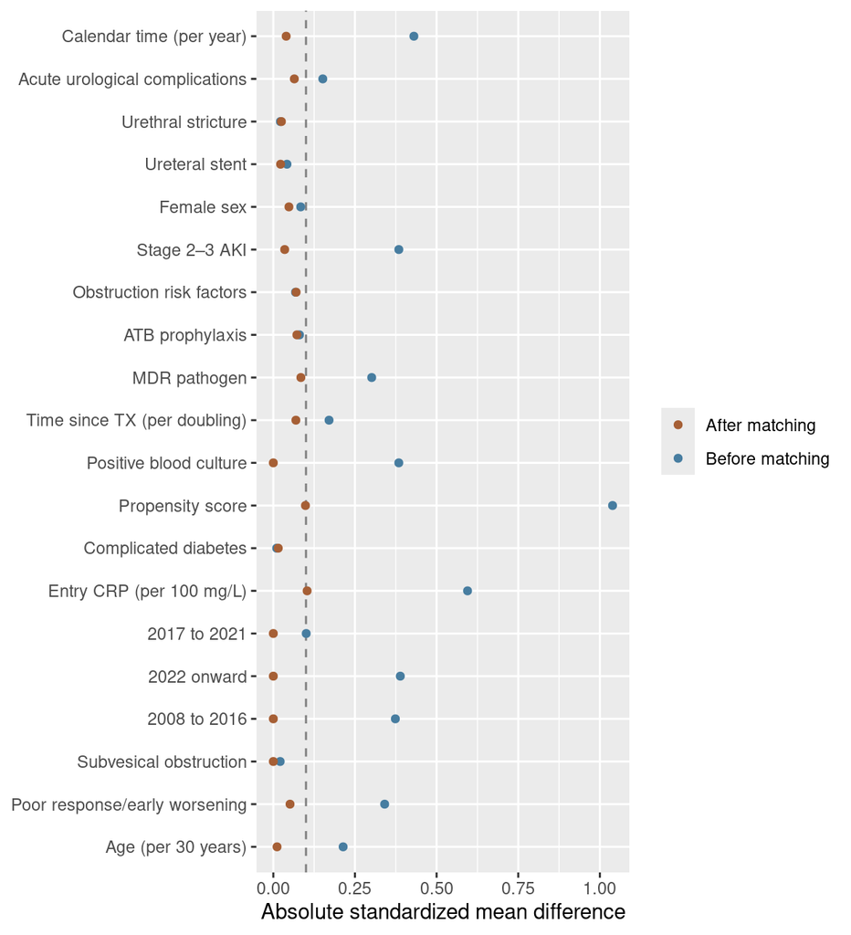

Figure 17. All years. Covariate balance before and after matching. Points show absolute standardized mean differences, standardized by the pre-matching short-treatment group in the displayed cohort; colours distinguish before and after matching. The dashed line marks 0.1. Original all-years matching weights are retained; no rematching is performed. TX denotes transplantation, MDR multidrug resistance, ATB antibiotics and AKI acute kidney injury. Obstruction risk factors is the umbrella category; subvesical obstruction includes urethral stricture. Ureteral stent denotes a stent in situ at discharge

```r
matching_balance_all <- summary(
  match_model,
  standardize = TRUE
)

matching_before_all <- as.data.frame(
  matching_balance_all$sum.all,
  check.names = FALSE
) |>
  tibble::rownames_to_column("covariate") |>
  janitor::clean_names() |>
  dplyr::mutate(stage = "Before matching") |>
  data.frame()

matching_after_all <- as.data.frame(
  matching_balance_all$sum.matched,
  check.names = FALSE
) |>
  tibble::rownames_to_column("covariate") |>
  janitor::clean_names() |>
  dplyr::mutate(stage = "After matching") |>
  data.frame()

matching_balance_plot_all <- dplyr::bind_rows(
  matching_before_all,
  matching_after_all
) |>
  data.frame()

myplot <- ggplot(
  matching_balance_plot_all,
  aes(abs(std_mean_diff), covariate, colour = stage)
) +
  geom_vline(xintercept = 0.1, linetype = "dashed", colour = "grey50") +
  geom_point() +
  scale_y_discrete(labels = function(x) {
    dplyr::coalesce(unname(plot_labels_dict[x]), x)
  }) +
  scale_colour_manual(values = c("#A65F35", "#477DA0")) +
  labs(x = "Absolute standardized mean difference", y = NULL,
       colour = NULL)

plotac <- "fig_x17_matching"

myplot <- save_plot(myplot, plotac, width = 6.1, height = 6.7)
myplot
```

## 6.2 KM after matching, all

Estimate recurrence-free survival and compare matched groups

The existing recurrence indicators are retained. Empty confirmed-recurrence dates mean no recurrence within the recorded 90-day window, as agreed. Patients without recurrence in this window are administratively censored at day 90. The fixed-day comparisons assume recurrence status is known through day 90 for all matched patients; there is no earlier loss to follow-up in this coding.

### 6.2.1 Survival curves and overall log-rank test

Create the survival data and test the curves over the full 90 days. subclass identifies the matched pair.

**Open code**

```r
matched_survival_all <- matched_data |>
  dplyr::mutate(
    treatment = factor(
      dplyr::if_else(treatment_under14D == 1, "short", "long"),
      levels = c("long", "short")
    ),
    time_90D = dplyr::if_else(
      recurence_till_90D == 1,
      as.numeric(Infection_to90D_day - EndDate_therapy),
      90
    )
  ) |>
  data.frame()

km_matched_90D_all <- survfit(
  Surv(time_90D, recurence_till_90D) ~ treatment,
  data = matched_survival_all,
  conf.type = "log-log"
)

logrank_matched_90D_all <- survdiff(
  Surv(time_90D, recurence_till_90D) ~
    treatment + strata(subclass),
  data = matched_survival_all,
  rho = 0
)

logrank_p_all <- pchisq(
  logrank_matched_90D_all$chisq,
  df = 1,
  lower.tail = FALSE
)

logrank_results_all <- data.frame(
  pairs = dplyr::n_distinct(matched_survival_all$subclass),
  patients = nrow(matched_survival_all),
  chi_squared = logrank_matched_90D_all$chisq,
  df = 1,
  p_value = logrank_p_all
)
kableExtra::kable(
  logrank_results_all,
  digits = 3,
  caption = "All years. Overall comparison of recurrence-free survival through 90 days after therapy completion in the 1:1 matched cohort. The log-rank test is stratified by matched pair. pairs and patients are the numbers analysed; chi_squared is the test statistic, df its degrees of freedom, and p_value the unadjusted overall p-value"
)
```

All years. Overall comparison of recurrence-free survival through 90 days after therapy completion in the 1:1 matched cohort. The log-rank test is stratified by matched pair. pairs and patients are the numbers analysed; chi_squared is the test statistic, df its degrees of freedom, and p_value the unadjusted overall p-value

| pairs | patients | chi_squared | df | p_value |
| --- | --- | --- | --- | --- |
| 168 | 336 | 0 | 1 | 1 |

### 6.2.2 Post-hoc comparisons at days 30 and 90

**Open code**

```r
matched_pairs_all <- matched_survival_all |>
  dplyr::select(
    subclass,
    treatment,
    recurence_till_1M,
    recurence_till_90D
  ) |>
  tidyr::pivot_longer(
    cols = c(recurence_till_1M, recurence_till_90D),
    names_to = "outcome",
    values_to = "event"
  ) |>
  dplyr::mutate(
    day = dplyr::if_else(outcome == "recurence_till_1M", 30, 90)
  ) |>
  dplyr::select(-outcome) |>
  tidyr::pivot_wider(
    names_from = treatment,
    values_from = event
  ) |>
  data.frame()

matched_posthoc_all <- matched_pairs_all |>
  dplyr::group_by(day) |>
  dplyr::summarise(
    pairs = dplyr::n(),
    short_events = sum(short),
    long_events = sum(long),
    short_only = sum(short == 1 & long == 0),
    long_only = sum(short == 0 & long == 1),
    .groups = "drop"
  ) |>
  dplyr::rowwise() |>
  dplyr::mutate(
    p_value = if (short_only + long_only == 0) {
      1
    } else {
      binom.test(
        short_only,
        short_only + long_only,
        p = 0.5,
        alternative = "two.sided"
      )$p.value
    }
  ) |>
  dplyr::ungroup() |>
  dplyr::mutate(
    short_risk = short_events / pairs,
    long_risk = long_events / pairs,
    risk_difference = short_risk - long_risk,
    p_holm = p.adjust(p_value, method = "holm")
  ) |>
  dplyr::arrange(day) |>
  data.frame()

kableExtra::kable(
  matched_posthoc_all,
  digits = 3,
  caption = "All years. Post-hoc comparisons of recurrence by days 30 and 90 after therapy completion. short denotes sensitivity ATB duration <=13 days and long denotes >13 days. pairs is the number of matched pairs; short_events and long_events count patients with recurrence in each group. short_only and long_only count discordant pairs in which recurrence occurred only in the short-treatment or only in the long-treatment patient. short_risk and long_risk are recurrence proportions; risk_difference is short minus long. p_value is the two-sided exact McNemar p-value, calculated by a binomial test of discordant pairs; p_holm adjusts the two post-hoc p-values using Holm's method"
)
```

All years. Post-hoc comparisons of recurrence by days 30 and 90 after therapy completion. short denotes sensitivity ATB duration <=13 days and long denotes >13 days. pairs is the number of matched pairs; short_events and long_events count patients with recurrence in each group. short_only and long_only count discordant pairs in which recurrence occurred only in the short-treatment or only in the long-treatment patient. short_risk and long_risk are recurrence proportions; risk_difference is short minus long. p_value is the two-sided exact McNemar p-value, calculated by a binomial test of discordant pairs; p_holm adjusts the two post-hoc p-values using Holm’s method

| day | pairs | short_events | long_events | short_only | long_only | p_value | short_risk | long_risk | risk_difference | p_holm |
| --- | --- | --- | --- | --- | --- | --- | --- | --- | --- | --- |
| 30 | 168 | 42 | 45 | 26 | 29 | 0.788 | 0.250 | 0.268 | -0.018 | 1 |
| 90 | 168 | 63 | 62 | 36 | 35 | 1.000 | 0.375 | 0.369 | 0.006 | 1 |

### 6.2.3 Plot the matched survival curves

Show the overall pair-stratified log-rank p-value and the two Holm-adjusted post-hoc p-values. Shading represents pointwise confidence intervals for each curve.

**Open code**

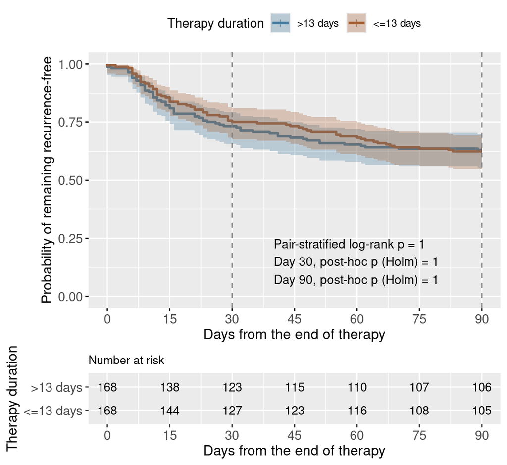

Figure 18. All years. Recurrence-free survival through 90 days after therapy completion in the cohort matched 1:1 on propensity score. Curves are unadjusted Kaplan–Meier estimates for sensitivity ATB duration <=13 and >13 days; shading shows pointwise 95% confidence intervals calculated using Greenwood variance and the log-log transformation. Tick marks indicate censoring and the lower panel shows patients at risk. Vertical dashed lines mark days 30 and 90. The overall p-value is from a log-rank test stratified by matched pair; post-hoc p-values compare recurrence proportions by days 30 and 90 using two-sided exact McNemar tests with Holm adjustment across these two comparisons. Therapy duration denotes days of treatment with an antibiotic to which the isolated organism was susceptible in vitro

```r
km_p_text_all <- paste0(
  "Pair-stratified log-rank p = ",
  format.pval(logrank_p_all, digits = 3, eps = 0),
  "\nDay 30, post-hoc p (Holm) = ",
  format.pval(
    matched_posthoc_all$p_holm[matched_posthoc_all$day == 30],
    digits = 3,
    eps = 0
  ),
  "\nDay 90, post-hoc p (Holm) = ",
  format.pval(
    matched_posthoc_all$p_holm[matched_posthoc_all$day == 90],
    digits = 3,
    eps = 0
  )
)

myplot <- survminer::ggsurvplot(
  km_matched_90D_all,
  data = matched_survival_all,
  pval = km_p_text_all,
  pval.coord = c(40, 0.15),
  pval.size = 3.7,
  conf.int = TRUE,
  risk.table = TRUE,
  risk.table.y.text.col = FALSE,
  risk.table.fontsize = 3.6,
  censor.shape = 124,
  censor.size = 2,
  palette = c("#477DA0", "#A65F35"),
  xlab = "Days from the end of therapy",
  ylab = "Probability of remaining recurrence-free",
  legend.title = "Therapy duration",
  legend.labs = c(">13 days", "<=13 days"),
  break.time.by = 15,
  xlim = c(0, 90),
  ggtheme = theme_grey()
)

myplot$plot <- myplot$plot +
  geom_vline(
    xintercept = c(30, 90),
    linetype = "dashed",
    colour = "grey50"
  )

myplot$plot <- myplot$plot +
  theme(
    plot.title = element_text(size = 12),
    axis.title.x = element_text(size = 12),
    axis.title.y = element_text(size = 12),
    axis.text.x = element_text(size = 11),
    axis.text.y = element_text(size = 11)
  )

myplot$table <- myplot$table +
  theme(
    plot.title = element_text(size = 10),
    axis.title.x = element_text(size = 12),
    axis.title.y = element_text(size = 12),
    axis.text.x = element_text(size = 11),
    axis.text.y = element_text(size = 11)
  )

myplot <- cowplot::plot_grid(
  myplot$plot,
  myplot$table + theme(legend.position = "none"),
  ncol = 1,
  rel_heights = c(0.75, 0.25),
  align = "v",
  axis = "lr"
)



plotac <- "fig_x18_KM"
myplot <- save_plot(myplot, plotac, width = 6, height = 5.5)
myplot
```

### 6.2.4 HR, 90D

**Open code**

```r
m_cox_matched_90D_all <- coxph(
  Surv(time_90D, recurence_till_90D) ~ treatment_under14D,
  data = matched_survival_all,
  cluster = subclass
)

cox_summary_all <- summary(m_cox_matched_90D_all)

cox_results_all <- data.frame(
  comparison = "<=13 versus >13 days",
  n = m_cox_matched_90D_all$n,
  events = m_cox_matched_90D_all$nevent,
  HR = cox_summary_all$conf.int[, "exp(coef)"],
  lower = cox_summary_all$conf.int[, "lower .95"],
  upper = cox_summary_all$conf.int[, "upper .95"],
  p_value = cox_summary_all$coefficients[, "Pr(>|z|)"],
  row.names = NULL
)

kableExtra::kable(
  cox_results_all,
  digits = 3,
  caption = "All years. Recurrence within 90 days after therapy completion in the matched cohort. A Cox proportional hazards model included treatment group as the sole predictor, with robust variance clustered by matched pair. HR compares sensitivity ATB treatment lasting <=13 days with >13 days; HR >1 indicates a higher recurrence hazard with shorter treatment. n is the number of patients; events is the number of recurrences; lower and upper are robust Wald 95% confidence limits; p_value is the two-sided robust Wald p-value"
)
```

All years. Recurrence within 90 days after therapy completion in the matched cohort. A Cox proportional hazards model included treatment group as the sole predictor, with robust variance clustered by matched pair. HR compares sensitivity ATB treatment lasting <=13 days with >13 days; HR >1 indicates a higher recurrence hazard with shorter treatment. n is the number of patients; events is the number of recurrences; lower and upper are robust Wald 95% confidence limits; p_value is the two-sided robust Wald p-value

| comparison | n | events | HR | lower | upper | p_value |
| --- | --- | --- | --- | --- | --- | --- |
| <=13 versus >13 days | 336 | 125 | 0.982 | 0.703 | 1.37 | 0.914 |

### 6.2.5 HR, 30D

Estimate the treatment-group hazard ratio over the first 30 days after therapy completion in the original matched cohort. Follow-up is administratively censored at day 30; recurrences occurring later are not counted as events in this analysis.

**Open code**

```r
matched_survival_30D_all <- matched_survival_all |>
  dplyr::mutate(
    time_30D = pmin(time_90D, 30),
    event_30D = as.integer(
      recurence_till_90D == 1 & time_90D <= 30
    )
  ) |>
  data.frame()

m_cox_matched_30D_all <- coxph(
  Surv(time_30D, event_30D) ~ treatment_under14D,
  data = matched_survival_30D_all,
  cluster = subclass
)

cox_summary_30D_all <- summary(m_cox_matched_30D_all)

cox_results_30D_all <- data.frame(
  comparison = "<=13 versus >13 days",
  n = m_cox_matched_30D_all$n,
  events = m_cox_matched_30D_all$nevent,
  HR = cox_summary_30D_all$conf.int[, "exp(coef)"],
  lower = cox_summary_30D_all$conf.int[, "lower .95"],
  upper = cox_summary_30D_all$conf.int[, "upper .95"],
  p_value = cox_summary_30D_all$coefficients[, "Pr(>|z|)"],
  row.names = NULL
)

kableExtra::kable(
  cox_results_30D_all,
  digits = 3,
  caption = "All years. Recurrence within 30 days after therapy completion in the original matched cohort, irrespective of pathogen concordance. Follow-up was administratively censored at day 30. A Cox proportional hazards model included treatment group as the sole predictor, with robust variance clustered by matched pair. HR states how many times the recurrence hazard changes from >13 to <=13 days of sensitivity ATB treatment; HR >1 indicates a higher hazard with shorter treatment. n is the number analysed; events counts recurrences; lower and upper are robust Wald 95% confidence limits; p_value is the two-sided robust Wald p-value"
)
```

All years. Recurrence within 30 days after therapy completion in the original matched cohort, irrespective of pathogen concordance. Follow-up was administratively censored at day 30. A Cox proportional hazards model included treatment group as the sole predictor, with robust variance clustered by matched pair. HR states how many times the recurrence hazard changes from >13 to <=13 days of sensitivity ATB treatment; HR >1 indicates a higher hazard with shorter treatment. n is the number analysed; events counts recurrences; lower and upper are robust Wald 95% confidence limits; p_value is the two-sided robust Wald p-value

| comparison | n | events | HR | lower | upper | p_value |
| --- | --- | --- | --- | --- | --- | --- |
| <=13 versus >13 days | 336 | 87 | 0.905 | 0.613 | 1.336 | 0.616 |

## 6.3 Exploration, 2017+

### 6.3.1 Safety outcomes

See the Safety outcomes chapter for infections and readmissions within 30 and 90 days after therapy completion

### 6.3.2 Observed treatment duration after matching

Describe actual sensitivity ATB duration, which defines the treatment groups, and overall ATB duration in the same matched patients.

**Open code**

```r
matched_duration_2017 <- matched_data_2017 |>
  dplyr::select(
    treatment_group,
    ATB_sensitivity_duration,
    ATB_duration_overall
  ) |>
  tidyr::pivot_longer(
    cols = c(
      ATB_sensitivity_duration,
      ATB_duration_overall
    ),
    names_to = "duration",
    values_to = "days"
  ) |>
  dplyr::group_by(
    treatment_group,
    duration
  ) |>
  dplyr::summarise(
    patients = dplyr::n(),
    available = sum(!is.na(days)),
    median_days = median(days, na.rm = TRUE),
    q25_days = quantile(days, 0.25, na.rm = TRUE),
    q75_days = quantile(days, 0.75, na.rm = TRUE),
    min_days = min(days, na.rm = TRUE),
    max_days = max(days, na.rm = TRUE),
    .groups = "drop"
  ) |>
  data.frame()

kableExtra::kable(
  matched_duration_2017,
  digits = 1,
  caption = "2017+. Observed antibiotic treatment duration in the matched cohort. treatment_group is defined by sensitivity ATB duration: short <=13 days and long >13 days. ATB_sensitivity_duration is the interval from sensitivity ATB initiation to therapy completion; ATB_duration_overall is the interval from overall ATB initiation to completion. patients is the group size; available counts nonmissing durations; median_days is the median; q25_days and q75_days are the lower and upper quartiles; min_days and max_days give the observed range. All durations are in days"
)
```

2017+. Observed antibiotic treatment duration in the matched cohort. treatment_group is defined by sensitivity ATB duration: short <=13 days and long >13 days. ATB_sensitivity_duration is the interval from sensitivity ATB initiation to therapy completion; ATB_duration_overall is the interval from overall ATB initiation to completion. patients is the group size; available counts nonmissing durations; median_days is the median; q25_days and q75_days are the lower and upper quartiles; min_days and max_days give the observed range. All durations are in days

| treatment_group | duration | patients | available | median_days | q25_days | q75_days | min_days | max_days |
| --- | --- | --- | --- | --- | --- | --- | --- | --- |
| <=13 days | ATB_duration_overall | 124 | 124 | 11 | 9 | 13 | 6 | 19 |
| <=13 days | ATB_sensitivity_duration | 124 | 124 | 10 | 9 | 13 | 6 | 13 |
| >13 days | ATB_duration_overall | 124 | 124 | 17 | 15 | 20 | 14 | 34 |
| >13 days | ATB_sensitivity_duration | 124 | 124 | 16 | 14 | 20 | 14 | 24 |

### 6.3.3 Balance, 2017+

Check balance

**Open code**

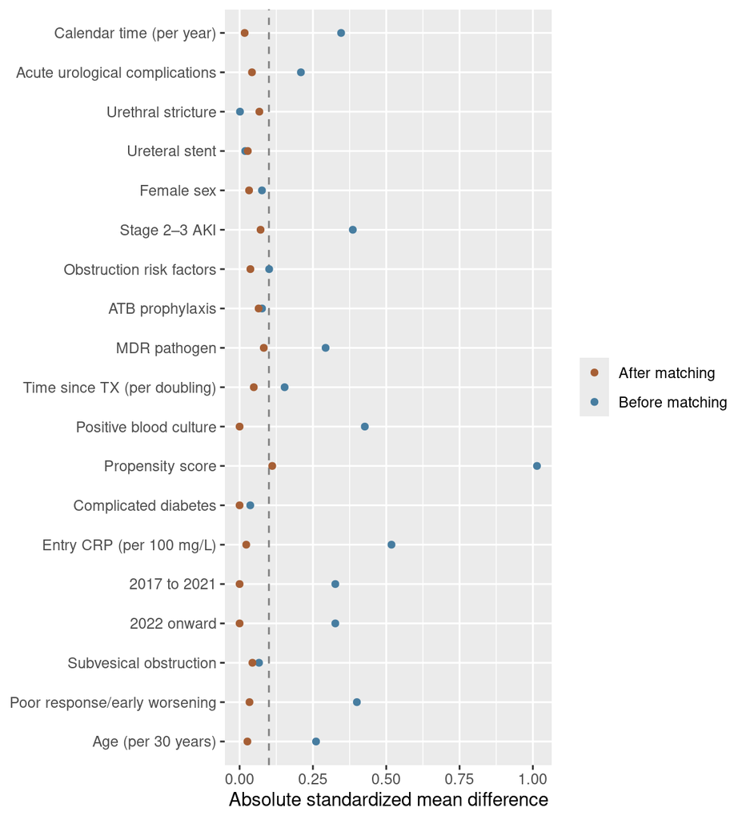

Figure 19. 2017+. Covariate balance before and after matching. Points show absolute standardized mean differences, standardized by the pre-matching short-treatment group in the displayed cohort; colours distinguish before and after matching. The dashed line marks 0.1. Original all-years matching weights are retained; no rematching is performed. TX denotes transplantation, MDR multidrug resistance, ATB antibiotics and AKI acute kidney injury. Obstruction risk factors is the umbrella category; subvesical obstruction includes urethral stricture. Ureteral stent denotes a stent in situ at discharge

```r
matching_keep_2017 <- matching_data$calendar_year >= 2017
match_model_balance_2017 <- match_model
match_model_balance_2017$X <- match_model$X[
  matching_keep_2017, , drop = FALSE
]
match_model_balance_2017$treat <- match_model$treat[
  matching_keep_2017
]
match_model_balance_2017$weights <- match_model$weights[
  matching_keep_2017
]
match_model_balance_2017$distance <- match_model$distance[
  matching_keep_2017
]
match_model_balance_2017$discarded <- match_model$discarded[
  matching_keep_2017
]
match_model_balance_2017$subclass <- match_model$subclass[
  matching_keep_2017
]
match_model_balance_2017$match.matrix <- match_model$match.matrix[
  rownames(match_model$match.matrix) %in%
    names(match_model_balance_2017$treat), , drop = FALSE
]

matching_balance_2017 <- summary(
  match_model_balance_2017,
  standardize = TRUE
)

matching_before_2017 <- as.data.frame(
  matching_balance_2017$sum.all,
  check.names = FALSE
) |>
  tibble::rownames_to_column("covariate") |>
  janitor::clean_names() |>
  dplyr::mutate(stage = "Before matching") |>
  data.frame()

matching_after_2017 <- as.data.frame(
  matching_balance_2017$sum.matched,
  check.names = FALSE
) |>
  tibble::rownames_to_column("covariate") |>
  janitor::clean_names() |>
  dplyr::mutate(stage = "After matching") |>
  data.frame()

matching_balance_plot_2017 <- dplyr::bind_rows(
  matching_before_2017,
  matching_after_2017
) |>
  data.frame()

myplot <- ggplot(
  matching_balance_plot_2017,
  aes(abs(std_mean_diff), covariate, colour = stage)
) +
  geom_vline(xintercept = 0.1, linetype = "dashed", colour = "grey50") +
  geom_point() +
  scale_y_discrete(labels = function(x) {
    dplyr::coalesce(unname(plot_labels_dict[x]), x)
  }) +
  scale_colour_manual(values = c("#A65F35", "#477DA0")) +
  labs(x = "Absolute standardized mean difference", y = NULL,
       colour = NULL)

plotac <- "fig_x19_balance"
myplot <- save_plot(myplot, plotac, width = 6.1, height = 6.7)
myplot
```

## 6.4 KM after matching, 2017+

### 6.4.1 Survival curves and overall log-rank test

**Open code**

```r
matched_survival_2017 <- matched_data_2017 |>
  dplyr::mutate(
    treatment = factor(
      dplyr::if_else(treatment_under14D == 1, "short", "long"),
      levels = c("long", "short")
    ),
    time_90D = dplyr::if_else(
      recurence_till_90D == 1,
      as.numeric(Infection_to90D_day - EndDate_therapy),
      90
    )
  ) |>
  data.frame()

km_matched_90D_2017 <- survfit(
  Surv(time_90D, recurence_till_90D) ~ treatment,
  data = matched_survival_2017,
  conf.type = "log-log"
)

logrank_matched_90D_2017 <- survdiff(
  Surv(time_90D, recurence_till_90D) ~
    treatment + strata(subclass),
  data = matched_survival_2017,
  rho = 0
)

logrank_p_2017 <- pchisq(
  logrank_matched_90D_2017$chisq,
  df = 1,
  lower.tail = FALSE
)

logrank_results_2017 <- data.frame(
  pairs = dplyr::n_distinct(matched_survival_2017$subclass),
  patients = nrow(matched_survival_2017),
  chi_squared = logrank_matched_90D_2017$chisq,
  df = 1,
  p_value = logrank_p_2017
)
kableExtra::kable(
  logrank_results_2017,
  digits = 3,
  caption = "2017+. Overall comparison of recurrence-free survival through 90 days after therapy completion in the 1:1 matched cohort. The log-rank test is stratified by matched pair. pairs and patients are the numbers analysed; chi_squared is the test statistic, df its degrees of freedom, and p_value the unadjusted overall p-value"
)
```

2017+. Overall comparison of recurrence-free survival through 90 days after therapy completion in the 1:1 matched cohort. The log-rank test is stratified by matched pair. pairs and patients are the numbers analysed; chi_squared is the test statistic, df its degrees of freedom, and p_value the unadjusted overall p-value

| pairs | patients | chi_squared | df | p_value |
| --- | --- | --- | --- | --- |
| 124 | 248 | 0 | 1 | 1 |

### 6.4.2 Post-hoc comparisons at days 30 and 90

**Open code**

```r
matched_pairs_2017 <- matched_survival_2017 |>
  dplyr::select(
    subclass,
    treatment,
    recurence_till_1M,
    recurence_till_90D
  ) |>
  tidyr::pivot_longer(
    cols = c(recurence_till_1M, recurence_till_90D),
    names_to = "outcome",
    values_to = "event"
  ) |>
  dplyr::mutate(
    day = dplyr::if_else(outcome == "recurence_till_1M", 30, 90)
  ) |>
  dplyr::select(-outcome) |>
  tidyr::pivot_wider(
    names_from = treatment,
    values_from = event
  ) |>
  data.frame()

matched_posthoc_2017 <- matched_pairs_2017 |>
  dplyr::group_by(day) |>
  dplyr::summarise(
    pairs = dplyr::n(),
    short_events = sum(short),
    long_events = sum(long),
    short_only = sum(short == 1 & long == 0),
    long_only = sum(short == 0 & long == 1),
    .groups = "drop"
  ) |>
  dplyr::rowwise() |>
  dplyr::mutate(
    p_value = if (short_only + long_only == 0) {
      1
    } else {
      binom.test(
        short_only,
        short_only + long_only,
        p = 0.5,
        alternative = "two.sided"
      )$p.value
    }
  ) |>
  dplyr::ungroup() |>
  dplyr::mutate(
    short_risk = short_events / pairs,
    long_risk = long_events / pairs,
    risk_difference = short_risk - long_risk,
    p_holm = p.adjust(p_value, method = "holm")
  ) |>
  dplyr::arrange(day) |>
  data.frame()

kableExtra::kable(
  matched_posthoc_2017,
  digits = 3,
  caption = "2017+. Post-hoc comparisons of recurrence by days 30 and 90 after therapy completion. short denotes sensitivity ATB duration <=13 days and long denotes >13 days. pairs is the number of matched pairs; short_events and long_events count patients with recurrence in each group. short_only and long_only count discordant pairs in which recurrence occurred only in the short-treatment or only in the long-treatment patient. short_risk and long_risk are recurrence proportions; risk_difference is short minus long. p_value is the two-sided exact McNemar p-value, calculated by a binomial test of discordant pairs; p_holm adjusts the two post-hoc p-values using Holm's method"
)
```

2017+. Post-hoc comparisons of recurrence by days 30 and 90 after therapy completion. short denotes sensitivity ATB duration <=13 days and long denotes >13 days. pairs is the number of matched pairs; short_events and long_events count patients with recurrence in each group. short_only and long_only count discordant pairs in which recurrence occurred only in the short-treatment or only in the long-treatment patient. short_risk and long_risk are recurrence proportions; risk_difference is short minus long. p_value is the two-sided exact McNemar p-value, calculated by a binomial test of discordant pairs; p_holm adjusts the two post-hoc p-values using Holm’s method

| day | pairs | short_events | long_events | short_only | long_only | p_value | short_risk | long_risk | risk_difference | p_holm |
| --- | --- | --- | --- | --- | --- | --- | --- | --- | --- | --- |
| 30 | 124 | 37 | 38 | 22 | 23 | 1 | 0.298 | 0.306 | -0.008 | 1 |
| 90 | 124 | 50 | 50 | 26 | 26 | 1 | 0.403 | 0.403 | 0.000 | 1 |

### 6.4.3 Plot the matched survival curves

**Open code**

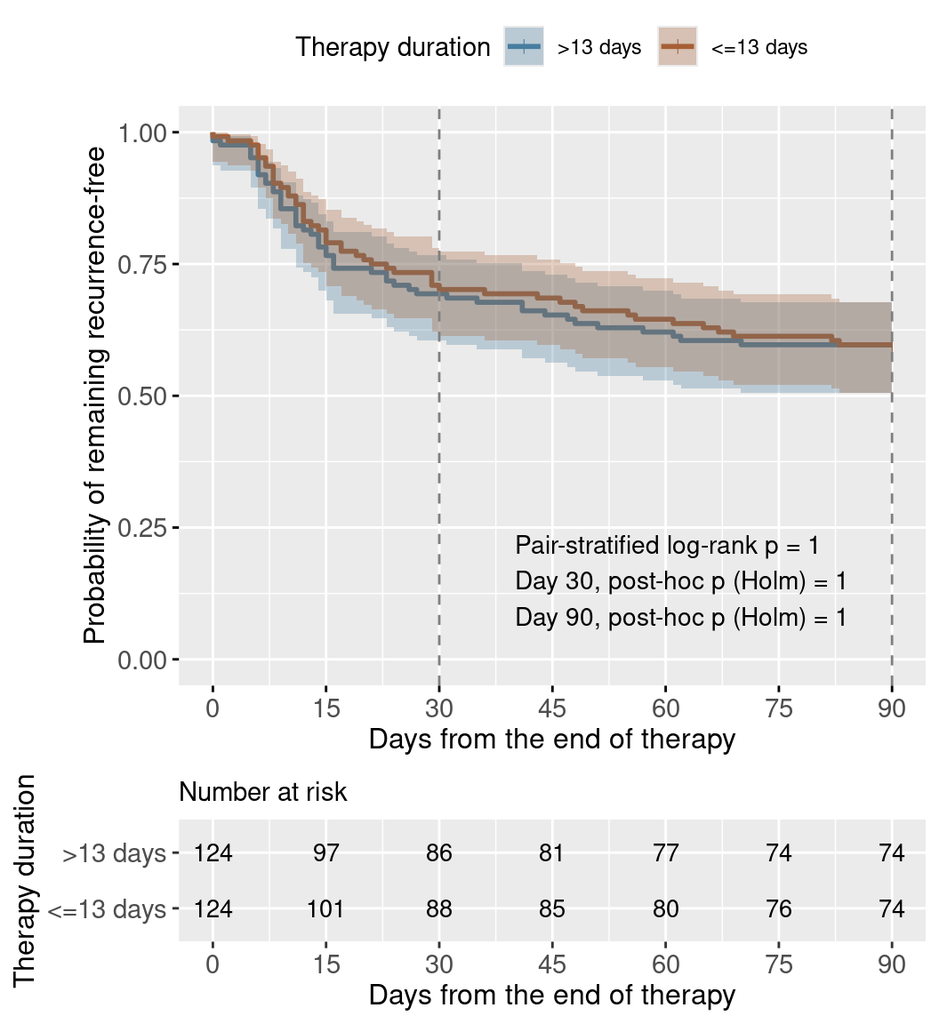

Figure 20. 2017+. Recurrence-free survival through 90 days after therapy completion in the cohort matched 1:1 on propensity score. Curves are unadjusted Kaplan–Meier estimates for sensitivity ATB duration <=13 and >13 days; shading shows pointwise 95% confidence intervals calculated using Greenwood variance and the log-log transformation. Tick marks indicate censoring and the lower panel shows patients at risk. Vertical dashed lines mark days 30 and 90. The overall p-value is from a log-rank test stratified by matched pair; post-hoc p-values compare recurrence proportions by days 30 and 90 using two-sided exact McNemar tests with Holm adjustment across these two comparisons. Therapy duration denotes days of treatment with an antibiotic to which the isolated organism was susceptible in vitro

```r
km_p_text_2017 <- paste0(
  "Pair-stratified log-rank p = ",
  format.pval(logrank_p_2017, digits = 3, eps = 0),
  "\nDay 30, post-hoc p (Holm) = ",
  format.pval(
    matched_posthoc_2017$p_holm[matched_posthoc_2017$day == 30],
    digits = 3,
    eps = 0
  ),
  "\nDay 90, post-hoc p (Holm) = ",
  format.pval(
    matched_posthoc_2017$p_holm[matched_posthoc_2017$day == 90],
    digits = 3,
    eps = 0
  )
)

myplot <- survminer::ggsurvplot(
  km_matched_90D_2017,
  data = matched_survival_2017,
  pval = km_p_text_2017,
  pval.coord = c(40, 0.15),
  pval.size = 3.7,
  conf.int = TRUE,
  risk.table = TRUE,
  risk.table.y.text.col = FALSE,
  risk.table.fontsize = 3.6,
  censor.shape = 124,
  censor.size = 2,
  palette = c("#477DA0", "#A65F35"),
  xlab = "Days from the end of therapy",
  ylab = "Probability of remaining recurrence-free",
  legend.title = "Therapy duration",
  legend.labs = c(">13 days", "<=13 days"),
  break.time.by = 15,
  xlim = c(0, 90),
  ggtheme = theme_grey()
)

myplot$plot <- myplot$plot +
  theme(
    plot.title = element_text(size = 12),
    axis.title.x = element_text(size = 12),
    axis.title.y = element_text(size = 12),
    axis.text.x = element_text(size = 11),
    axis.text.y = element_text(size = 11)
  )

myplot$table <- myplot$table +
  theme(
    plot.title = element_text(size = 11),
    axis.title.x = element_text(size = 12),
    axis.title.y = element_text(size = 12),
    axis.text.x = element_text(size = 11),
    axis.text.y = element_text(size = 11)
  )

myplot$plot <- myplot$plot +
  geom_vline(
    xintercept = c(30, 90),
    linetype = "dashed",
    colour = "grey50"
  )

myplot <- cowplot::plot_grid(
  myplot$plot,
  myplot$table + theme(legend.position = "none"),
  ncol = 1,
  rel_heights = c(0.75, 0.25),
  align = "v",
  axis = "lr"
)

plotac <- "fig_x25_2017"
myplot <- save_plot(myplot, plotac, width = 6, height = 5.5)
myplot
```

### 6.4.4 HR, 90D

**Open code**

```r
m_cox_matched_90D_2017 <- coxph(
  Surv(time_90D, recurence_till_90D) ~ treatment_under14D,
  data = matched_survival_2017,
  cluster = subclass
)

cox_summary_2017 <- summary(m_cox_matched_90D_2017)

cox_results_2017 <- data.frame(
  comparison = "<=13 versus >13 days",
  n = m_cox_matched_90D_2017$n,
  events = m_cox_matched_90D_2017$nevent,
  HR = cox_summary_2017$conf.int[, "exp(coef)"],
  lower = cox_summary_2017$conf.int[, "lower .95"],
  upper = cox_summary_2017$conf.int[, "upper .95"],
  p_value = cox_summary_2017$coefficients[, "Pr(>|z|)"],
  row.names = NULL
)

kableExtra::kable(
  cox_results_2017,
  digits = 3,
  caption = "2017+. Recurrence within 90 days after therapy completion in the matched cohort. A Cox proportional hazards model included treatment group as the sole predictor, with robust variance clustered by matched pair. HR compares sensitivity ATB treatment lasting <=13 days with >13 days; HR >1 indicates a higher recurrence hazard with shorter treatment. n is the number of patients; events is the number of recurrences; lower and upper are robust Wald 95% confidence limits; p_value is the two-sided robust Wald p-value"
)
```

2017+. Recurrence within 90 days after therapy completion in the matched cohort. A Cox proportional hazards model included treatment group as the sole predictor, with robust variance clustered by matched pair. HR compares sensitivity ATB treatment lasting <=13 days with >13 days; HR >1 indicates a higher recurrence hazard with shorter treatment. n is the number of patients; events is the number of recurrences; lower and upper are robust Wald 95% confidence limits; p_value is the two-sided robust Wald p-value

| comparison | n | events | HR | lower | upper | p_value |
| --- | --- | --- | --- | --- | --- | --- |
| <=13 versus >13 days | 248 | 100 | 0.969 | 0.67 | 1.4 | 0.865 |

### 6.4.5 HR, 30D

Estimate the treatment-group hazard ratio over the first 30 days after therapy completion in the original matched cohort. Follow-up is administratively censored at day 30; recurrences occurring later are not counted as events in this analysis.

**Open code**

```r
matched_survival_30D_2017 <- matched_survival_2017 |>
  dplyr::mutate(
    time_30D = pmin(time_90D, 30),
    event_30D = as.integer(
      recurence_till_90D == 1 & time_90D <= 30
    )
  ) |>
  data.frame()

m_cox_matched_30D_2017 <- coxph(
  Surv(time_30D, event_30D) ~ treatment_under14D,
  data = matched_survival_30D_2017,
  cluster = subclass
)

cox_summary_30D_2017 <- summary(m_cox_matched_30D_2017)

cox_results_30D_2017 <- data.frame(
  comparison = "<=13 versus >13 days",
  n = m_cox_matched_30D_2017$n,
  events = m_cox_matched_30D_2017$nevent,
  HR = cox_summary_30D_2017$conf.int[, "exp(coef)"],
  lower = cox_summary_30D_2017$conf.int[, "lower .95"],
  upper = cox_summary_30D_2017$conf.int[, "upper .95"],
  p_value = cox_summary_30D_2017$coefficients[, "Pr(>|z|)"],
  row.names = NULL
)

kableExtra::kable(
  cox_results_30D_2017,
  digits = 3,
  caption = "2017+. Recurrence within 30 days after therapy completion in the original matched cohort, irrespective of pathogen concordance. Follow-up was administratively censored at day 30. A Cox proportional hazards model included treatment group as the sole predictor, with robust variance clustered by matched pair. HR states how many times the recurrence hazard changes from >13 to <=13 days of sensitivity ATB treatment; HR >1 indicates a higher hazard with shorter treatment. n is the number analysed; events counts recurrences; lower and upper are robust Wald 95% confidence limits; p_value is the two-sided robust Wald p-value"
)
```

2017+. Recurrence within 30 days after therapy completion in the original matched cohort, irrespective of pathogen concordance. Follow-up was administratively censored at day 30. A Cox proportional hazards model included treatment group as the sole predictor, with robust variance clustered by matched pair. HR states how many times the recurrence hazard changes from >13 to <=13 days of sensitivity ATB treatment; HR >1 indicates a higher hazard with shorter treatment. n is the number analysed; events counts recurrences; lower and upper are robust Wald 95% confidence limits; p_value is the two-sided robust Wald p-value

| comparison | n | events | HR | lower | upper | p_value |
| --- | --- | --- | --- | --- | --- | --- |
| <=13 versus >13 days | 248 | 75 | 0.944 | 0.619 | 1.44 | 0.79 |

## 6.5 Relapse matching

Relapse is defined as recurrence within 30 days after therapy completion with concordant pathogens in the initial and recurrent infections. Following the clinician’s definition, hemoculture_agreed is interpreted here as concordance between these two infections. The analysis includes patients with an identified pathogen in InfAgent_1.

### 6.5.1 Define eligible cohort

Inspect the recorded initial pathogens and the entries excluded as unidentified. Normalization below affects only the eligibility check; the original pathogen column is retained.

**Open code**

```r
unidentified_agents <- c(
  "",
  "0",
  "nezachyceno",
  "nezachycen",
  "nezachycena",
  "nezjištěno",
  "nezjisteno",
  "negativní",
  "negativni",
  "neg",
  "neg.",
  "negativni kultivace"
)

relapse_data <- data_analysis |>
  dplyr::mutate(
    initial_agent_text = stringr::str_to_lower(
      stringr::str_squish(InfAgent_1)
    ),
    initial_agent_identified = !is.na(initial_agent_text) &
      !(initial_agent_text %in% unidentified_agents),
    relapse_30D = dplyr::case_when(
      recurence_till_1M == 0 ~ 0,
      recurence_till_1M == 1 & hemoculture_agreed == 1 ~ 1,
      recurence_till_1M == 1 & hemoculture_agreed == 0 ~ 0,
      TRUE ~ NA_real_
    )
  ) |>
  data.frame()

agent_check <- relapse_data |>
  dplyr::count(
    InfAgent_1,
    initial_agent_identified,
    name = "patients"
  ) |>
  data.frame()

kableExtra::kable(
  agent_check,
  caption = "Initial pathogen records and eligibility. InfAgent_1 is the original recorded value; initial_agent_identified indicates whether the entry is retained as an identified pathogen; patients is the number with that entry. Non-pathogen comments not covered by the explicit exclusion list require review"
)
```

Initial pathogen records and eligibility. InfAgent_1 is the original recorded value; initial_agent_identified indicates whether the entry is retained as an identified pathogen; patients is the number with that entry. Non-pathogen comments not covered by the explicit exclusion list require review

| InfAgent_1 | initial_agent_identified | patients |
| --- | --- | --- |
| 0 | FALSE | 85 |
| CITFRE | TRUE | 1 |
| CITKOS | TRUE | 1 |
| CITROBACTER | TRUE | 1 |
| CORSP | TRUE | 1 |
| E.COLI | TRUE | 32 |
| E.COLI ESBL | TRUE | 2 |
| ENCOFACA | TRUE | 1 |
| ENTAER | TRUE | 2 |
| ENTCLO | TRUE | 2 |
| ENTEROBACTER CLOACAE | TRUE | 1 |
| ENTEROKOKUS FEACALIS | TRUE | 2 |
| ENTEROKUS FEACALIS | TRUE | 3 |
| ENTFAE | TRUE | 18 |
| ENTFAECALIS | TRUE | 1 |
| ENTFAE\|CANSP | TRUE | 1 |
| ENTSP\|CANSP\|STAKOA | TRUE | 1 |
| ESBL KLBN | TRUE | 1 |
| ESCCOL | TRUE | 83 |
| ESCCOL\|CANALB | TRUE | 1 |
| ESCCOL\|ENTFAE | TRUE | 1 |
| ESCCOL\|ENTSP | TRUE | 1 |
| ESCCOL\|KLEPNE | TRUE | 1 |
| ESCCOL\|PSEAER | TRUE | 2 |
| ESCCOL\|PSEAER\|SERURE | TRUE | 1 |
| ESCHCOLI | TRUE | 1 |
| ESCOL | TRUE | 67 |
| ESCOL AMPCK | TRUE | 1 |
| ESCOL,KLEPNE | TRUE | 1 |
| ESCOL\|ENTFAE | TRUE | 1 |
| FAECALIS | TRUE | 1 |
| KL OXYTOCA | TRUE | 1 |
| KL.PN.\|ENTFAE | TRUE | 1 |
| KLBN | TRUE | 5 |
| KLBN ESBL | TRUE | 13 |
| KLBN OXYTOCA | TRUE | 1 |
| KLEOXY | TRUE | 2 |
| KLEPAER | TRUE | 1 |
| KLEPNE | TRUE | 151 |
| KLEPNE, ESCOL | TRUE | 1 |
| KLEPNE/ESCOL | TRUE | 1 |
| KLEPNE\|ENTFAE | TRUE | 1 |
| MORGANELA | TRUE | 1 |
| MORMOR | TRUE | 1 |
| NEZACHYCENO | FALSE | 4 |
| PROMIR | TRUE | 2 |
| PROMIR/KLEPNE | TRUE | 1 |
| PROMIR\|KLEOXY | TRUE | 1 |
| PROTEUS | TRUE | 2 |
| PROTMIRA | TRUE | 1 |
| PROVUL | TRUE | 1 |
| PSAER | TRUE | 6 |
| PSAER\|KLEPNE | TRUE | 1 |
| PSEAER | TRUE | 9 |
| PSEPUT\|ENTFAE | TRUE | 1 |
| PSEUAERU | TRUE | 1 |
| PSEUDOMONADA | TRUE | 1 |
| PSEUDOMONAS | TRUE | 5 |
| SERATIA MARCESCENS + ENTEROKOKUS FEACALIS | TRUE | 1 |
| SERMAR | TRUE | 2 |
| SMES | TRUE | 1 |
| SMĚS | TRUE | 3 |
| STAAUR | TRUE | 2 |
| STAKOA | TRUE | 1 |

**Open code**

```r
relapse_data <- relapse_data |>
  dplyr::filter(initial_agent_identified) |>
  data.frame()

relapse_sample <- data.frame(
  available = nrow(data_analysis),
  excluded_initial_agent = nrow(data_analysis) - nrow(relapse_data),
  eligible = nrow(relapse_data),
  unknown_relapse = sum(is.na(relapse_data$relapse_30D))
)
```

### 6.5.2 Repeat propensity-score matching

Match the identified-pathogen cohort across all years. Relapse status is not used to select matches. The supplied relapse propensity formula is retained unchanged: it includes diabetes and CRP_max_by100 in addition to the 16 covariates in the main matching formula. These two propensity specifications are intentionally not harmonized in this revision.

**Open code**

```r
match_relapse <- MatchIt::matchit(
  treatment_under14D ~
    sex_female +
    age_by30y +
    log2_TX_to_infection +
    urology_acute +
    stent_in_situ +
    bph_pca_subvesical_obstruction +
    urethral_stricture +
    renofunctional_obstruction +
    diabetes_severe +
    diabetes +
    mra_positive +
    bad_response_early_worsening +
    hemoculture_positive +
    profylaxis +
    severe_aki +
    years_from2019 +
    CRP_entry_by100 +
    CRP_max_by100,
  data = relapse_data,
  method = "nearest",
  distance = "glm",
  link = "linear.logit",
  exact = ~ calendar_period,
  caliper = 0.2,
  std.caliper = TRUE,
  ratio = 1,
  replace = FALSE,
  estimand = "ATT"
)
## Warning: Fewer control units than treated units in some `exact` strata; not all
## treated units will get a match.

matched_relapse <- MatchIt::match_data(match_relapse) |>
  data.frame()

relapse_matching_counts <- data.frame(
  eligible = nrow(relapse_data),
  matched = nrow(matched_relapse),
  unmatched = nrow(relapse_data) - nrow(matched_relapse),
  pairs = dplyr::n_distinct(matched_relapse$subclass)
)

kableExtra::kable(
  relapse_matching_counts,
  caption = "Matching for the relapse analysis. eligible is the restricted cohort supplied to matching; matched and unmatched count retained and unmatched patients; pairs is the number of matched pairs. Matching used 1:1 nearest neighbours without replacement, a caliper of 0.2 standard deviations of the logit propensity score, and exact matching on calendar period"
)
```

Matching for the relapse analysis. eligible is the restricted cohort supplied to matching; matched and unmatched count retained and unmatched patients; pairs is the number of matched pairs. Matching used 1:1 nearest neighbours without replacement, a caliper of 0.2 standard deviations of the logit propensity score, and exact matching on calendar period

| eligible | matched | unmatched | pairs |
| --- | --- | --- | --- |
| 455 | 270 | 185 | 135 |

Create the 2017+ relapse subset after matching across all years.

**Open code**

```r
relapse_data_2017 <- relapse_data |>
  dplyr::filter(calendar_year >= 2017) |>
  data.frame()

matched_relapse_2017 <- matched_relapse |>
  dplyr::filter(calendar_year >= 2017) |>
  data.frame()

relapse_matching_counts_2017 <- data.frame(
  eligible = nrow(relapse_data_2017),
  matched = nrow(matched_relapse_2017),
  unmatched = nrow(relapse_data_2017) - nrow(matched_relapse_2017),
  pairs = dplyr::n_distinct(matched_relapse_2017$subclass)
)
kableExtra::kable(
  relapse_matching_counts_2017,
  caption = "2017+ relapse cohort after all-years matching. eligible counts patients with an identified initial pathogen before matching; matched and unmatched count patients retained and not retained by the original matching; pairs counts retained matched pairs. No matching is repeated within 2017+"
)
```

2017+ relapse cohort after all-years matching. eligible counts patients with an identified initial pathogen before matching; matched and unmatched count patients retained and not retained by the original matching; pairs counts retained matched pairs. No matching is repeated within 2017+

| eligible | matched | unmatched | pairs |
| --- | --- | --- | --- |
| 334 | 198 | 136 | 99 |

## 6.6 Relapse after matching, all

### 6.6.1 Balance, all

Check balance

**Open code**

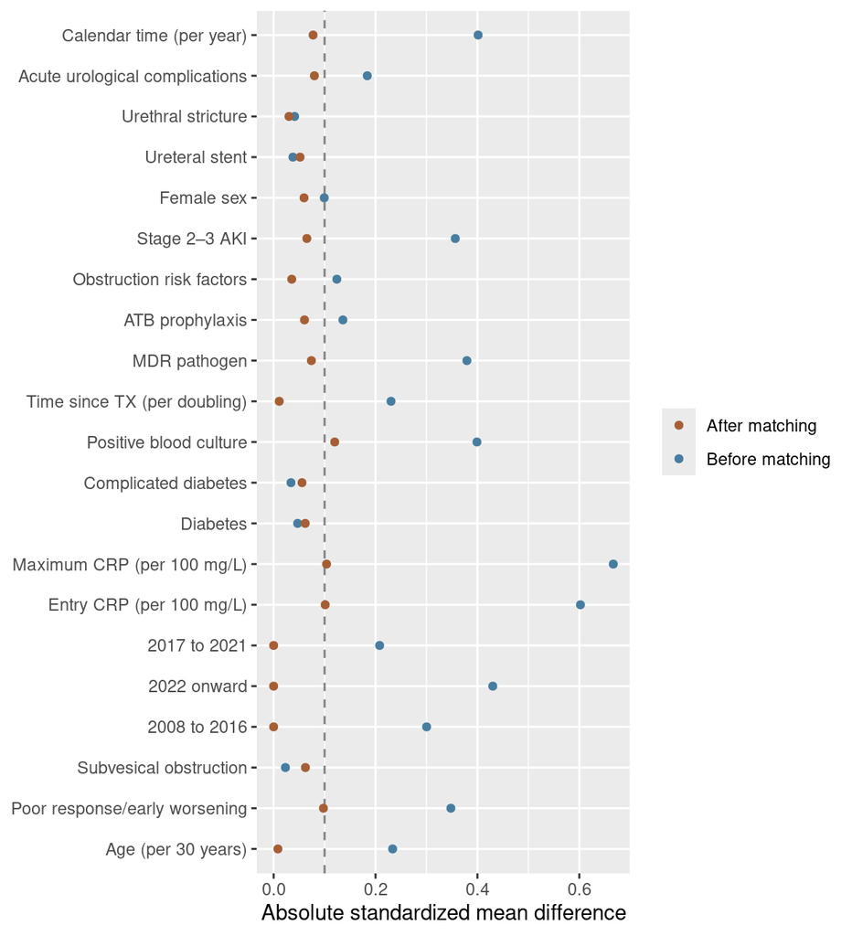

```r
relapse_balance_all <- summary(
  match_relapse,
  standardize = TRUE
)

relapse_before_all <- as.data.frame(
  relapse_balance_all$sum.all,
  check.names = FALSE
) |>
  tibble::rownames_to_column("covariate") |>
  janitor::clean_names() |>
  dplyr::mutate(stage = "Before matching") |>
  data.frame()

relapse_after_all <- as.data.frame(
  relapse_balance_all$sum.matched,
  check.names = FALSE
) |>
  tibble::rownames_to_column("covariate") |>
  janitor::clean_names() |>
  dplyr::mutate(stage = "After matching") |>
  data.frame()

relapse_balance_plot_all <- dplyr::bind_rows(
  relapse_before_all,
  relapse_after_all
) |>
  dplyr::filter(covariate != "distance") |>
  data.frame()

myplot <- ggplot(
  relapse_balance_plot_all,
  aes(abs(std_mean_diff), covariate, colour = stage)
) +
  geom_vline(xintercept = 0.1, linetype = "dashed", colour = "grey50") +
  geom_point() +
  scale_y_discrete(labels = function(x) {
    dplyr::coalesce(unname(plot_labels_dict[x]), x)
  }) +
  scale_colour_manual(values = c("#A65F35", "#477DA0")) +
  labs(x = "Absolute standardized mean difference", y = NULL,
       colour = NULL)

plotac <- "fig_x21"
myplot <- save_plot(myplot, plotac, width = 6.1, height = 6.7)
myplot
```

### 6.6.2 Relapse frequencies

Show relapse counts and proportions in the matched groups.

**Open code**

```r
relapse_counts_all <- matched_relapse |>
  dplyr::group_by(treatment_group) |>
  dplyr::summarise(
    patients = dplyr::n(),
    known_outcome = sum(!is.na(relapse_30D)),
    unknown_outcome = sum(is.na(relapse_30D)),
    relapses = sum(relapse_30D == 1, na.rm = TRUE),
    .groups = "drop"
  ) |>
  dplyr::mutate(
    relapse_percent = 100 * relapses / known_outcome
  ) |>
  data.frame()

kableExtra::kable(
  relapse_counts_all,
  digits = 1,
  caption = "All years. Relapse within 30 days after therapy completion by sensitivity ATB duration in the matched cohort. patients counts matched patients; known_outcome and unknown_outcome count available and missing relapse outcomes; relapses counts events; relapse_percent is the percentage with relapse among patients with known outcomes"
)
```

All years. Relapse within 30 days after therapy completion by sensitivity ATB duration in the matched cohort. patients counts matched patients; known_outcome and unknown_outcome count available and missing relapse outcomes; relapses counts events; relapse_percent is the percentage with relapse among patients with known outcomes

| treatment_group | patients | known_outcome | unknown_outcome | relapses | relapse_percent |
| --- | --- | --- | --- | --- | --- |
| <=13 days | 135 | 135 | 0 | 27 | 20.0 |
| >13 days | 135 | 135 | 0 | 32 | 23.7 |

### 6.6.3 KM relapse

Estimate relapse-free survival through day 90 and HRs separately for 30 and 90 days

Patients without relapse are administratively censored at the respective follow-up limit. As in the preceding relapse analysis, a recorded recurrence with a discordant pathogen is not counted as relapse and does not trigger censoring. This uses the recorded recurrent episode and does not reconstruct subsequent infections.

**Open code**

```r
matched_relapse_survival_all <- matched_relapse |>
  dplyr::mutate(
    relapse_group = factor(
      treatment_under14D,
      levels = c(0, 1),
      labels = c("Long (>13 days)", "Short (<=13 days)")
    ),
    relapse_90D = dplyr::case_when(
      recurence_till_90D == 0 ~ 0,
      recurence_till_90D == 1 & hemoculture_agreed == 1 ~ 1,
      recurence_till_90D == 1 & hemoculture_agreed == 0 ~ 0,
      TRUE ~ NA_real_
    ),
    relapse_time_30D = dplyr::case_when(
      relapse_30D == 1 ~
        as.numeric(Infection_to90D_day - EndDate_therapy),
      relapse_30D == 0 ~ 30,
      TRUE ~ NA_real_
    ),
    relapse_time_90D = dplyr::case_when(
      relapse_90D == 1 ~
        as.numeric(Infection_to90D_day - EndDate_therapy),
      relapse_90D == 0 ~ 90,
      TRUE ~ NA_real_
    )
  ) |>
  data.frame()

km_relapse_90D_all <- survfit(
  Surv(relapse_time_90D, relapse_90D) ~ relapse_group,
  data = matched_relapse_survival_all,
  conf.type = "log-log"
)
```

#### 6.6.3.1 HR, 30D and 90D

Fit each model separately. The 90-day estimate covers the entire period from day 0 to day 90, not only days 31–90.

**Open code**

```r
m_cox_relapse_30D_all <- coxph(
  Surv(relapse_time_30D, relapse_30D) ~ treatment_under14D,
  data = matched_relapse_survival_all,
  cluster = subclass
)

m_cox_relapse_90D_all <- coxph(
  Surv(relapse_time_90D, relapse_90D) ~ treatment_under14D,
  data = matched_relapse_survival_all,
  cluster = subclass
)

relapse_cox_summary_30D_all <- summary(m_cox_relapse_30D_all)
relapse_cox_summary_90D_all <- summary(m_cox_relapse_90D_all)

relapse_hr_30D_all <- data.frame(
  window = "0–30 days",
  comparison = "<=13 versus >13 days",
  n = m_cox_relapse_30D_all$n,
  events = m_cox_relapse_30D_all$nevent,
  HR = relapse_cox_summary_30D_all$conf.int[, "exp(coef)"],
  lower = relapse_cox_summary_30D_all$conf.int[, "lower .95"],
  upper = relapse_cox_summary_30D_all$conf.int[, "upper .95"],
  p_value = relapse_cox_summary_30D_all$coefficients[, "Pr(>|z|)"],
  row.names = NULL
)

relapse_hr_90D_all <- data.frame(
  window = "0–90 days",
  comparison = "<=13 versus >13 days",
  n = m_cox_relapse_90D_all$n,
  events = m_cox_relapse_90D_all$nevent,
  HR = relapse_cox_summary_90D_all$conf.int[, "exp(coef)"],
  lower = relapse_cox_summary_90D_all$conf.int[, "lower .95"],
  upper = relapse_cox_summary_90D_all$conf.int[, "upper .95"],
  p_value = relapse_cox_summary_90D_all$coefficients[, "Pr(>|z|)"],
  row.names = NULL
)

relapse_hr_table_all <- dplyr::bind_rows(
  relapse_hr_30D_all,
  relapse_hr_90D_all
) |>
  data.frame()

kableExtra::kable(
  relapse_hr_table_all,
  digits = 3,
  caption = "All years. Relapse within 30 and 90 days after therapy completion in the matched cohort with an identified initial pathogen. Separate Cox proportional hazards models included treatment group as the sole predictor, with robust variance clustered by matched pair. window identifies the period analysed; comparison gives the direction of the treatment contrast. HR states how many times the relapse hazard changes from >13 to <=13 days of sensitivity ATB treatment; HR >1 indicates a higher hazard with shorter treatment. n is the number analysed; events counts relapses; lower and upper are robust Wald 95% confidence limits; p_value is the two-sided robust Wald p-value. The 30-day analysis is primary and the 90-day analysis secondary; p-values are not adjusted for multiple testing"
)
```

All years. Relapse within 30 and 90 days after therapy completion in the matched cohort with an identified initial pathogen. Separate Cox proportional hazards models included treatment group as the sole predictor, with robust variance clustered by matched pair. window identifies the period analysed; comparison gives the direction of the treatment contrast. HR states how many times the relapse hazard changes from >13 to <=13 days of sensitivity ATB treatment; HR >1 indicates a higher hazard with shorter treatment. n is the number analysed; events counts relapses; lower and upper are robust Wald 95% confidence limits; p_value is the two-sided robust Wald p-value. The 30-day analysis is primary and the 90-day analysis secondary; p-values are not adjusted for multiple testing

| window | comparison | n | events | HR | lower | upper | p_value |
| --- | --- | --- | --- | --- | --- | --- | --- |
| 0–30 days | <=13 versus >13 days | 270 | 59 | 0.818 | 0.493 | 1.356 | 0.436 |
| 0–90 days | <=13 versus >13 days | 270 | 74 | 0.915 | 0.584 | 1.434 | 0.700 |

#### 6.6.3.2 Pair-stratified log-rank test

Compare the survival curves over the full 90-day follow-up using a log-rank test stratified by matched pair.

**Open code**

```r
logrank_relapse_90D_all <- survdiff(
  Surv(relapse_time_90D, relapse_90D) ~
    relapse_group +
    strata(subclass),
  data = matched_relapse_survival_all,
  rho = 0
)

relapse_logrank_p_all <- pchisq(
  logrank_relapse_90D_all$chisq,
  df = 1,
  lower.tail = FALSE
)

relapse_logrank_table_all <- data.frame(
  n = sum(logrank_relapse_90D_all$n),
  events = sum(logrank_relapse_90D_all$obs),
  chi_squared = logrank_relapse_90D_all$chisq,
  df = 1,
  p_value = relapse_logrank_p_all
)

kableExtra::kable(
  relapse_logrank_table_all,
  digits = 3,
  caption = "All years. Comparison of relapse-free survival through 90 days after therapy completion using a log-rank test stratified by matched pair. n is the number analysed; events counts relapses; chi_squared is the test statistic; df is its degrees of freedom; p_value tests equality of the survival curves and is distinct from the Cox model Wald p-values"
)
```

All years. Comparison of relapse-free survival through 90 days after therapy completion using a log-rank test stratified by matched pair. n is the number analysed; events counts relapses; chi_squared is the test statistic; df is its degrees of freedom; p_value tests equality of the survival curves and is distinct from the Cox model Wald p-values

| n | events | chi_squared | df | p_value |
| --- | --- | --- | --- | --- |
| 270 | 74 | 0.016 | 1 | 0.9 |

#### 6.6.3.3 Post-hoc comparisons at days 30 and 90

Compare relapse proportions within matched pairs at both follow-up times.

**Open code**

```r
relapse_pairs_all <- matched_relapse_survival_all |>
  dplyr::transmute(
    subclass,
    treatment = dplyr::if_else(
      treatment_under14D == 1, "short", "long"
    ),
    relapse_30D,
    relapse_90D
  ) |>
  tidyr::pivot_longer(
    cols = c(relapse_30D, relapse_90D),
    names_to = "outcome",
    values_to = "event"
  ) |>
  dplyr::mutate(
    day = dplyr::if_else(outcome == "relapse_30D", 30, 90)
  ) |>
  dplyr::select(-outcome) |>
  tidyr::pivot_wider(
    names_from = treatment,
    values_from = event
  ) |>
  data.frame()

relapse_posthoc_all <- relapse_pairs_all |>
  dplyr::group_by(day) |>
  dplyr::summarise(
    pairs = sum(!is.na(short) & !is.na(long)),
    incomplete_pairs = sum(is.na(short) | is.na(long)),
    short_only = sum(short == 1 & long == 0, na.rm = TRUE),
    long_only = sum(short == 0 & long == 1, na.rm = TRUE),
    .groups = "drop"
  ) |>
  dplyr::rowwise() |>
  dplyr::mutate(
    p_value = if (pairs == 0) {
      NA_real_
    } else if (short_only + long_only == 0) {
      1
    } else {
      binom.test(
        short_only,
        short_only + long_only,
        p = 0.5,
        alternative = "two.sided"
      )$p.value
    }
  ) |>
  dplyr::ungroup() |>
  dplyr::mutate(
    p_holm = p.adjust(p_value, method = "holm", n = 2)
  ) |>
  dplyr::arrange(day) |>
  data.frame()

kableExtra::kable(
  relapse_posthoc_all,
  digits = 3,
  caption = "All years. Post-hoc comparisons of relapse within 30 and 90 days after therapy completion in the matched cohort. day is the follow-up limit; pairs counts matched pairs with both outcomes known; incomplete_pairs counts pairs not used in that comparison because at least one outcome is missing. short_only and long_only count pairs with relapse only in the patient treated for <=13 or >13 days, respectively. p_value is the two-sided exact McNemar p-value; p_holm applies Holm adjustment across the two comparisons"
)
```

All years. Post-hoc comparisons of relapse within 30 and 90 days after therapy completion in the matched cohort. day is the follow-up limit; pairs counts matched pairs with both outcomes known; incomplete_pairs counts pairs not used in that comparison because at least one outcome is missing. short_only and long_only count pairs with relapse only in the patient treated for <=13 or >13 days, respectively. p_value is the two-sided exact McNemar p-value; p_holm applies Holm adjustment across the two comparisons

| day | pairs | incomplete_pairs | short_only | long_only | p_value | p_holm |
| --- | --- | --- | --- | --- | --- | --- |
| 30 | 135 | 0 | 20 | 25 | 0.551 | 1 |
| 90 | 135 | 0 | 25 | 27 | 0.890 | 1 |

#### 6.6.3.4 Survival curves

**Open code**

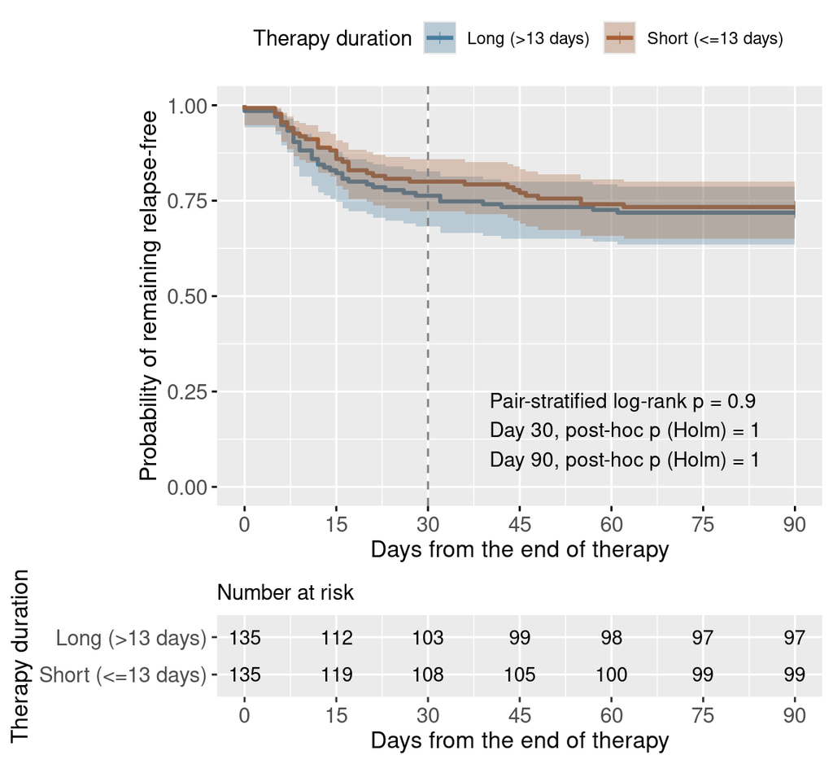

Figure 22. All years. Relapse-free survival through 90 days after therapy completion in propensity-score-matched patients with an identified initial pathogen. Relapse requires recurrence with concordant pathogens. Curves are Kaplan–Meier estimates; shaded regions show pointwise 95% confidence intervals based on Greenwood variance with a log-log transformation. Tick marks indicate censoring, the vertical dashed line marks day 30, and the table shows numbers at risk. The overall p-value is from a log-rank test stratified by matched pair over 90 days; post-hoc p-values compare relapse proportions by days 30 and 90 using two-sided exact McNemar tests with Holm adjustment across these two comparisons. Therapy duration denotes days of treatment with an antibiotic to which the isolated organism was susceptible in vitro

```r
relapse_p_text_all <- paste0(
  "Pair-stratified log-rank p = ",
  format.pval(relapse_logrank_p_all, digits = 3, eps = 0),
  "\nDay 30, post-hoc p (Holm) = ",
  format.pval(
    relapse_posthoc_all$p_holm[relapse_posthoc_all$day == 30],
    digits = 3,
    eps = 0
  ),
  "\nDay 90, post-hoc p (Holm) = ",
  format.pval(
    relapse_posthoc_all$p_holm[relapse_posthoc_all$day == 90],
    digits = 3,
    eps = 0
  )
)

myplot <- survminer::ggsurvplot(
  km_relapse_90D_all,
  data = matched_relapse_survival_all,
  pval = relapse_p_text_all,
  pval.coord = c(40, 0.15),
  pval.size = 3.7,
  conf.int = TRUE,
  risk.table = TRUE,
  risk.table.y.text.col = FALSE,
  risk.table.fontsize = 3.6,
  censor.shape = 124,
  censor.size = 2,
  palette = c("#477DA0", "#A65F35"),
  xlab = "Days from the end of therapy",
  ylab = "Probability of remaining relapse-free",
  legend.title = "Therapy duration",
  legend.labs = c("Long (>13 days)", "Short (<=13 days)"),
  break.time.by = 15,
  xlim = c(0, 90),
  ggtheme = theme_grey()
)

myplot$plot <- myplot$plot +
  theme(
    plot.title = element_text(size = 12),
    axis.title.x = element_text(size = 12),
    axis.title.y = element_text(size = 12),
    axis.text.x = element_text(size = 11),
    axis.text.y = element_text(size = 11)
  ) +
  geom_vline(
    xintercept = 30,
    linetype = "dashed",
    colour = "grey50"
  )

myplot$table <- myplot$table +
  theme(
    plot.title = element_text(size = 11),
    axis.title.x = element_text(size = 12),
    axis.title.y = element_text(size = 12),
    axis.text.x = element_text(size = 11),
    axis.text.y = element_text(size = 11)
  )

myplot <- cowplot::plot_grid(
  myplot$plot,
  myplot$table + theme(legend.position = "none"),
  ncol = 1,
  rel_heights = c(0.75, 0.25),
  align = "v",
  axis = "lr"
)

plotac <- "fig_x22_relapse_survival_90D_all"
myplot <- save_plot(myplot, plotac, width = 6, height = 5.5)
myplot
```

#### 6.6.3.5 HR

**Open code**

```r
relapse_hr_table_all <- dplyr::bind_rows(
  relapse_hr_30D_all,
  relapse_hr_90D_all
) |>
  data.frame()

kableExtra::kable(
  relapse_hr_table_all,
  digits = 3,
  caption = "All years. Relapse hazard ratios from separate treatment-only Cox models covering days 0–30 and 0–90 after therapy completion, with robust variance clustered by matched pair. window identifies the follow-up interval; comparison specifies the treatment contrast. HR states how many times the relapse hazard changes from >13 to <=13 days of sensitivity ATB therapy; HR >1 indicates higher hazard with shorter treatment. n is the number of patients analysed; events counts relapses; lower and upper are the robust Wald 95% confidence limits; p_value is the two-sided robust Wald p-value without multiplicity adjustment"
)
```

All years. Relapse hazard ratios from separate treatment-only Cox models covering days 0–30 and 0–90 after therapy completion, with robust variance clustered by matched pair. window identifies the follow-up interval; comparison specifies the treatment contrast. HR states how many times the relapse hazard changes from >13 to <=13 days of sensitivity ATB therapy; HR >1 indicates higher hazard with shorter treatment. n is the number of patients analysed; events counts relapses; lower and upper are the robust Wald 95% confidence limits; p_value is the two-sided robust Wald p-value without multiplicity adjustment

| window | comparison | n | events | HR | lower | upper | p_value |
| --- | --- | --- | --- | --- | --- | --- | --- |
| 0–30 days | <=13 versus >13 days | 270 | 59 | 0.818 | 0.493 | 1.356 | 0.436 |
| 0–90 days | <=13 versus >13 days | 270 | 74 | 0.915 | 0.584 | 1.434 | 0.700 |

## 6.7 Relapse after matching, 2017+

### 6.7.1 Balance, 2017+

Check balance

**Open code**

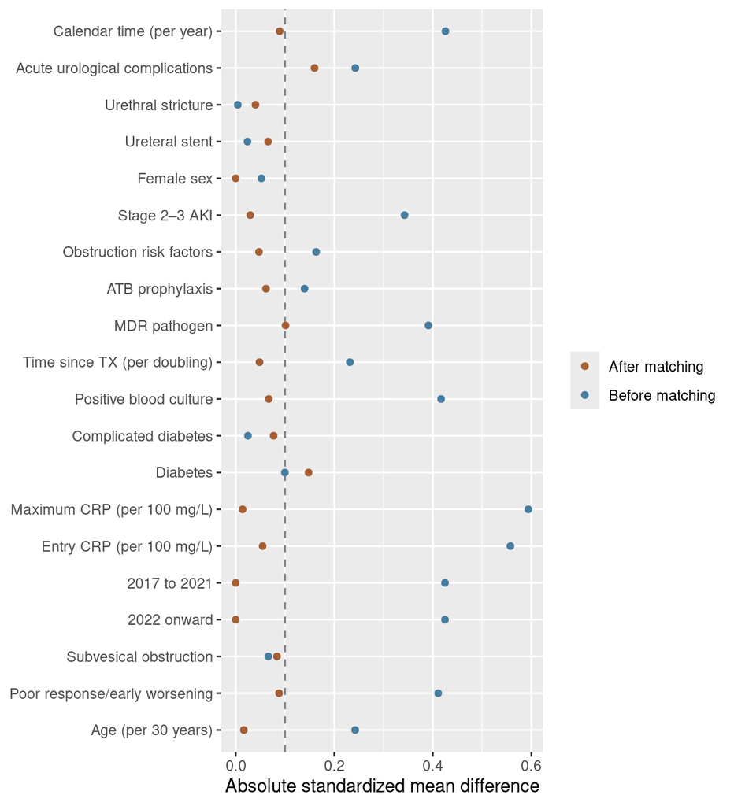

Figure 23. 2017+. Covariate balance before and after matching. Points show absolute standardized mean differences, standardized by the pre-matching short-treatment group in the displayed cohort; colours distinguish before and after matching. The dashed line marks 0.1. Original all-years matching weights are retained; no rematching is performed. TX denotes transplantation, MDR multidrug resistance, ATB antibiotics and AKI acute kidney injury. Obstruction risk factors is the umbrella category; subvesical obstruction includes urethral stricture. Ureteral stent denotes a stent in situ at discharge

```r
relapse_keep_2017 <- relapse_data$calendar_year >= 2017
match_relapse_balance_2017 <- match_relapse
match_relapse_balance_2017$X <- match_relapse$X[
  relapse_keep_2017, , drop = FALSE
]
match_relapse_balance_2017$treat <- match_relapse$treat[
  relapse_keep_2017
]
match_relapse_balance_2017$weights <- match_relapse$weights[
  relapse_keep_2017
]
match_relapse_balance_2017$distance <- match_relapse$distance[
  relapse_keep_2017
]
match_relapse_balance_2017$discarded <- match_relapse$discarded[
  relapse_keep_2017
]
match_relapse_balance_2017$subclass <- match_relapse$subclass[
  relapse_keep_2017
]
match_relapse_balance_2017$match.matrix <- match_relapse$match.matrix[
  rownames(match_relapse$match.matrix) %in%
    names(match_relapse_balance_2017$treat), , drop = FALSE
]

relapse_balance_2017 <- summary(
  match_relapse_balance_2017,
  standardize = TRUE
)

relapse_before_2017 <- as.data.frame(
  relapse_balance_2017$sum.all,
  check.names = FALSE
) |>
  tibble::rownames_to_column("covariate") |>
  janitor::clean_names() |>
  dplyr::mutate(stage = "Before matching") |>
  data.frame()

relapse_after_2017 <- as.data.frame(
  relapse_balance_2017$sum.matched,
  check.names = FALSE
) |>
  tibble::rownames_to_column("covariate") |>
  janitor::clean_names() |>
  dplyr::mutate(stage = "After matching") |>
  data.frame()

relapse_balance_plot_2017 <- dplyr::bind_rows(
  relapse_before_2017,
  relapse_after_2017
) |>
  dplyr::filter(covariate != "distance") |>
  data.frame()

myplot <- ggplot(
  relapse_balance_plot_2017,
  aes(abs(std_mean_diff), covariate, colour = stage)
) +
  geom_vline(xintercept = 0.1, linetype = "dashed", colour = "grey50") +
  geom_point() +
  scale_y_discrete(labels = function(x) {
    dplyr::coalesce(unname(plot_labels_dict[x]), x)
  }) +
  scale_colour_manual(values = c("#A65F35", "#477DA0")) +
  labs(x = "Absolute standardized mean difference", y = NULL,
       colour = NULL)

plotac <- "fig_x23_relapse_2017plus"
myplot <- save_plot(myplot, plotac, width = 6.1, height = 6.7)
myplot
```

### 6.7.2 Relapse frequencies

Show relapse counts and proportions in the matched groups.

**Open code**

```r
relapse_counts_2017 <- matched_relapse_2017 |>
  dplyr::group_by(treatment_group) |>
  dplyr::summarise(
    patients = dplyr::n(),
    known_outcome = sum(!is.na(relapse_30D)),
    unknown_outcome = sum(is.na(relapse_30D)),
    relapses = sum(relapse_30D == 1, na.rm = TRUE),
    .groups = "drop"
  ) |>
  dplyr::mutate(
    relapse_percent = 100 * relapses / known_outcome
  ) |>
  data.frame()

kableExtra::kable(
  relapse_counts_2017,
  digits = 1,
  caption = "2017+. Relapse within 30 days after therapy completion by sensitivity ATB duration in the matched cohort. patients counts matched patients; known_outcome and unknown_outcome count available and missing relapse outcomes; relapses counts events; relapse_percent is the percentage with relapse among patients with known outcomes"
)
```

2017+. Relapse within 30 days after therapy completion by sensitivity ATB duration in the matched cohort. patients counts matched patients; known_outcome and unknown_outcome count available and missing relapse outcomes; relapses counts events; relapse_percent is the percentage with relapse among patients with known outcomes

| treatment_group | patients | known_outcome | unknown_outcome | relapses | relapse_percent |
| --- | --- | --- | --- | --- | --- |
| <=13 days | 99 | 99 | 0 | 23 | 23.2 |
| >13 days | 99 | 99 | 0 | 26 | 26.3 |

### 6.7.3 KM relapse

Estimate relapse-free survival through day 90 and HRs separately for 30 and 90 days

Patients without relapse are administratively censored at the respective follow-up limit. As in the preceding relapse analysis, a recorded recurrence with a discordant pathogen is not counted as relapse and does not trigger censoring. This uses the recorded recurrent episode and does not reconstruct subsequent infections.

**Open code**

```r
matched_relapse_survival_2017 <- matched_relapse_2017 |>
  dplyr::mutate(
    relapse_group = factor(
      treatment_under14D,
      levels = c(0, 1),
      labels = c("Long (>13 days)", "Short (<=13 days)")
    ),
    relapse_90D = dplyr::case_when(
      recurence_till_90D == 0 ~ 0,
      recurence_till_90D == 1 & hemoculture_agreed == 1 ~ 1,
      recurence_till_90D == 1 & hemoculture_agreed == 0 ~ 0,
      TRUE ~ NA_real_
    ),
    relapse_time_30D = dplyr::case_when(
      relapse_30D == 1 ~
        as.numeric(Infection_to90D_day - EndDate_therapy),
      relapse_30D == 0 ~ 30,
      TRUE ~ NA_real_
    ),
    relapse_time_90D = dplyr::case_when(
      relapse_90D == 1 ~
        as.numeric(Infection_to90D_day - EndDate_therapy),
      relapse_90D == 0 ~ 90,
      TRUE ~ NA_real_
    )
  ) |>
  data.frame()

km_relapse_90D_2017 <- survfit(
  Surv(relapse_time_90D, relapse_90D) ~ relapse_group,
  data = matched_relapse_survival_2017,
  conf.type = "log-log"
)
```

#### 6.7.3.1 HR, 30D and 90D

Fit each model separately. The 90-day estimate covers the entire period from day 0 to day 90, not only days 31–90.

**Open code**

```r
m_cox_relapse_30D_2017 <- coxph(
  Surv(relapse_time_30D, relapse_30D) ~ treatment_under14D,
  data = matched_relapse_survival_2017,
  cluster = subclass
)

m_cox_relapse_90D_2017 <- coxph(
  Surv(relapse_time_90D, relapse_90D) ~ treatment_under14D,
  data = matched_relapse_survival_2017,
  cluster = subclass
)

relapse_cox_summary_30D_2017 <- summary(m_cox_relapse_30D_2017)
relapse_cox_summary_90D_2017 <- summary(m_cox_relapse_90D_2017)

relapse_hr_30D_2017 <- data.frame(
  window = "0–30 days",
  comparison = "<=13 versus >13 days",
  n = m_cox_relapse_30D_2017$n,
  events = m_cox_relapse_30D_2017$nevent,
  HR = relapse_cox_summary_30D_2017$conf.int[, "exp(coef)"],
  lower = relapse_cox_summary_30D_2017$conf.int[, "lower .95"],
  upper = relapse_cox_summary_30D_2017$conf.int[, "upper .95"],
  p_value = relapse_cox_summary_30D_2017$coefficients[, "Pr(>|z|)"],
  row.names = NULL
)

relapse_hr_90D_2017 <- data.frame(
  window = "0–90 days",
  comparison = "<=13 versus >13 days",
  n = m_cox_relapse_90D_2017$n,
  events = m_cox_relapse_90D_2017$nevent,
  HR = relapse_cox_summary_90D_2017$conf.int[, "exp(coef)"],
  lower = relapse_cox_summary_90D_2017$conf.int[, "lower .95"],
  upper = relapse_cox_summary_90D_2017$conf.int[, "upper .95"],
  p_value = relapse_cox_summary_90D_2017$coefficients[, "Pr(>|z|)"],
  row.names = NULL
)

relapse_hr_table_2017 <- dplyr::bind_rows(
  relapse_hr_30D_2017,
  relapse_hr_90D_2017
) |>
  data.frame()

kableExtra::kable(
  relapse_hr_table_2017,
  digits = 3,
  caption = "2017+. Relapse within 30 and 90 days after therapy completion in the matched cohort with an identified initial pathogen. Separate Cox proportional hazards models included treatment group as the sole predictor, with robust variance clustered by matched pair. window identifies the period analysed; comparison gives the direction of the treatment contrast. HR states how many times the relapse hazard changes from >13 to <=13 days of sensitivity ATB treatment; HR >1 indicates a higher hazard with shorter treatment. n is the number analysed; events counts relapses; lower and upper are robust Wald 95% confidence limits; p_value is the two-sided robust Wald p-value. The 30-day analysis is primary and the 90-day analysis secondary; p-values are not adjusted for multiple testing"
)
```

2017+. Relapse within 30 and 90 days after therapy completion in the matched cohort with an identified initial pathogen. Separate Cox proportional hazards models included treatment group as the sole predictor, with robust variance clustered by matched pair. window identifies the period analysed; comparison gives the direction of the treatment contrast. HR states how many times the relapse hazard changes from >13 to <=13 days of sensitivity ATB treatment; HR >1 indicates a higher hazard with shorter treatment. n is the number analysed; events counts relapses; lower and upper are robust Wald 95% confidence limits; p_value is the two-sided robust Wald p-value. The 30-day analysis is primary and the 90-day analysis secondary; p-values are not adjusted for multiple testing

| window | comparison | n | events | HR | lower | upper | p_value |
| --- | --- | --- | --- | --- | --- | --- | --- |
| 0–30 days | <=13 versus >13 days | 198 | 49 | 0.858 | 0.490 | 1.502 | 0.592 |
| 0–90 days | <=13 versus >13 days | 198 | 59 | 1.007 | 0.606 | 1.673 | 0.979 |

#### 6.7.3.2 Pair-stratified log-rank test

Compare the survival curves over the full 90-day follow-up using a log-rank test stratified by matched pair.

**Open code**

```r
logrank_relapse_90D_2017 <- survdiff(
  Surv(relapse_time_90D, relapse_90D) ~
    relapse_group +
    strata(subclass),
  data = matched_relapse_survival_2017,
  rho = 0
)

relapse_logrank_p_2017 <- pchisq(
  logrank_relapse_90D_2017$chisq,
  df = 1,
  lower.tail = FALSE
)

relapse_logrank_table_2017 <- data.frame(
  n = sum(logrank_relapse_90D_2017$n),
  events = sum(logrank_relapse_90D_2017$obs),
  chi_squared = logrank_relapse_90D_2017$chisq,
  df = 1,
  p_value = relapse_logrank_p_2017
)

kableExtra::kable(
  relapse_logrank_table_2017,
  digits = 3,
  caption = "2017+. Comparison of relapse-free survival through 90 days after therapy completion using a log-rank test stratified by matched pair. n is the number analysed; events counts relapses; chi_squared is the test statistic; df is its degrees of freedom; p_value tests equality of the survival curves and is distinct from the Cox model Wald p-values"
)
```

2017+. Comparison of relapse-free survival through 90 days after therapy completion using a log-rank test stratified by matched pair. n is the number analysed; events counts relapses; chi_squared is the test statistic; df is its degrees of freedom; p_value tests equality of the survival curves and is distinct from the Cox model Wald p-values

| n | events | chi_squared | df | p_value |
| --- | --- | --- | --- | --- |
| 198 | 59 | 0.08 | 1 | 0.777 |

#### 6.7.3.3 Post-hoc comparisons at days 30 and 90

**Open code**

```r
relapse_pairs_2017 <- matched_relapse_survival_2017 |>
  dplyr::transmute(
    subclass,
    treatment = dplyr::if_else(
      treatment_under14D == 1, "short", "long"
    ),
    relapse_30D,
    relapse_90D
  ) |>
  tidyr::pivot_longer(
    cols = c(relapse_30D, relapse_90D),
    names_to = "outcome",
    values_to = "event"
  ) |>
  dplyr::mutate(
    day = dplyr::if_else(outcome == "relapse_30D", 30, 90)
  ) |>
  dplyr::select(-outcome) |>
  tidyr::pivot_wider(
    names_from = treatment,
    values_from = event
  ) |>
  data.frame()

relapse_posthoc_2017 <- relapse_pairs_2017 |>
  dplyr::group_by(day) |>
  dplyr::summarise(
    pairs = sum(!is.na(short) & !is.na(long)),
    incomplete_pairs = sum(is.na(short) | is.na(long)),
    short_only = sum(short == 1 & long == 0, na.rm = TRUE),
    long_only = sum(short == 0 & long == 1, na.rm = TRUE),
    .groups = "drop"
  ) |>
  dplyr::rowwise() |>
  dplyr::mutate(
    p_value = if (pairs == 0) {
      NA_real_
    } else if (short_only + long_only == 0) {
      1
    } else {
      binom.test(
        short_only,
        short_only + long_only,
        p = 0.5,
        alternative = "two.sided"
      )$p.value
    }
  ) |>
  dplyr::ungroup() |>
  dplyr::mutate(
    p_holm = p.adjust(p_value, method = "holm", n = 2)
  ) |>
  dplyr::arrange(day) |>
  data.frame()

kableExtra::kable(
  relapse_posthoc_2017,
  digits = 3,
  caption = "2017+. Post-hoc comparisons of relapse within 30 and 90 days after therapy completion in the matched cohort. day is the follow-up limit; pairs counts matched pairs with both outcomes known; incomplete_pairs counts pairs not used in that comparison because at least one outcome is missing. short_only and long_only count pairs with relapse only in the patient treated for <=13 or >13 days, respectively. p_value is the two-sided exact McNemar p-value; p_holm applies Holm adjustment across the two comparisons"
)
```

2017+. Post-hoc comparisons of relapse within 30 and 90 days after therapy completion in the matched cohort. day is the follow-up limit; pairs counts matched pairs with both outcomes known; incomplete_pairs counts pairs not used in that comparison because at least one outcome is missing. short_only and long_only count pairs with relapse only in the patient treated for <=13 or >13 days, respectively. p_value is the two-sided exact McNemar p-value; p_holm applies Holm adjustment across the two comparisons

| day | pairs | incomplete_pairs | short_only | long_only | p_value | p_holm |
| --- | --- | --- | --- | --- | --- | --- |
| 30 | 99 | 0 | 17 | 20 | 0.743 | 1 |
| 90 | 99 | 0 | 21 | 20 | 1.000 | 1 |

#### 6.7.3.4 Survival curves

**Open code**

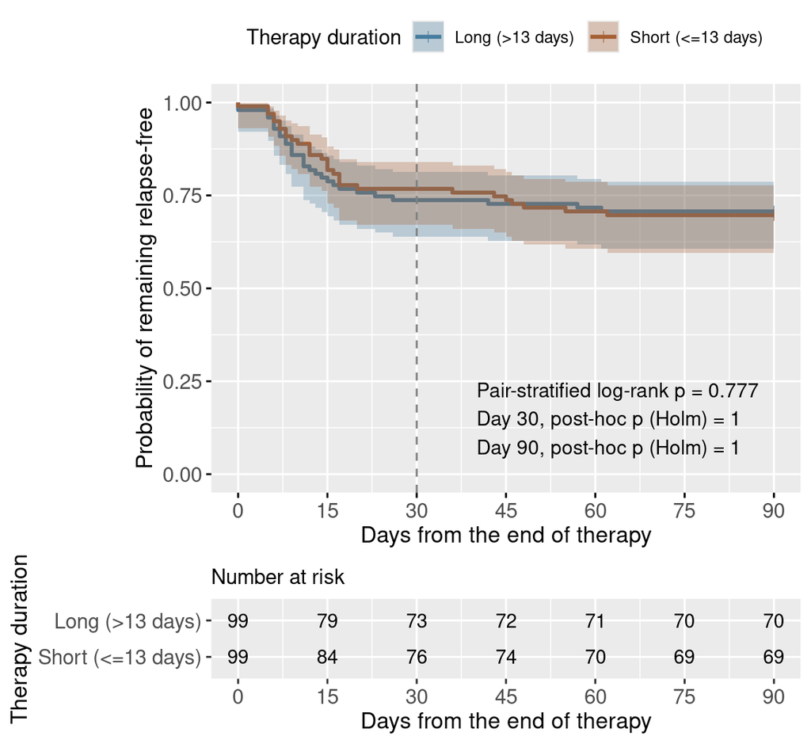

Figure 24. 2017+. Relapse-free survival through 90 days after therapy completion in propensity-score-matched patients with an identified initial pathogen. Relapse requires recurrence with concordant pathogens. Curves are Kaplan–Meier estimates; shaded regions show pointwise 95% confidence intervals based on Greenwood variance with a log-log transformation. Tick marks indicate censoring, the vertical dashed line marks day 30, and the table shows numbers at risk. The overall p-value is from a log-rank test stratified by matched pair over 90 days; post-hoc p-values compare relapse proportions by days 30 and 90 using two-sided exact McNemar tests with Holm adjustment across these two comparisons. Therapy duration denotes days of treatment with an antibiotic to which the isolated organism was susceptible in vitro

```r
relapse_p_text_2017 <- paste0(
  "Pair-stratified log-rank p = ",
  format.pval(relapse_logrank_p_2017, digits = 3, eps = 0),
  "\nDay 30, post-hoc p (Holm) = ",
  format.pval(
    relapse_posthoc_2017$p_holm[relapse_posthoc_2017$day == 30],
    digits = 3,
    eps = 0
  ),
  "\nDay 90, post-hoc p (Holm) = ",
  format.pval(
    relapse_posthoc_2017$p_holm[relapse_posthoc_2017$day == 90],
    digits = 3,
    eps = 0
  )
)

myplot <- survminer::ggsurvplot(
  km_relapse_90D_2017,
  data = matched_relapse_survival_2017,
  pval = relapse_p_text_2017,
  pval.coord = c(40, 0.15),
  pval.size = 3.7,
  conf.int = TRUE,
  risk.table = TRUE,
  risk.table.y.text.col = FALSE,
  risk.table.fontsize = 3.6,
  censor.shape = 124,
  censor.size = 2,
  palette = c("#477DA0", "#A65F35"),
  xlab = "Days from the end of therapy",
  ylab = "Probability of remaining relapse-free",
  legend.title = "Therapy duration",
  legend.labs = c("Long (>13 days)", "Short (<=13 days)"),
  break.time.by = 15,
  xlim = c(0, 90),
  ggtheme = theme_grey()
)

myplot$plot <- myplot$plot +
  theme(
    plot.title = element_text(size = 12),
    axis.title.x = element_text(size = 12),
    axis.title.y = element_text(size = 12),
    axis.text.x = element_text(size = 11),
    axis.text.y = element_text(size = 11)
  ) +
  geom_vline(
    xintercept = 30,
    linetype = "dashed",
    colour = "grey50"
  )

myplot$table <- myplot$table +
  theme(
    plot.title = element_text(size = 11),
    axis.title.x = element_text(size = 12),
    axis.title.y = element_text(size = 12),
    axis.text.x = element_text(size = 11),
    axis.text.y = element_text(size = 11)
  )

myplot <- cowplot::plot_grid(
  myplot$plot,
  myplot$table + theme(legend.position = "none"),
  ncol = 1,
  rel_heights = c(0.75, 0.25),
  align = "v",
  axis = "lr"
)

plotac <- "fig_x24"
myplot <- save_plot(myplot, plotac, width = 6, height = 5.5)
myplot
```

# 7 Safety outcomes

Report patient proportions within 30 and 90 days after therapy completion in the full and primary matched cohorts, with the same analyses for 2017+. Events on or before therapy completion are excluded. Empty source entries retain the agreed coding of no event. An affirmative 90-day readmission entry without a date is counted at 90 days, but its 30-day status remains unknown. A recorded clostridial infection without a date cannot establish a post-treatment event and is reported as unknown. No dates are imputed.

## 7.1 Available timing

Show records that cannot be assigned to a post-treatment window. Dates on the final treatment day are shown separately because their within-day order is unknown.

**Open code**

```r
safety_timing <- data_analysis |>
  dplyr::summarise(
    clostridium_positive_without_date = sum(
      clostridium == 1 & is.na(ClostridiumDate), na.rm = TRUE
    ),
    uti_readmission_positive_without_date = sum(
      readmission_90d_uti == 1 & is.na(ReadmissionDate_uti),
      na.rm = TRUE
    ),
    other_readmission_positive_without_date = sum(
      readmission_90d_other == 1 & is.na(ReadmissionDate_other),
      na.rm = TRUE
    ),
    clostridium_on_final_treatment_day = sum(
      clostridium_days_after_therapy == 0, na.rm = TRUE
    ),
    clostridium_before_therapy_end = sum(
      clostridium_days_after_therapy < 0, na.rm = TRUE
    )
  ) |>
  tidyr::pivot_longer(
    dplyr::everything(),
    names_to = "timing_issue",
    values_to = "patients"
  ) |>
  data.frame()

kableExtra::kable(
  safety_timing,
  caption = "Safety timing. timing_issue identifies positive records without an event date or clostridial infections occurring on or before the final treatment day; patients counts affected records. These records are retained in the cohort, but unknown timing is not recoded as absence"
)
```

Safety timing. timing_issue identifies positive records without an event date or clostridial infections occurring on or before the final treatment day; patients counts affected records. These records are retained in the cohort, but unknown timing is not recoded as absence

| timing_issue | patients |
| --- | --- |
| clostridium_positive_without_date | 0 |
| uti_readmission_positive_without_date | 47 |
| other_readmission_positive_without_date | 25 |
| clostridium_on_final_treatment_day | 1 |
| clostridium_before_therapy_end | 12 |

## 7.2 Summary function

Use the same definitions and denominators in each cohort. Any readmission means at least one UTI-related or other recorded readmission, with each patient counted once.

**Open code**

```r
safety_labels <- c(
  clostridium_30D = "Clostridial infection, 30 days",
  clostridium_90D = "Clostridial infection, 90 days",
  readmission_uti_30D = "Readmission for UTI, 30 days",
  readmission_uti_90D = "Readmission for UTI, 90 days",
  readmission_other_30D = "Readmission for another reason, 30 days",
  readmission_other_90D = "Readmission for another reason, 90 days",
  readmission_any_30D = "Any readmission, 30 days",
  readmission_any_90D = "Any readmission, 90 days"
)

safety_table <- function(data) {
  data |>
    dplyr::select(
      treatment_group,
      dplyr::all_of(names(safety_labels))
    ) |>
    tidyr::pivot_longer(
      -treatment_group,
      names_to = "outcome",
      values_to = "event"
    ) |>
    dplyr::group_by(
      treatment_group,
      outcome
    ) |>
    dplyr::summarise(
      patients = dplyr::n(),
      known = sum(!is.na(event)),
      unknown = sum(is.na(event)),
      events = sum(event == 1, na.rm = TRUE),
      percent = 100 * events / known,
      .groups = "drop"
    ) |>
    dplyr::mutate(
      outcome = factor(
        outcome,
        levels = names(safety_labels),
        labels = unname(safety_labels)
      )
    ) |>
    dplyr::arrange(
      outcome,
      treatment_group
    ) |>
    data.frame()
}
```

## 7.3 Full cohort, all

Show safety outcomes in all analysed patients.

**Open code**

```r
safety_all <- safety_table(data_analysis)
kableExtra::kable(
  safety_all,
  digits = 1,
  caption = "Safety outcomes after therapy completion, full cohort. treatment_group compares sensitivity ATB duration <=13 with >13 days; outcome specifies the event and follow-up window. patients is the group size, known and unknown count assessable and unassessable outcomes, events is the number affected, and percent is 100 × events/known. These are patient proportions, not person-time incidence rates"
)
```

Safety outcomes after therapy completion, full cohort. treatment_group compares sensitivity ATB duration <=13 with >13 days; outcome specifies the event and follow-up window. patients is the group size, known and unknown count assessable and unassessable outcomes, events is the number affected, and percent is 100 × events/known. These are patient proportions, not person-time incidence rates

| treatment_group | outcome | patients | known | unknown | events | percent |
| --- | --- | --- | --- | --- | --- | --- |
| <=13 days | Clostridial infection, 30 days | 244 | 244 | 0 | 2 | 0.8 |
| >13 days | Clostridial infection, 30 days | 300 | 300 | 0 | 1 | 0.3 |
| <=13 days | Clostridial infection, 90 days | 244 | 244 | 0 | 3 | 1.2 |
| >13 days | Clostridial infection, 90 days | 300 | 300 | 0 | 2 | 0.7 |
| <=13 days | Readmission for UTI, 30 days | 244 | 224 | 20 | 37 | 16.5 |
| >13 days | Readmission for UTI, 30 days | 300 | 273 | 27 | 41 | 15.0 |
| <=13 days | Readmission for UTI, 90 days | 244 | 244 | 0 | 73 | 29.9 |
| >13 days | Readmission for UTI, 90 days | 300 | 300 | 0 | 82 | 27.3 |
| <=13 days | Readmission for another reason, 30 days | 244 | 233 | 11 | 12 | 5.2 |
| >13 days | Readmission for another reason, 30 days | 300 | 286 | 14 | 10 | 3.5 |
| <=13 days | Readmission for another reason, 90 days | 244 | 244 | 0 | 29 | 11.9 |
| >13 days | Readmission for another reason, 90 days | 300 | 300 | 0 | 30 | 10.0 |
| <=13 days | Any readmission, 30 days | 244 | 214 | 30 | 47 | 22.0 |
| >13 days | Any readmission, 30 days | 300 | 262 | 38 | 48 | 18.3 |
| <=13 days | Any readmission, 90 days | 244 | 244 | 0 | 94 | 38.5 |
| >13 days | Any readmission, 90 days | 300 | 300 | 0 | 105 | 35.0 |

## 7.4 Matched cohort, all

Show safety outcomes in the original 1:1 matched pairs.

**Open code**

```r
safety_matched_all <- safety_table(matched_data)
kableExtra::kable(
  safety_matched_all,
  digits = 1,
  caption = "Safety outcomes after therapy completion, primary matched cohort. treatment_group compares sensitivity ATB duration <=13 with >13 days; outcome specifies the event and follow-up window. patients is the group size, known and unknown count assessable and unassessable outcomes, events is the number affected, and percent is 100 × events/known. Original matched pairs are retained"
)
```

Safety outcomes after therapy completion, primary matched cohort. treatment_group compares sensitivity ATB duration <=13 with >13 days; outcome specifies the event and follow-up window. patients is the group size, known and unknown count assessable and unassessable outcomes, events is the number affected, and percent is 100 × events/known. Original matched pairs are retained

| treatment_group | outcome | patients | known | unknown | events | percent |
| --- | --- | --- | --- | --- | --- | --- |
| <=13 days | Clostridial infection, 30 days | 168 | 168 | 0 | 1 | 0.6 |
| >13 days | Clostridial infection, 30 days | 168 | 168 | 0 | 1 | 0.6 |
| <=13 days | Clostridial infection, 90 days | 168 | 168 | 0 | 2 | 1.2 |
| >13 days | Clostridial infection, 90 days | 168 | 168 | 0 | 2 | 1.2 |
| <=13 days | Readmission for UTI, 30 days | 168 | 153 | 15 | 20 | 13.1 |
| >13 days | Readmission for UTI, 30 days | 168 | 156 | 12 | 24 | 15.4 |
| <=13 days | Readmission for UTI, 90 days | 168 | 168 | 0 | 45 | 26.8 |
| >13 days | Readmission for UTI, 90 days | 168 | 168 | 0 | 44 | 26.2 |
| <=13 days | Readmission for another reason, 30 days | 168 | 157 | 11 | 8 | 5.1 |
| >13 days | Readmission for another reason, 30 days | 168 | 163 | 5 | 6 | 3.7 |
| <=13 days | Readmission for another reason, 90 days | 168 | 168 | 0 | 23 | 13.7 |
| >13 days | Readmission for another reason, 90 days | 168 | 168 | 0 | 14 | 8.3 |
| <=13 days | Any readmission, 30 days | 168 | 143 | 25 | 27 | 18.9 |
| >13 days | Any readmission, 30 days | 168 | 151 | 17 | 29 | 19.2 |
| <=13 days | Any readmission, 90 days | 168 | 168 | 0 | 61 | 36.3 |
| >13 days | Any readmission, 90 days | 168 | 168 | 0 | 56 | 33.3 |

## 7.5 Full cohort, 2017+

Show the same outcomes among patients treated from 2017 onward.

**Open code**

```r
safety_2017 <- safety_table(data_2017)
kableExtra::kable(
  safety_2017,
  digits = 1,
  caption = "Safety outcomes after therapy completion, full cohort treated from 2017 onward. treatment_group compares sensitivity ATB duration <=13 with >13 days; outcome specifies the event and follow-up window. patients is the group size, known and unknown count assessable and unassessable outcomes, events is the number affected, and percent is 100 × events/known"
)
```

Safety outcomes after therapy completion, full cohort treated from 2017 onward. treatment_group compares sensitivity ATB duration <=13 with >13 days; outcome specifies the event and follow-up window. patients is the group size, known and unknown count assessable and unassessable outcomes, events is the number affected, and percent is 100 × events/known

| treatment_group | outcome | patients | known | unknown | events | percent |
| --- | --- | --- | --- | --- | --- | --- |
| <=13 days | Clostridial infection, 30 days | 197 | 197 | 0 | 2 | 1.0 |
| >13 days | Clostridial infection, 30 days | 198 | 198 | 0 | 1 | 0.5 |
| <=13 days | Clostridial infection, 90 days | 197 | 197 | 0 | 3 | 1.5 |
| >13 days | Clostridial infection, 90 days | 198 | 198 | 0 | 2 | 1.0 |
| <=13 days | Readmission for UTI, 30 days | 197 | 180 | 17 | 34 | 18.9 |
| >13 days | Readmission for UTI, 30 days | 198 | 178 | 20 | 29 | 16.3 |
| <=13 days | Readmission for UTI, 90 days | 197 | 197 | 0 | 63 | 32.0 |
| >13 days | Readmission for UTI, 90 days | 198 | 198 | 0 | 60 | 30.3 |
| <=13 days | Readmission for another reason, 30 days | 197 | 190 | 7 | 10 | 5.3 |
| >13 days | Readmission for another reason, 30 days | 198 | 191 | 7 | 7 | 3.7 |
| <=13 days | Readmission for another reason, 90 days | 197 | 197 | 0 | 22 | 11.2 |
| >13 days | Readmission for another reason, 90 days | 198 | 198 | 0 | 19 | 9.6 |
| <=13 days | Any readmission, 30 days | 197 | 174 | 23 | 42 | 24.1 |
| >13 days | Any readmission, 30 days | 198 | 172 | 26 | 33 | 19.2 |
| <=13 days | Any readmission, 90 days | 197 | 197 | 0 | 79 | 40.1 |
| >13 days | Any readmission, 90 days | 198 | 198 | 0 | 74 | 37.4 |

## 7.6 Matched cohort, 2017+

Retain the existing matched pairs from 2017 onward.

**Open code**

```r
safety_matched_2017 <- safety_table(matched_data_2017)
kableExtra::kable(
  safety_matched_2017,
  digits = 1,
  caption = "Safety outcomes after therapy completion, primary matched cohort treated from 2017 onward. treatment_group compares sensitivity ATB duration <=13 with >13 days; outcome specifies the event and follow-up window. patients is the group size, known and unknown count assessable and unassessable outcomes, events is the number affected, and percent is 100 × events/known. This subset retains the all-years matches without rematching"
)
```

Safety outcomes after therapy completion, primary matched cohort treated from 2017 onward. treatment_group compares sensitivity ATB duration <=13 with >13 days; outcome specifies the event and follow-up window. patients is the group size, known and unknown count assessable and unassessable outcomes, events is the number affected, and percent is 100 × events/known. This subset retains the all-years matches without rematching

| treatment_group | outcome | patients | known | unknown | events | percent |
| --- | --- | --- | --- | --- | --- | --- |
| <=13 days | Clostridial infection, 30 days | 124 | 124 | 0 | 1 | 0.8 |
| >13 days | Clostridial infection, 30 days | 124 | 124 | 0 | 1 | 0.8 |
| <=13 days | Clostridial infection, 90 days | 124 | 124 | 0 | 2 | 1.6 |
| >13 days | Clostridial infection, 90 days | 124 | 124 | 0 | 2 | 1.6 |
| <=13 days | Readmission for UTI, 30 days | 124 | 112 | 12 | 18 | 16.1 |
| >13 days | Readmission for UTI, 30 days | 124 | 114 | 10 | 21 | 18.4 |
| <=13 days | Readmission for UTI, 90 days | 124 | 124 | 0 | 36 | 29.0 |
| >13 days | Readmission for UTI, 90 days | 124 | 124 | 0 | 38 | 30.6 |
| <=13 days | Readmission for another reason, 30 days | 124 | 117 | 7 | 6 | 5.1 |
| >13 days | Readmission for another reason, 30 days | 124 | 121 | 3 | 4 | 3.3 |
| <=13 days | Readmission for another reason, 90 days | 124 | 124 | 0 | 16 | 12.9 |
| >13 days | Readmission for another reason, 90 days | 124 | 124 | 0 | 10 | 8.1 |
| <=13 days | Any readmission, 30 days | 124 | 106 | 18 | 23 | 21.7 |
| >13 days | Any readmission, 30 days | 124 | 111 | 13 | 24 | 21.6 |
| <=13 days | Any readmission, 90 days | 124 | 124 | 0 | 47 | 37.9 |
| >13 days | Any readmission, 90 days | 124 | 124 | 0 | 46 | 37.1 |